# First Insights Invoice Finance User

This notebook has been generated on 24/04/2020

The objective of this notebook is to analyse why companies use invoice finance service. We focus on the data where company use invoice finance service. We try to find what kind of company and the size of company use this service more.

## Analysis steps

The analysis steps performed in this notebook are the following

- Company starts to use invoice financial service
- Mapping Invoice Finance User
  - Overview Dataset
  - Categorical analysis
  - Continuous analysis

## Data source

The data source of this dataset is:

```
- table: `ci01_user_not_user_ac01ac06_final`
- table:`companies_invoice`
```

### Variable name

# Analysis

## Table Invoice_company view

|  | mr02 | reg | num | min_date | clean_adjusted | text |
| --- | --- | --- | --- | --- | --- | --- |
| 0 | MR02 | 06753229 | 1 | 2009-02-02 00:00:00.000 | CASTLE BUSINESS | CATTLES INVOICE FINANCE LIMITED ; |
| 1 | MR02 | 07773035 | 1 | 2012-02-09 00:00:00.000 | BIBBY FACTORS | BIBBY FINANCIAL SERVICES LIMITED |
| 2 | MR02 | 05119216 | 3 | 2006-09-07 00:00:00.000 | RBS | RBS INVOICE FINANCE LIMITED |
| 3 | MR02 | 03711385 | 4 | 2005-08-06 00:00:00.000 | IGF | IGF INVOICE FINANCE LIMITED |
| 4 | MR02 | 07584166 | 1 | 2011-09-07 00:00:00.000 | ORIEL | ORIEL SUPPORT LIMITED |
| 5 | MR02 | 04352126 | 5 | 2009-09-11 00:00:00.000 | LLOYDS TSB COMMERCIAL FINANCE | LLOYDS TSB COMMERCIAL FINANCE LIMITED ; |
| 6 | MR02 | 04352418 | 1 | 2002-04-10 00:00:00.000 | LLOYDS TSB COMMERCIAL FINANCE | LLOYDS TSB COMMERCIAL FINANCE LIMITED TRADING ... |
| 7 | MR02 | 05620461 | 1 | 2006-10-12 00:00:00.000 | LLOYDS TSB COMMERCIAL FINANCE | LLOYDS TSB COMMERCIAL FINANCE LIMITED |
| 8 | MR02 | 08597347 | 1 | 2014-02-20 00:00:00.000 | ALDERMORE INVOICE FINANCE | ALDERMORE INVOICE FINANCE A DIVISION OF ALDERM... |
| 9 | MR02 | 03469752 | 5 | 2018-08-31 00:00:00.000 | LLOYDS BANK COMMERCIAL FINANCE | LLOYDS BANK COMMERCIAL FINANCE LTD ; |

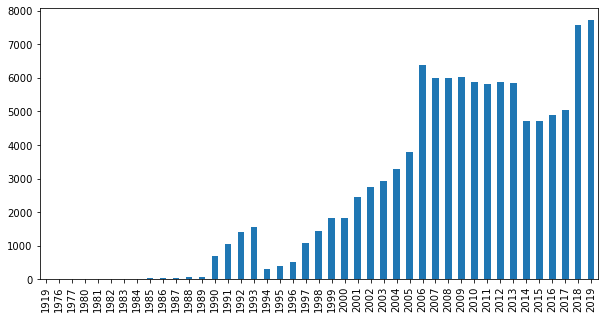

# Company starts to use invoice financial service

|  | status | reg | sic03 | sic07 | name | dis | liq | ftsea | ctype | ftset | acctype | date_begin | date_end | date_account | ptexpm | currat | snwc | gear | equi | creday | debday | liqtest | retcape | rettotass | curdbr | totdbr | sttor | retna | turnover | … |
| --- | --- | --- | --- | --- | --- | --- | --- | --- | --- | --- | --- | --- | --- | --- | --- | --- | --- | --- | --- | --- | --- | --- | --- | --- | --- | --- | --- | --- | --- | --- |
| 68134 | User | 09041435 | 7420.0000 | 71129.0000 | MILMIT LIMITED | D | NaN | NaN | 2 | nan | 9 | 2014-06-01 | 2015-05-31 | 2014-08-04 | nan | 0.3800 | nan | -151.8000 | -29.3000 | nan | nan | 0.3700 | nan | nan | -2.8900 | -4.4100 | nan | nan | nan | … |
| 68139 | User | 07204579 | 5142.0000 | 46420.0000 | BATES FOOTWEAR LIMITED | D | NaN | NaN | 2 | nan | 9 | 2013-04-01 | 2014-03-31 | 2013-06-26 | nan | 0.7800 | nan | 0.0000 | -27.0000 | nan | nan | 0.1900 | nan | nan | -4.7000 | -4.7000 | nan | nan | nan | … |
| 68140 | User | 07053468 | 7420.0000 | 74909.0000 | ADRIAN PHILLIPS PROJECTS LTD | D | NaN | NaN | 2 | nan | 9 | 2015-01-01 | 2015-12-31 | 2015-02-10 | nan | 0.8900 | nan | -1.3000 | -2.3000 | nan | nan | 0.4300 | nan | nan | -46.0500 | -46.0700 | nan | nan | nan | … |
| 68141 | User | 07578057 | 7420.0000 | 71129.0000 | HPP PROCESS SYSTEMS LIMITED | D | NaN | NaN | 2 | nan | 9 | 2014-06-01 | 2015-05-31 | 2014-08-27 | nan | 0.9600 | nan | 85.3000 | 1.8000 | nan | nan | 0.7800 | nan | nan | 55.1100 | 55.9700 | nan | nan | nan | … |
| 68142 | User | 08791442 | 8532.0000 | 88100.0000 | G & AF COMMUNITY SERVICES LTD | D | NaN | NaN | 2 | nan | 9 | 2013-12-01 | 2014-11-30 | 2014-06-10 | nan | 0.9700 | nan | 0.0000 | -3.5000 | nan | nan | 0.9600 | nan | nan | -29.7300 | -29.7300 | nan | nan | nan | … |

```
(14057, 87)
```

## Yearly analysis

Lowest year: 2012 in raw data:

- https://eu-west-2.console.aws.amazon.com/athena/home?region=eu-west-2#query/history/4bca6eb2-88a7-4348-b47f-5fa3263467ce

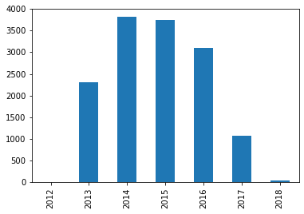

|  | full_sample | sample | pct_sample |
| --- | --- | --- | --- |
| 2012 | 5862 | 2.000000 | 0.03% |
| 2013 | 5831 | 2302.000000 | 39.48% |
| 2014 | 4720 | 3815.000000 | 80.83% |
| 2015 | 4710 | 3737.000000 | 79.34% |
| 2016 | 4902 | 3093.000000 | 63.10% |
| 2017 | 5027 | 1070.000000 | 21.29% |
| 2018 | 7565 | 38.000000 | 0.50% |

## Monthly analysis

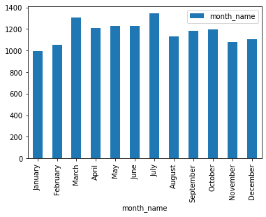

# Mapping Invoice Finance User

## df_user analysis

In our project, the dependent variable is a binary one(status=User(14057), Or not_user(981819)), as our response variable also.

- Feature selection [catalog](https://docs.google.com/spreadsheets/d/1QyFScrHPm5W2dBLYBdOlzwF97UV1NR4Shz0D6Z-csdQ/edit#gid=1686780864)

### Missing values

|  | index | count_na | percentage |
| --- | --- | --- | --- |
| 0 | ftset | 14057 | 100.00% |
| 1 | ftsea | 13880 | 98.74% |
| 2 | net_cashflow_from_fin | 13294 | 94.57% |
| 3 | increase_in_cash | 13294 | 94.57% |
| 4 | net_cashflow_from_op | 13294 | 94.57% |
| 5 | export | 13023 | 92.64% |
| 6 | sttor | 12872 | 91.57% |
| 7 | liq | 12530 | 89.14% |
| 8 | wages | 12435 | 88.46% |
| 9 | creday | 12351 | 87.86% |
| 10 | debday | 12322 | 87.66% |
| 11 | director_emoluments | 12293 | 87.45% |
| 12 | cost_of_sale | 12278 | 87.34% |
| 13 | gross_profit | 12259 | 87.21% |
| 14 | ptexpm | 12169 | 86.57% |
| 15 | op_profit | 12135 | 86.33% |
| 16 | rettotass | 12036 | 85.62% |
| 17 | retna | 12033 | 85.60% |
| 18 | retcape | 12031 | 85.59% |
| 19 | snwc | 11992 | 85.31% |
| 20 | turnover | 11973 | 85.17% |
| 21 | dividend | 11960 | 85.08% |
| 22 | pretax_profit | 11960 | 85.08% |
| 23 | profit_after_tax | 11959 | 85.08% |
| 24 | taxation | 11959 | 85.08% |
| 25 | retained_profit | 11959 | 85.08% |
| 26 | interest_payment | 11951 | 85.02% |
| 27 | nb_employees | 10264 | 73.02% |
| 28 | depreciation | 1343 | 9.55% |
| 29 | liqtest | 923 | 6.57% |

[output cut: 57 more lines]

## Categorical analysis

- 2.1 industry_desc
- 2.2 company_type_desc
- 2.3 dissolved_desc
- 2.4 ftsea_desc
- 2.5 ftset_des
- 2.6 company_accunts

### 2.1 industry information

**10.7% companys are in labour recrument industy**

Top 10 industries with the highest users

|  | index | industry_desc | percentage |
| --- | --- | --- | --- |
| 0 | LABOUR RECRUITMENT | 1489 | 10.73% |
| 1 | OTHER BUSINESS ACTIVITIES | 844 | 6.08% |
| 2 | FREIGHT TRANSPORT BY ROAD | 491 | 3.54% |
| 3 | DEVELOPMENT & SELL REAL ESTATE | 427 | 3.08% |
| 4 | GENERAL CONSTRUCTION & CIVIL ENGINEERING | 374 | 2.70% |
| 5 | OTHER SPECIAL TRADES CONSTRUCTION | 372 | 2.68% |
| 6 | HOLDING COMPANIES INCLUDING HEAD OFFICES | 348 | 2.51% |
| 7 | ARCHITECTURAL, TECHNICAL CONSULT | 343 | 2.47% |
| 8 | OTHER SERVICE ACTIVITIES | 320 | 2.31% |
| 9 | OTHER MANUFACTURING | 245 | 1.77% |

### 2.2 company type information

**Almost all(98.24%) of the company are private and limited with share capital**

|  | index | company_type_desc | percentage |
| --- | --- | --- | --- |
| 0 | Private limited with Share Capital | 13809 | 98.24% |
| 1 | Other | 177 | 1.26% |
| 2 | Public limited with Share Capital | 38 | 0.27% |
| 3 | Private Limited By Guarantee without Share Capital | 25 | 0.18% |
| 4 | Private Limited by guarantee without Share Capital Exempt from using "Limited" | 7 | 0.05% |
| 5 | Private unlimited with Share Capital | 1 | 0.01% |

### 2.3 Dissolved information

**Most companies(83.72%) in our dataset are still alive**

|  | index | dissolved_desc | percentage |
| --- | --- | --- | --- |
| 0 | Live | 11769 | 83.72% |
| 1 | Dissolved | 2288 | 16.28% |

### 2.4 FTSEA information

**Almost all of our User company are not in the stock exchange market**

Most of them are NaN

```
NaN    13880
         177
Name: ftsea, dtype: int64
```

```
nan    14057
Name: ftset, dtype: int64
```

```
Not FTSE    13880
NaN           177
Name: ftsea_desc, dtype: int64
```

```
Not FTSET    14057
Name: ftset_desc, dtype: int64
```

Almost all of our User company are not in the stock exchange market, which makes sense, because they are SMEs, related to our information before. They are not big enough to go public.

### 2.5 company_accounts information

**the top 3 company type are related to small company type information**

**Definition**

- Total Exemption Full - this term refers to medium or small business' filing full accounts.
- A micro-entity is a very small company or LLP. Micro-entities may be able to produce a much simpler set of year end accounts for their members and provide less information for the public record
- Total Exemption Small - this term refers to medium or small companies that file only the abbreviated accounts at companies house.

**Insight**

According to our understanding, the top 3 company type are related to small company type information. Total Exemption full 44.71, micro-entity accounts 17.85, total exemption small 12.7, so, in total, we have 75.26% companies accounts related to small company type

|  | index | company_accounts_desc | percentage |
| --- | --- | --- | --- |
| 0 | Total Exemption Full | 6286 | 44.72% |
| 1 | Micro-Entity Accounts | 2511 | 17.86% |
| 2 | Total Exemption Small | 1790 | 12.73% |
| 3 | Unaudited Abridged | 941 | 6.69% |
| 4 | Full Accounts | 936 | 6.66% |
| 5 | Small Company | 732 | 5.21% |
| 6 | Dormant | 472 | 3.36% |
| 7 | Group | 269 | 1.91% |
| 8 | Audit Exemption Subsidiary | 105 | 0.75% |
| 9 | Audited Abridged | 9 | 0.06% |
| 10 | Medium Company | 5 | 0.04% |
| 11 | Partial Exemption | 1 | 0.01% |

## Continuous variables analysis

For deeper understanding of the variables, please refer to this document made by [Credit Safe](https://help.creditsafeuk.com/en/support/solutions/articles/7000030843-do-you-have-a-glossary-of-terms-)

- 3.1 currat: Total Current Assets / Total Current Liabilities
- 3.2 gear: Bank Overdraft and Loans plus Total Long Term Liabilities/Shareholders funds x 100
- 3.3 equi: Shareholder Funds / (Total Current Assets + Tangible Fixed Assets) x 100
- 3.4 liqtest: Current assets - Stocks/Current Liabilities
- 3.5 cudbr: Total Current Liabilities / Shareholders Funds
- 3.6 totdbr: Total Short Term & Long Term Debt / Shareholder Funds

### 3.1 currat

Total Current Assets / Total Current Liabilities. This is an indication of a company's ability to meet short-term debt obligations, the higher the ratio, the more liquid the company is.

```
count   13301.0000
mean       10.3079
std       544.0765
min         0.0000
25%         0.7700
50%         1.0200
75%         1.3400
max     50365.0000
Name: currat, dtype: float64
```

| industry_desc | percentage | count | mean | std | min | 25% | 35% | 50% | 75% | 80% | 90% | max |
| --- | --- | --- | --- | --- | --- | --- | --- | --- | --- | --- | --- | --- |
| LABOUR RECRUITMENT | 0.11 | 1,395.00 | 1.37 | 2.07 | 0.00 | 0.89 | 0.98 | 1.03 | 1.34 | 1.51 | 2.17 | 44.98 |
| OTHER BUSINESS ACTIVITIES | 0.06 | 794.00 | 6.17 | 95.64 | 0.00 | 0.77 | 0.92 | 1.02 | 1.32 | 1.51 | 2.22 | 2,528.32 |
| FREIGHT TRANSPORT BY ROAD | 0.04 | 467.00 | 1.22 | 2.92 | 0.00 | 0.66 | 0.79 | 0.92 | 1.13 | 1.20 | 1.61 | 52.49 |
| DEVELOPMENT & SELL REAL ESTATE | 0.03 | 405.00 | 99.59 | 1,764.07 | 0.00 | 0.93 | 0.98 | 1.03 | 1.70 | 2.09 | 6.20 | 35,483.00 |
| GENERAL CONSTRUCTION & CIVIL ENGINEERING | 0.03 | 364.00 | 5.64 | 35.64 | 0.00 | 0.92 | 0.98 | 1.05 | 1.37 | 1.45 | 2.17 | 482.56 |
| OTHER SPECIAL TRADES CONSTRUCTION | 0.03 | 363.00 | 1.15 | 1.30 | 0.00 | 0.77 | 0.90 | 1.00 | 1.30 | 1.38 | 1.57 | 21.17 |
| HOLDING COMPANIES INCLUDING HEAD OFFICES | 0.03 | 304.00 | 202.84 | 2,943.03 | 0.00 | 0.02 | 0.32 | 0.85 | 1.23 | 1.35 | 1.90 | 50,365.00 |
| ARCHITECTURAL, TECHNICAL CONSULT | 0.02 | 336.00 | 1.17 | 0.83 | 0.00 | 0.80 | 0.92 | 1.02 | 1.31 | 1.42 | 1.83 | 8.42 |
| OTHER SERVICE ACTIVITIES | 0.02 | 301.00 | 1.33 | 3.11 | 0.00 | 0.73 | 0.90 | 0.98 | 1.21 | 1.30 | 1.66 | 49.67 |
| OTHER MANUFACTURING | 0.02 | 236.00 | 1.50 | 3.83 | 0.00 | 0.86 | 0.94 | 1.06 | 1.48 | 1.61 | 2.13 | 58.67 |

| company_accounts_desc | percentage | count | mean | std | min | 25% | 35% | 50% | 75% | 80% | 90% | max |
| --- | --- | --- | --- | --- | --- | --- | --- | --- | --- | --- | --- | --- |
| Total Exemption Full | 0.45 | 6,157.00 | 3.11 | 49.46 | 0.00 | 0.83 | 0.95 | 1.03 | 1.35 | 1.49 | 2.01 | 2,528.32 |
| Micro-Entity Accounts | 0.18 | 2,356.00 | 2.94 | 41.21 | 0.00 | 0.64 | 0.82 | 0.98 | 1.28 | 1.44 | 2.06 | 1,715.55 |
| Total Exemption Small | 0.13 | 1,730.00 | 33.15 | 1,216.02 | 0.00 | 0.66 | 0.81 | 0.95 | 1.14 | 1.21 | 1.63 | 50,365.00 |
| Unaudited Abridged | 0.07 | 922.00 | 42.00 | 1,168.96 | 0.00 | 0.82 | 0.94 | 1.03 | 1.35 | 1.51 | 2.14 | 35,483.00 |
| Full Accounts | 0.07 | 902.00 | 2.04 | 9.53 | 0.00 | 0.87 | 1.00 | 1.14 | 1.53 | 1.71 | 2.23 | 225.48 |
| Small Company | 0.05 | 713.00 | 16.09 | 374.47 | 0.00 | 0.86 | 1.00 | 1.11 | 1.61 | 1.83 | 2.66 | 10,000.00 |
| Dormant | 0.03 | 137.00 | 1.61 | 2.71 | 0.00 | 0.21 | 0.55 | 0.98 | 1.64 | 1.98 | 3.03 | 15.48 |
| Group | 0.02 | 269.00 | 1.27 | 1.06 | 0.05 | 0.89 | 0.95 | 1.08 | 1.40 | 1.50 | 1.82 | 14.73 |
| Audit Exemption Subsidiary | 0.01 | 100.00 | 11.09 | 67.88 | 0.00 | 0.83 | 0.92 | 1.00 | 1.52 | 1.71 | 2.45 | 621.86 |
| Audited Abridged | 0.00 | 9.00 | 1.24 | 0.51 | 0.44 | 1.02 | 1.08 | 1.11 | 1.46 | 1.52 | 1.75 | 2.28 |

### 3.2 gear

**more than half of companies gear value is 0**

Bank Overdraft and Loans plus Total Long Term Liabilities/Shareholders funds x 100. This is the relationship between the size of the company’s debt in proportion to Equity (Shareholders Funds)

From the results below, there are more than half of companies gear value is 0 ->Does it means half of them do not have debt?

```
count       13585.0000
mean       168431.0623
std       7561799.5682
min      -3625877.8000
25%             0.0000
50%             0.0000
55%             1.5000
60%             7.2000
75%            66.6000
80%           109.8400
max     560000000.0000
Name: gear, dtype: float64
```

| industry_desc | percentage | count | mean | std | min | 25% | 35% | 50% | 75% | 80% | 90% | max |
| --- | --- | --- | --- | --- | --- | --- | --- | --- | --- | --- | --- | --- |
| LABOUR RECRUITMENT | 0.11 | 1,437.00 | 601.79 | 10,934.39 | -8,678.70 | 0.00 | 0.00 | 0.00 | 1.10 | 5.10 | 97.52 | 391,834.00 |
| OTHER BUSINESS ACTIVITIES | 0.06 | 812.00 | 176,509.63 | 4,859,394.23 | -858,057.10 | 0.00 | 0.00 | 0.00 | 36.38 | 76.48 | 259.19 | 138,408,944.00 |
| FREIGHT TRANSPORT BY ROAD | 0.04 | 482.00 | 683.28 | 4,035.35 | -8,016.90 | 0.00 | 0.00 | 0.60 | 165.35 | 271.74 | 736.43 | 58,207.00 |
| DEVELOPMENT & SELL REAL ESTATE | 0.03 | 411.00 | 461,019.82 | 6,154,439.51 | -3,625,877.80 | -125.90 | 0.00 | 0.00 | 28.50 | 109.40 | 853.10 | 92,049,600.00 |
| GENERAL CONSTRUCTION & CIVIL ENGINEERING | 0.03 | 367.00 | 646,901.40 | 9,505,760.76 | -96,199.20 | 0.00 | 0.00 | 0.50 | 92.70 | 164.44 | 375.12 | 173,709,904.00 |
| OTHER SPECIAL TRADES CONSTRUCTION | 0.03 | 366.00 | 2,097.92 | 32,447.44 | -1,271.00 | 0.00 | 0.00 | 2.95 | 76.47 | 113.60 | 330.35 | 618,200.00 |
| HOLDING COMPANIES INCLUDING HEAD OFFICES | 0.03 | 327.00 | 532,277.33 | 9,343,027.64 | -32,084.90 | 0.00 | 0.00 | 4.90 | 122.75 | 186.08 | 793.30 | 168,950,400.00 |
| ARCHITECTURAL, TECHNICAL CONSULT | 0.02 | 339.00 | 375.22 | 5,067.06 | -44,816.70 | 0.00 | 0.00 | 0.00 | 88.65 | 124.46 | 370.78 | 75,256.00 |
| OTHER SERVICE ACTIVITIES | 0.02 | 307.00 | 253.78 | 7,617.97 | -86,496.70 | 0.00 | 0.00 | 0.00 | 68.10 | 121.58 | 395.06 | 96,156.90 |
| OTHER MANUFACTURING | 0.02 | 240.00 | 590.73 | 4,518.42 | -8,199.00 | 0.00 | 0.76 | 13.05 | 83.42 | 116.14 | 421.18 | 48,133.70 |

| company_accounts_desc | percentage | count | mean | std | min | 25% | 35% | 50% | 75% | 80% | 90% | max |
| --- | --- | --- | --- | --- | --- | --- | --- | --- | --- | --- | --- | --- |
| Total Exemption Full | 0.45 | 6,217.00 | 66,363.87 | 2,859,882.46 | -858,057.10 | 0.00 | 0.00 | 1.80 | 93.80 | 151.30 | 484.14 | 173,709,904.00 |
| Micro-Entity Accounts | 0.18 | 2,480.00 | 97,336.16 | 3,265,237.24 | -3,073,800.00 | 0.00 | 0.00 | 0.00 | 11.30 | 40.44 | 323.57 | 138,408,944.00 |
| Total Exemption Small | 0.13 | 1,765.00 | 3,059.31 | 76,096.88 | -68,771.10 | 0.00 | 0.00 | 0.00 | 13.30 | 40.30 | 211.14 | 2,905,901.00 |
| Unaudited Abridged | 0.07 | 930.00 | 60,671.24 | 1,810,388.55 | -3,625,877.80 | 0.00 | 0.00 | 0.40 | 70.42 | 112.82 | 338.21 | 55,000,000.00 |
| Full Accounts | 0.07 | 914.00 | 6,957.98 | 139,440.70 | -11,760.40 | 0.00 | 1.90 | 18.00 | 95.00 | 118.50 | 294.69 | 4,005,441.00 |
| Small Company | 0.05 | 722.00 | 612,786.05 | 9,800,797.01 | -284,677.80 | 0.00 | 0.00 | 0.95 | 54.60 | 92.76 | 271.28 | 180,300,304.00 |
| Dormant | 0.03 | 169.00 | 6,648,602.37 | 60,736,255.78 | -754.70 | 0.00 | 0.00 | 0.00 | 3.40 | 22.40 | 149.10 | 560,000,000.00 |
| Group | 0.02 | 269.00 | -43.66 | 2,177.28 | -32,084.90 | 9.30 | 30.60 | 66.50 | 194.90 | 251.92 | 675.80 | 4,660.40 |
| Audit Exemption Subsidiary | 0.01 | 104.00 | -480.57 | 4,235.73 | -42,832.30 | -0.33 | 0.00 | 0.00 | 7.95 | 20.12 | 147.07 | 3,328.40 |
| Audited Abridged | 0.00 | 9.00 | 44.67 | 70.47 | 0.00 | 0.00 | 2.88 | 9.20 | 64.30 | 80.38 | 124.74 | 205.70 |

### 3.3 equi

Shareholder Funds / (Total Current Assets + Tangible Fixed Assets) x 100. This ratio shows the worth of the company (shareholders funds) as a percentage of total current and tangible assets.

How can it be negative?

```
count        13571.0000
mean        -18738.5731
std        2079466.7373
min     -242136432.0000
25%             -0.4000
50%              9.4000
55%             12.6000
60%             16.2000
75%             30.3000
80%             36.3000
max           1609.4000
Name: equi, dtype: float64
```

| industry_desc | percentage | count | mean | std | min | 25% | 35% | 50% | 75% | 80% | 90% | max |
| --- | --- | --- | --- | --- | --- | --- | --- | --- | --- | --- | --- | --- |
| LABOUR RECRUITMENT | 0.11 | 1,432.00 | -371.66 | 7,044.51 | -194,442.90 | -2.80 | 0.60 | 6.10 | 27.72 | 34.90 | 55.29 | 299.90 |
| OTHER BUSINESS ACTIVITIES | 0.06 | 812.00 | -8,842.12 | 249,602.81 | -7,112,600.00 | -5.20 | 0.38 | 7.00 | 27.92 | 32.40 | 53.54 | 224.20 |
| FREIGHT TRANSPORT BY ROAD | 0.04 | 478.00 | -9.98 | 136.42 | -1,939.20 | -2.10 | 0.99 | 6.45 | 21.55 | 26.56 | 41.26 | 100.00 |
| DEVELOPMENT & SELL REAL ESTATE | 0.03 | 412.00 | -1,942.68 | 39,043.53 | -792,500.00 | -3.95 | -1.02 | 0.00 | 14.65 | 20.78 | 36.70 | 100.00 |
| GENERAL CONSTRUCTION & CIVIL ENGINEERING | 0.03 | 362.00 | -1.32 | 113.38 | -1,649.10 | -0.08 | 1.03 | 7.80 | 24.35 | 30.68 | 42.71 | 100.00 |
| OTHER SPECIAL TRADES CONSTRUCTION | 0.03 | 367.00 | -3.78 | 110.66 | -1,568.00 | 0.30 | 3.93 | 11.20 | 29.65 | 33.64 | 41.74 | 100.80 |
| HOLDING COMPANIES INCLUDING HEAD OFFICES | 0.03 | 327.00 | -48.31 | 835.28 | -12,650.00 | 1.25 | 7.81 | 19.10 | 50.50 | 58.00 | 96.38 | 107.40 |
| ARCHITECTURAL, TECHNICAL CONSULT | 0.02 | 339.00 | -41.73 | 674.15 | -12,251.70 | 0.10 | 2.56 | 10.20 | 27.20 | 31.92 | 49.22 | 116.40 |
| OTHER SERVICE ACTIVITIES | 0.02 | 306.00 | -3,964.75 | 68,362.24 | -1,195,850.00 | -1.75 | 1.10 | 7.45 | 30.65 | 34.10 | 50.40 | 270.40 |
| OTHER MANUFACTURING | 0.02 | 239.00 | 7.04 | 91.54 | -823.20 | 1.15 | 7.54 | 18.40 | 38.95 | 44.28 | 61.08 | 113.90 |

| company_accounts_desc | percentage | count | mean | std | min | 25% | 35% | 50% | 75% | 80% | 90% | max |
| --- | --- | --- | --- | --- | --- | --- | --- | --- | --- | --- | --- | --- |
| Total Exemption Full | 0.45 | 6,227.00 | -222.17 | 15,199.68 | -1,195,850.00 | 0.10 | 2.50 | 10.60 | 29.45 | 34.88 | 50.30 | 1,103.70 |
| Micro-Entity Accounts | 0.18 | 2,470.00 | -3,542.62 | 144,116.45 | -7,112,600.00 | -8.47 | 0.10 | 4.10 | 26.58 | 34.20 | 56.52 | 704.20 |
| Total Exemption Small | 0.13 | 1,755.00 | -138,298.86 | 5,779,915.29 | -242,136,432.00 | -19.35 | -2.61 | 1.50 | 16.50 | 22.30 | 41.40 | 224.20 |
| Unaudited Abridged | 0.07 | 930.00 | 4.39 | 77.32 | -1,192.50 | 0.10 | 2.11 | 9.65 | 29.98 | 35.54 | 52.01 | 339.70 |
| Full Accounts | 0.07 | 914.00 | -9.51 | 714.27 | -17,287.60 | 7.50 | 15.00 | 24.85 | 44.38 | 49.84 | 64.92 | 1,609.40 |
| Small Company | 0.05 | 720.00 | -88.29 | 2,097.52 | -55,532.70 | 0.20 | 4.30 | 17.65 | 41.23 | 47.64 | 65.38 | 126.30 |
| Dormant | 0.03 | 166.00 | -8,322.19 | 76,500.32 | -962,133.30 | -19.25 | 0.10 | 16.15 | 59.15 | 78.80 | 100.00 | 100.00 |
| Group | 0.02 | 269.00 | 17.51 | 64.59 | -790.50 | 7.10 | 12.84 | 21.00 | 37.30 | 41.60 | 53.34 | 145.60 |
| Audit Exemption Subsidiary | 0.01 | 105.00 | -71.29 | 929.95 | -9,500.00 | -3.80 | 0.00 | 15.00 | 43.60 | 51.20 | 86.24 | 109.10 |
| Audited Abridged | 0.00 | 9.00 | 16.43 | 44.94 | -94.00 | 13.50 | 16.78 | 34.00 | 40.40 | 40.52 | 44.66 | 60.50 |

According to our results above,13571 companies has this information.

### 3.4 liqtest

Current assets - Stocks/Current Liabilities. This, like the current ratio, measures how quickly in the short term a company can meet its debts. However, this ratio excludes stock as there is no guarantee the value of Stocks can be realized quickly

```
count   13134.0000
mean        6.4347
std       449.5156
min         0.0000
25%         0.5500
50%         0.9000
55%         0.9500
60%         0.9900
75%         1.1700
80%         1.2900
max     50365.0000
Name: liqtest, dtype: float64
```

| industry_desc | percentage | count | mean | std | min | 25% | 35% | 50% | 75% | 80% | 90% | max |
| --- | --- | --- | --- | --- | --- | --- | --- | --- | --- | --- | --- | --- |
| LABOUR RECRUITMENT | 0.11 | 1,384.00 | 1.37 | 2.07 | 0.00 | 0.88 | 0.97 | 1.03 | 1.34 | 1.50 | 2.17 | 44.97 |
| OTHER BUSINESS ACTIVITIES | 0.06 | 784.00 | 2.58 | 32.96 | 0.00 | 0.58 | 0.74 | 0.94 | 1.19 | 1.32 | 1.93 | 917.83 |
| FREIGHT TRANSPORT BY ROAD | 0.04 | 464.00 | 1.21 | 2.93 | 0.00 | 0.64 | 0.77 | 0.91 | 1.11 | 1.20 | 1.61 | 52.48 |
| DEVELOPMENT & SELL REAL ESTATE | 0.03 | 389.00 | 11.22 | 194.57 | 0.00 | 0.03 | 0.07 | 0.24 | 0.99 | 1.16 | 1.99 | 3,836.50 |
| GENERAL CONSTRUCTION & CIVIL ENGINEERING | 0.03 | 357.00 | 1.08 | 2.50 | 0.00 | 0.34 | 0.58 | 0.85 | 1.12 | 1.22 | 1.63 | 37.70 |
| OTHER SPECIAL TRADES CONSTRUCTION | 0.03 | 362.00 | 1.04 | 1.29 | 0.00 | 0.61 | 0.76 | 0.93 | 1.17 | 1.26 | 1.51 | 21.16 |
| HOLDING COMPANIES INCLUDING HEAD OFFICES | 0.03 | 273.00 | 225.74 | 3,105.39 | 0.00 | 0.18 | 0.55 | 0.77 | 1.07 | 1.15 | 1.81 | 50,365.00 |
| ARCHITECTURAL, TECHNICAL CONSULT | 0.02 | 335.00 | 1.07 | 0.80 | 0.00 | 0.68 | 0.79 | 0.96 | 1.24 | 1.30 | 1.76 | 7.19 |
| OTHER SERVICE ACTIVITIES | 0.02 | 295.00 | 1.18 | 3.11 | 0.00 | 0.61 | 0.73 | 0.90 | 1.08 | 1.15 | 1.51 | 49.67 |
| OTHER MANUFACTURING | 0.02 | 235.00 | 1.24 | 3.84 | 0.00 | 0.60 | 0.71 | 0.85 | 1.16 | 1.35 | 1.79 | 58.66 |

| company_accounts_desc | percentage | count | mean | std | min | 25% | 35% | 50% | 75% | 80% | 90% | max |
| --- | --- | --- | --- | --- | --- | --- | --- | --- | --- | --- | --- | --- |
| Total Exemption Full | 0.45 | 6,102.00 | 1.57 | 18.31 | 0.00 | 0.57 | 0.72 | 0.90 | 1.17 | 1.27 | 1.71 | 917.83 |
| Micro-Entity Accounts | 0.18 | 2,312.00 | 1.57 | 10.34 | 0.00 | 0.48 | 0.68 | 0.91 | 1.21 | 1.36 | 1.92 | 443.28 |
| Total Exemption Small | 0.13 | 1,708.00 | 30.50 | 1,218.64 | 0.00 | 0.48 | 0.63 | 0.80 | 1.03 | 1.10 | 1.40 | 50,365.00 |
| Unaudited Abridged | 0.07 | 916.00 | 5.49 | 126.80 | 0.00 | 0.56 | 0.71 | 0.91 | 1.21 | 1.31 | 1.82 | 3,836.50 |
| Full Accounts | 0.07 | 882.00 | 1.72 | 9.04 | 0.00 | 0.65 | 0.77 | 0.95 | 1.30 | 1.45 | 1.88 | 225.48 |
| Small Company | 0.05 | 704.00 | 15.73 | 376.85 | 0.00 | 0.55 | 0.74 | 0.97 | 1.32 | 1.46 | 2.20 | 10,000.00 |
| Dormant | 0.03 | 129.00 | 1.61 | 2.76 | 0.00 | 0.27 | 0.55 | 0.88 | 1.53 | 1.85 | 2.65 | 15.48 |
| Group | 0.02 | 269.00 | 0.97 | 0.97 | 0.02 | 0.64 | 0.72 | 0.85 | 1.08 | 1.12 | 1.33 | 14.73 |
| Audit Exemption Subsidiary | 0.01 | 97.00 | 11.29 | 68.92 | 0.00 | 0.68 | 0.84 | 0.98 | 1.24 | 1.55 | 2.75 | 621.85 |
| Audited Abridged | 0.00 | 9.00 | 0.98 | 0.36 | 0.29 | 0.83 | 0.87 | 1.01 | 1.08 | 1.16 | 1.35 | 1.61 |

### 3.5 curdbr

**60% companies have more liabilities than shareholder funds**

Total Current Liabilities / Shareholders Funds. This measures the amount of short term debt in relation to the value of shareholders funds

The bigger the curdbr is, the more liabilities of this company has, the less the shareholder funds of this company has. there are around 40% companies curdbr value is less than 1, it means, 60% companies have more liabilities than shareholder funds, the financial situation is not very well for these companies.

How can it be negative?

```
count     13278.0000
mean       2150.4871
std       93402.4478
min     -152559.0500
25%          -0.8000
40%           1.0700
50%           1.9500
55%           2.5135
60%           3.3000
75%           8.1200
80%          12.1420
max     9568183.0000
Name: curdbr, dtype: float64
```

| industry_desc | percentage | count | mean | std | min | 25% | 35% | 50% | 75% | 80% | 90% | max |
| --- | --- | --- | --- | --- | --- | --- | --- | --- | --- | --- | --- | --- |
| LABOUR RECRUITMENT | 0.11 | 1,394.00 | 222.98 | 3,646.79 | -4,631.15 | -1.01 | 0.70 | 2.24 | 13.30 | 21.88 | 98.53 | 131,280.00 |
| OTHER BUSINESS ACTIVITIES | 0.06 | 793.00 | 217.84 | 3,262.55 | -4,886.66 | -1.25 | 0.41 | 1.87 | 7.70 | 11.51 | 59.43 | 85,470.55 |
| FREIGHT TRANSPORT BY ROAD | 0.04 | 467.00 | 45.30 | 282.24 | -288.13 | -1.00 | 1.06 | 2.63 | 10.36 | 14.02 | 44.75 | 4,290.00 |
| DEVELOPMENT & SELL REAL ESTATE | 0.03 | 404.00 | 10,974.63 | 150,248.93 | -152,559.05 | -15.65 | -6.79 | 0.05 | 4.81 | 8.60 | 65.44 | 2,968,078.00 |
| GENERAL CONSTRUCTION & CIVIL ENGINEERING | 0.03 | 364.00 | 6,642.70 | 117,497.85 | -19,951.11 | -1.00 | 0.93 | 2.38 | 9.30 | 13.34 | 64.31 | 2,239,451.00 |
| OTHER SPECIAL TRADES CONSTRUCTION | 0.03 | 362.00 | 234.72 | 2,674.66 | -105.46 | 0.57 | 1.47 | 2.46 | 8.65 | 10.59 | 48.59 | 48,828.00 |
| HOLDING COMPANIES INCLUDING HEAD OFFICES | 0.03 | 303.00 | 40,915.57 | 556,398.31 | -521.19 | 0.08 | 0.63 | 1.45 | 5.67 | 7.85 | 30.46 | 9,568,183.00 |
| ARCHITECTURAL, TECHNICAL CONSULT | 0.02 | 336.00 | 31.13 | 220.78 | -2,125.54 | 0.27 | 0.98 | 2.37 | 8.96 | 12.61 | 39.59 | 1,861.77 |
| OTHER SERVICE ACTIVITIES | 0.02 | 301.00 | 134.38 | 1,033.09 | -213.97 | -1.07 | 0.81 | 2.09 | 10.14 | 13.95 | 56.82 | 11,425.41 |
| OTHER MANUFACTURING | 0.02 | 236.00 | 16.37 | 87.46 | -199.00 | 0.42 | 0.90 | 1.79 | 5.64 | 6.95 | 24.71 | 930.10 |

| company_accounts_desc | percentage | count | mean | std | min | 25% | 35% | 50% | 75% | 80% | 90% | max |
| --- | --- | --- | --- | --- | --- | --- | --- | --- | --- | --- | --- | --- |
| Total Exemption Full | 0.45 | 6,143.00 | 1,137.57 | 42,307.89 | -152,559.05 | 0.19 | 0.98 | 2.28 | 8.60 | 12.63 | 48.65 | 2,239,451.00 |
| Micro-Entity Accounts | 0.18 | 2,355.00 | 1,458.62 | 33,209.07 | -42,566.00 | -1.47 | 0.12 | 1.56 | 9.12 | 16.25 | 76.62 | 1,250,000.00 |
| Total Exemption Small | 0.13 | 1,727.00 | 665.97 | 13,809.85 | -22,185.09 | -2.42 | -1.05 | 1.57 | 10.18 | 17.97 | 82.59 | 434,667.00 |
| Unaudited Abridged | 0.07 | 921.00 | 642.64 | 12,855.74 | -19,951.11 | 0.18 | 0.87 | 2.17 | 9.35 | 13.48 | 53.72 | 363,337.00 |
| Full Accounts | 0.07 | 900.00 | 11,821.71 | 319,306.10 | -1,848.60 | 0.66 | 1.05 | 1.85 | 4.39 | 5.76 | 14.29 | 9,568,183.00 |
| Small Company | 0.05 | 712.00 | 5,464.72 | 113,300.44 | -799.33 | 0.04 | 0.55 | 1.35 | 4.69 | 6.46 | 24.60 | 2,968,078.00 |
| Dormant | 0.03 | 137.00 | 8,994.05 | 58,752.08 | -178.36 | -1.02 | -0.18 | 0.76 | 4.04 | 5.83 | 40.71 | 472,214.00 |
| Group | 0.02 | 269.00 | 3.53 | 36.70 | -521.19 | 0.93 | 1.32 | 2.22 | 5.11 | 6.91 | 13.29 | 196.48 |
| Audit Exemption Subsidiary | 0.01 | 99.00 | 6,317.02 | 62,876.31 | -836.80 | -3.77 | -0.01 | 0.78 | 3.45 | 4.79 | 8.72 | 625,608.00 |
| Audited Abridged | 0.00 | 9.00 | 10.61 | 26.68 | -2.26 | 1.29 | 1.36 | 1.41 | 4.42 | 4.47 | 19.94 | 81.54 |

### 3.6 totdbr

**63% companies have more debt than shareholder funds**

Total Short Term & Long Term Debt / Shareholder Funds. This shows the relative indebtedness of a company in relation to the worth of the company

Like curdbr before, the higher the value is, there are more debt than shareholder funds. Around 37% companies have this value < 1. it means around 63% companies have more debt than shareholder funds. These companies are not in a good financial situation.

```
count     13378.0000
mean       3620.6663
std      125020.5314
min     -152559.0500
25%          -1.1600
37%           1.0600
50%           2.3400
55%           3.0300
60%           3.9600
75%           9.4175
80%          14.2200
max     9568183.0000
Name: totdbr, dtype: float64
```

| industry_desc | percentage | count | mean | std | min | 25% | 35% | 50% | 75% | 80% | 90% | max |
| --- | --- | --- | --- | --- | --- | --- | --- | --- | --- | --- | --- | --- |
| LABOUR RECRUITMENT | 0.11 | 1,407.00 | 226.06 | 3,632.55 | -4,631.15 | -1.16 | 0.75 | 2.40 | 13.77 | 22.72 | 105.10 | 131,280.00 |
| OTHER BUSINESS ACTIVITIES | 0.06 | 800.00 | 1,958.26 | 49,038.64 | -8,627.85 | -1.73 | 0.48 | 2.12 | 8.85 | 13.22 | 65.84 | 1,384,089.50 |
| FREIGHT TRANSPORT BY ROAD | 0.04 | 474.00 | 49.69 | 297.32 | -322.70 | -1.48 | 1.29 | 3.44 | 13.69 | 17.01 | 59.22 | 4,690.00 |
| DEVELOPMENT & SELL REAL ESTATE | 0.03 | 409.00 | 15,338.92 | 200,112.29 | -152,559.05 | -22.17 | -11.41 | 0.14 | 6.41 | 10.97 | 190.19 | 3,888,574.00 |
| GENERAL CONSTRUCTION & CIVIL ENGINEERING | 0.03 | 365.00 | 8,264.86 | 121,228.26 | -19,951.11 | -1.06 | 1.27 | 2.96 | 11.49 | 14.67 | 72.43 | 2,239,451.00 |
| OTHER SPECIAL TRADES CONSTRUCTION | 0.03 | 364.00 | 254.28 | 2,980.70 | -105.46 | 0.71 | 1.73 | 2.89 | 10.10 | 13.76 | 50.36 | 55,010.00 |
| HOLDING COMPANIES INCLUDING HEAD OFFICES | 0.03 | 308.00 | 45,901.91 | 562,124.66 | -842.04 | 0.11 | 0.95 | 2.09 | 8.44 | 12.51 | 49.83 | 9,568,183.00 |
| ARCHITECTURAL, TECHNICAL CONSULT | 0.02 | 338.00 | 31.56 | 239.32 | -2,573.71 | 0.32 | 1.15 | 2.86 | 10.96 | 15.76 | 48.04 | 2,028.79 |
| OTHER SERVICE ACTIVITIES | 0.02 | 302.00 | 135.73 | 1,038.14 | -1,020.67 | -1.25 | 0.97 | 2.24 | 11.30 | 17.97 | 56.52 | 11,486.55 |
| OTHER MANUFACTURING | 0.02 | 238.00 | 21.55 | 110.20 | -201.50 | 0.52 | 1.01 | 2.17 | 6.17 | 8.56 | 25.82 | 930.10 |

| company_accounts_desc | percentage | count | mean | std | min | 25% | 35% | 50% | 75% | 80% | 90% | max |
| --- | --- | --- | --- | --- | --- | --- | --- | --- | --- | --- | --- | --- |
| Total Exemption Full | 0.45 | 6,169.00 | 1,327.50 | 45,441.35 | -152,559.05 | 0.32 | 1.24 | 2.82 | 9.99 | 14.60 | 54.22 | 2,239,451.00 |
| Micro-Entity Accounts | 0.18 | 2,405.00 | 2,429.13 | 47,804.96 | -73,304.00 | -1.85 | 0.15 | 1.77 | 11.26 | 19.01 | 92.84 | 1,384,089.50 |
| Total Exemption Small | 0.13 | 1,739.00 | 692.04 | 13,796.76 | -22,185.09 | -2.75 | -1.30 | 1.85 | 11.94 | 20.64 | 88.33 | 434,667.00 |
| Unaudited Abridged | 0.07 | 925.00 | 1,222.46 | 23,226.30 | -36,317.58 | 0.22 | 1.07 | 2.66 | 10.75 | 14.80 | 70.77 | 589,167.00 |
| Full Accounts | 0.07 | 901.00 | 11,833.47 | 319,131.54 | -1,848.60 | 0.83 | 1.26 | 2.09 | 5.24 | 7.26 | 17.25 | 9,568,183.00 |
| Small Company | 0.05 | 713.00 | 11,662.52 | 184,047.53 | -3,350.10 | 0.06 | 0.67 | 1.60 | 5.15 | 8.23 | 29.87 | 3,888,574.00 |
| Dormant | 0.03 | 141.00 | 88,427.78 | 720,502.54 | -178.36 | -1.07 | -1.00 | 0.85 | 4.70 | 6.84 | 47.06 | 6,072,214.00 |
| Group | 0.02 | 269.00 | 2.64 | 56.46 | -842.04 | 1.30 | 1.78 | 2.95 | 6.90 | 8.96 | 17.90 | 211.15 |
| Audit Exemption Subsidiary | 0.01 | 101.00 | 6,191.07 | 62,250.74 | -836.80 | -4.08 | -1.01 | 0.71 | 3.74 | 4.94 | 8.62 | 625,608.00 |
| Audited Abridged | 0.00 | 9.00 | 11.05 | 26.93 | -2.26 | 1.45 | 1.47 | 1.93 | 4.68 | 5.36 | 21.63 | 82.58 |

### 3.9 Tangible assets and intangible assets

**Few companies has intangible assets**

```
count       14057.0000
mean       614083.0381
std       4606850.9440
min             0.0000
25%           817.0000
37%          4276.7200
50%         14625.0000
55%         22003.0000
60%         32323.8000
75%        126846.0000
80%        212885.4000
max     332604000.0000
Name: tang_assets, dtype: float64
```

```
count       14057.0000
mean        96983.7507
std       1287541.9929
min     -22451863.0000
3%              0.0000
25%             0.0000
37%             0.0000
50%             0.0000
55%             0.0000
60%             0.0000
75%             0.0000
80%             0.0000
max      67681000.0000
Name: intang_assets, dtype: float64
```

| industry_desc | percentage | count | mean | std | min | 25% | 35% | 50% | 75% | 80% | 90% | max |
| --- | --- | --- | --- | --- | --- | --- | --- | --- | --- | --- | --- | --- |
| LABOUR RECRUITMENT | 0.11 | 1,489.00 | 35,083.03 | 442,542.97 | 0.00 | 0.00 | 242.00 | 1,125.00 | 5,391.00 | 8,236.40 | 23,267.20 | 15,548,000.00 |
| OTHER BUSINESS ACTIVITIES | 0.06 | 844.00 | 277,434.72 | 1,789,436.13 | 0.00 | 733.75 | 2,472.30 | 8,723.50 | 65,283.75 | 118,102.80 | 334,855.60 | 39,930,982.00 |
| FREIGHT TRANSPORT BY ROAD | 0.04 | 491.00 | 579,804.31 | 4,589,804.88 | 0.00 | 2,921.00 | 9,524.50 | 34,094.00 | 193,399.50 | 257,648.00 | 805,257.00 | 91,482,000.00 |
| DEVELOPMENT & SELL REAL ESTATE | 0.03 | 427.00 | 508,028.90 | 2,213,316.69 | 0.00 | 0.00 | 0.00 | 0.00 | 38,665.50 | 85,971.60 | 884,679.40 | 23,853,720.00 |
| GENERAL CONSTRUCTION & CIVIL ENGINEERING | 0.03 | 374.00 | 238,180.80 | 713,389.46 | 0.00 | 277.50 | 4,111.85 | 17,153.00 | 117,501.25 | 196,370.60 | 572,771.20 | 7,033,000.00 |
| OTHER SPECIAL TRADES CONSTRUCTION | 0.03 | 372.00 | 321,236.72 | 1,826,812.34 | 0.00 | 4,327.25 | 11,310.70 | 26,836.00 | 155,986.50 | 220,515.00 | 550,431.90 | 32,078,387.00 |
| HOLDING COMPANIES INCLUDING HEAD OFFICES | 0.03 | 348.00 | 5,826,200.43 | 21,558,657.38 | 0.00 | 67,040.50 | 222,327.00 | 729,178.50 | 2,979,624.00 | 4,016,521.20 | 11,823,669.10 | 332,604,000.00 |
| ARCHITECTURAL, TECHNICAL CONSULT | 0.02 | 343.00 | 239,966.80 | 1,662,646.72 | 0.00 | 1,401.00 | 4,118.30 | 15,081.00 | 80,091.00 | 133,737.60 | 327,873.80 | 28,482,000.00 |
| OTHER SERVICE ACTIVITIES | 0.02 | 320.00 | 224,874.19 | 760,631.97 | 0.00 | 1,006.75 | 3,394.20 | 9,575.50 | 55,968.50 | 106,509.00 | 434,445.20 | 6,599,000.00 |
| OTHER MANUFACTURING | 0.02 | 245.00 | 738,034.61 | 2,094,466.93 | 0.00 | 18,675.00 | 34,437.40 | 72,290.00 | 416,259.00 | 622,742.40 | 1,292,626.00 | 15,499,581.00 |

| company_accounts_desc | percentage | count | mean | std | min | 25% | 35% | 50% | 75% | 80% | 90% | max |
| --- | --- | --- | --- | --- | --- | --- | --- | --- | --- | --- | --- | --- |
| Total Exemption Full | 0.45 | 6,286.00 | 316,718.68 | 4,335,308.85 | 0.00 | 1,579.75 | 5,312.00 | 19,955.50 | 123,636.50 | 188,392.00 | 556,318.00 | 332,604,000.00 |
| Micro-Entity Accounts | 0.18 | 2,511.00 | 79,383.53 | 473,384.17 | 0.00 | 117.00 | 1,094.00 | 3,519.00 | 21,059.50 | 31,911.00 | 92,743.00 | 16,802,453.00 |
| Total Exemption Small | 0.13 | 1,790.00 | 72,136.78 | 252,286.10 | 0.00 | 397.75 | 1,612.15 | 6,266.50 | 34,141.25 | 48,296.00 | 153,496.10 | 4,381,350.00 |
| Unaudited Abridged | 0.07 | 941.00 | 222,793.32 | 937,460.20 | 0.00 | 2,351.00 | 6,636.00 | 19,922.00 | 112,812.00 | 176,188.00 | 470,343.00 | 17,500,000.00 |
| Full Accounts | 0.07 | 936.00 | 3,850,356.95 | 10,362,863.08 | 0.00 | 92,249.75 | 221,395.00 | 660,605.00 | 2,792,576.75 | 3,722,628.00 | 9,034,927.00 | 122,100,000.00 |
| Small Company | 0.05 | 732.00 | 897,860.89 | 3,183,401.21 | 0.00 | 2,531.25 | 19,057.25 | 71,758.00 | 567,090.00 | 784,661.00 | 1,652,424.30 | 50,808,053.00 |
| Dormant | 0.03 | 472.00 | 449,484.54 | 4,218,275.04 | 0.00 | 0.00 | 0.00 | 0.00 | 0.00 | 172.80 | 49,900.30 | 69,467,000.00 |
| Group | 0.02 | 269.00 | 4,911,162.43 | 11,811,261.35 | 0.00 | 366,209.00 | 660,562.20 | 1,478,000.00 | 4,465,000.00 | 5,350,086.80 | 11,150,259.20 | 116,309,000.00 |
| Audit Exemption Subsidiary | 0.01 | 105.00 | 2,797,555.27 | 8,648,776.75 | 0.00 | 3,000.00 | 7,360.80 | 26,788.00 | 625,510.00 | 984,165.60 | 6,296,695.20 | 58,250,000.00 |
| Audited Abridged | 0.00 | 9.00 | 394,891.33 | 604,463.78 | 2,446.00 | 33,004.00 | 41,219.20 | 93,011.00 | 709,225.00 | 728,395.00 | 965,077.80 | 1,796,789.00 |

| industry_desc | percentage | count | mean | std | min | 25% | 35% | 50% | 75% | 80% | 90% | max |
| --- | --- | --- | --- | --- | --- | --- | --- | --- | --- | --- | --- | --- |
| LABOUR RECRUITMENT | 0.11 | 1,489.00 | 9,849.40 | 103,027.18 | 0.00 | 0.00 | 0.00 | 0.00 | 0.00 | 0.00 | 0.00 | 3,080,210.00 |
| OTHER BUSINESS ACTIVITIES | 0.06 | 844.00 | 100,796.04 | 874,190.91 | -310,998.00 | 0.00 | 0.00 | 0.00 | 0.00 | 0.00 | 19,436.90 | 14,248,283.00 |
| FREIGHT TRANSPORT BY ROAD | 0.04 | 491.00 | 34,875.57 | 275,417.31 | 0.00 | 0.00 | 0.00 | 0.00 | 0.00 | 0.00 | 8,000.00 | 3,984,904.00 |
| DEVELOPMENT & SELL REAL ESTATE | 0.03 | 427.00 | 8,579.33 | 170,235.07 | 0.00 | 0.00 | 0.00 | 0.00 | 0.00 | 0.00 | 0.00 | 3,516,667.00 |
| GENERAL CONSTRUCTION & CIVIL ENGINEERING | 0.03 | 374.00 | 3,425.74 | 19,132.53 | 0.00 | 0.00 | 0.00 | 0.00 | 0.00 | 0.00 | 0.00 | 210,000.00 |
| OTHER SPECIAL TRADES CONSTRUCTION | 0.03 | 372.00 | 38,431.02 | 263,688.05 | 0.00 | 0.00 | 0.00 | 0.00 | 0.00 | 0.00 | 6,000.00 | 2,707,811.00 |
| HOLDING COMPANIES INCLUDING HEAD OFFICES | 0.03 | 348.00 | 1,171,800.60 | 6,089,048.56 | -9,867,000.00 | 0.00 | 0.00 | 0.00 | 32,459.25 | 323,820.00 | 1,976,370.30 | 67,681,000.00 |
| ARCHITECTURAL, TECHNICAL CONSULT | 0.02 | 343.00 | 71,135.03 | 616,625.82 | 0.00 | 0.00 | 0.00 | 0.00 | 0.00 | 0.00 | 18,915.00 | 9,386,000.00 |
| OTHER SERVICE ACTIVITIES | 0.02 | 320.00 | 242,958.95 | 2,907,894.46 | 0.00 | 0.00 | 0.00 | 0.00 | 0.00 | 0.00 | 26,048.80 | 50,386,000.00 |
| OTHER MANUFACTURING | 0.02 | 245.00 | 156,462.39 | 1,342,791.75 | -12,346.00 | 0.00 | 0.00 | 0.00 | 0.00 | 3,531.60 | 80,888.40 | 19,140,000.00 |

| company_accounts_desc | percentage | count | mean | std | min | 25% | 35% | 50% | 75% | 80% | 90% | max |
| --- | --- | --- | --- | --- | --- | --- | --- | --- | --- | --- | --- | --- |
| Total Exemption Full | 0.45 | 6,286.00 | 25,745.71 | 382,554.17 | -550,000.00 | 0.00 | 0.00 | 0.00 | 0.00 | 0.00 | 15,315.50 | 27,179,000.00 |
| Micro-Entity Accounts | 0.18 | 2,511.00 | 5,419.92 | 94,280.25 | 0.00 | 0.00 | 0.00 | 0.00 | 0.00 | 0.00 | 0.00 | 4,500,000.00 |
| Total Exemption Small | 0.13 | 1,790.00 | 10,804.02 | 95,740.41 | 0.00 | 0.00 | 0.00 | 0.00 | 0.00 | 0.00 | 5,764.00 | 2,693,561.00 |
| Unaudited Abridged | 0.07 | 941.00 | 24,182.23 | 237,056.56 | 0.00 | 0.00 | 0.00 | 0.00 | 0.00 | 0.00 | 17,667.00 | 6,300,000.00 |
| Full Accounts | 0.07 | 936.00 | 464,678.26 | 2,200,853.43 | -22,451,863.00 | 0.00 | 0.00 | 0.00 | 23,250.00 | 99,000.00 | 891,439.00 | 24,128,000.00 |
| Small Company | 0.05 | 732.00 | 63,000.47 | 583,102.75 | -9,867,000.00 | 0.00 | 0.00 | 0.00 | 0.00 | 0.00 | 96,033.90 | 7,889,047.00 |
| Dormant | 0.03 | 472.00 | 12,425.51 | 199,305.31 | 0.00 | 0.00 | 0.00 | 0.00 | 0.00 | 0.00 | 0.00 | 4,271,000.00 |
| Group | 0.02 | 269.00 | 2,410,247.47 | 7,687,982.78 | -2,845,278.00 | 0.00 | 0.00 | 175,505.00 | 1,713,000.00 | 2,275,600.00 | 5,850,960.20 | 67,681,000.00 |
| Audit Exemption Subsidiary | 0.01 | 105.00 | 95,207.16 | 343,429.47 | 0.00 | 0.00 | 0.00 | 0.00 | 0.00 | 36,492.60 | 131,023.20 | 2,330,052.00 |
| Audited Abridged | 0.00 | 9.00 | 24,835.44 | 50,723.03 | 0.00 | 0.00 | 0.00 | 0.00 | 94.00 | 35,048.40 | 97,173.00 | 135,945.00 |

### 3.10 total current liabilities and total current assets

**43.8% companies current assets lower than total current liabilities**

According to our results below, there are 6159(43.8%) companies current liabilties are higher than companies current asets.

|  | sic07 | ftset | ptexpm | currat | snwc | gear | equi | creday | debday | liqtest | retcape | rettotass | curdbr | totdbr | sttor | retna | turnover | export | cost_of_sale | gross_profit | wages | director_emoluments | op_profit | depreciation | audit_fees | interest_payment | pretax_profit | taxation | profit_after_tax | … |
| --- | --- | --- | --- | --- | --- | --- | --- | --- | --- | --- | --- | --- | --- | --- | --- | --- | --- | --- | --- | --- | --- | --- | --- | --- | --- | --- | --- | --- | --- | --- |
| count | 6108.0000 | 0.0000 | 649.0000 | 6159.0000 | 757.0000 | 6150.0000 | 6125.0000 | 576.0000 | 574.0000 | 6002.0000 | 730.0000 | 723.0000 | 6150.0000 | 6150.0000 | 390.0000 | 730.0000 | 757.0000 | 379.0000 | 624.0000 | 631.0000 | 583.0000 | 637.0000 | 682.0000 | 5701.0000 | 5998.0000 | 763.0000 | 760.0000 | 762.0000 | 762.0000 | … |
| mean | 56389.0332 | nan | -591.6258 | 0.6467 | -39.5967 | 37965.5295 | -41549.3384 | 229.8621 | 90.2071 | 0.5550 | 254.7308 | -83.7824 | 2716.9312 | 3096.4581 | 3360.5100 | 382.4798 | 11138819.5812 | 674351.6174 | 9631980.3069 | 2815919.1656 | 3084945.3328 | 138372.8375 | -3114.3614 | 60098.1690 | 1072.0128 | 233978.4541 | -123918.3276 | -27516.3425 | -151109.4291 | … |
| std | 22167.6037 | nan | 10947.2055 | 0.3096 | 152.2681 | 2265927.9786 | 3095300.4734 | 2061.8935 | 265.6382 | 0.3027 | 3300.6161 | 1684.2823 | 124783.5285 | 127358.2630 | 45391.5756 | 4337.9892 | 24620377.0619 | 2332304.1306 | 20585230.9707 | 6223446.3940 | 6854347.6559 | 273374.1727 | 2225777.3649 | 443917.7975 | 6162.2802 | 1509999.6969 | 3032753.2714 | 208135.3810 | 3000059.9851 | … |
| min | 1110.0000 | nan | -246003.5200 | 0.0000 | -3215.0500 | -1460354.5000 | -242136432.0000 | 0.0000 | 0.0000 | 0.0000 | -12140.0000 | -43857.0900 | -152559.0500 | -152559.0500 | 0.0100 | -41900.0000 | 0.0000 | 0.0000 | -49742.0000 | -1799000.0000 | 0.0000 | 0.0000 | -39059000.0000 | -50044.0000 | 0.0000 | 0.0000 | -38478000.0000 | -2679000.0000 | -38478000.0000 | … |
| 25% | 43210.0000 | nan | -7.6600 | 0.4400 | -26.4700 | 0.0000 | -30.2000 | 22.0275 | 34.8400 | 0.3200 | -4.2075 | -11.3250 | -3.8000 | -4.2500 | 1.2450 | 0.0100 | 214450.0000 | 0.0000 | 242236.7500 | 113273.5000 | 54753.5000 | 0.0000 | -103750.0000 | 159.0000 | 0.0000 | 0.0000 | -191626.5000 | -19019.2500 | -179497.0000 | … |
| 50% | 49410.0000 | nan | 0.4500 | 0.7400 | -7.6000 | 0.0000 | 0.0000 | 41.4000 | 58.0550 | 0.6000 | 18.8100 | 0.0300 | 0.0300 | 0.1150 | 4.0700 | 44.5775 | 2533247.0000 | 0.0000 | 2511514.0000 | 893500.0000 | 1092740.0000 | 30156.0000 | 5000.0000 | 3088.0000 | 0.0000 | 18000.0000 | 0.0000 | 0.0000 | 0.0000 | … |
| 75% | 78109.0000 | nan | 4.6600 | 0.9100 | -1.3900 | 74.5750 | 7.3000 | 66.0950 | 85.0950 | 0.8200 | 100.0000 | 7.1700 | 11.3200 | 13.8600 | 10.4300 | 100.5200 | 11231716.0000 | 79911.0000 | 9820142.5000 | 3120877.0000 | 3094578.5000 | 175303.0000 | 288197.0000 | 17514.0000 | 0.0000 | 111460.5000 | 186960.2500 | 0.0000 | 158624.2500 | … |
| max | 99999.0000 | nan | 10951.7200 | 1.0000 | 0.0000 | 168950400.0000 | 1609.4000 | 40640.8800 | 5657.5900 | 0.9900 | 75140.9000 | 1755.4300 | 9568183.0000 | 9568183.0000 | 839334.8000 | 75140.9000 | 259474000.0000 | 20518000.0000 | 207647000.0000 | 78700598.0000 | 75619486.0000 | 3152000.0000 | 14271000.0000 | 17019983.0000 | 170000.0000 | 38478000.0000 | 42706000.0000 | 1413000.0000 | 42706000.0000 | … |

```
count        14057.0000
mean       1687727.8019
std       22918383.2999
min              0.0000
3%               0.0000
25%          48154.0000
37%         104593.7600
50%         201421.0000
55%         255765.8000
60%         325061.8000
75%         733608.0000
80%        1046941.0000
max     2021795000.0000
Name: tot_curr_assets, dtype: float64
```

```
count        14057.0000
mean       1348796.2464
std       13911853.5151
min              0.0000
3%               0.0000
25%          57338.0000
37%         115485.6800
50%         207348.0000
55%         257965.6000
60%         322333.6000
75%         667681.0000
80%         933345.0000
max     1420183000.0000
Name: tot_curr_liab, dtype: float64
```

| industry_desc | percentage | count | mean | std | min | 25% | 35% | 50% | 75% | 80% | 90% | max |
| --- | --- | --- | --- | --- | --- | --- | --- | --- | --- | --- | --- | --- |
| LABOUR RECRUITMENT | 0.11 | 1,489.00 | 417,478.98 | 1,972,813.67 | 0.00 | 18,546.00 | 34,481.40 | 78,387.00 | 244,834.00 | 325,741.20 | 750,736.20 | 58,187,000.00 |
| OTHER BUSINESS ACTIVITIES | 0.06 | 844.00 | 1,684,303.87 | 18,612,860.19 | 0.00 | 50,000.75 | 85,636.10 | 183,636.50 | 598,933.00 | 825,549.20 | 2,092,730.90 | 527,171,113.00 |
| FREIGHT TRANSPORT BY ROAD | 0.04 | 491.00 | 712,826.27 | 3,352,876.56 | 0.00 | 33,737.50 | 65,145.50 | 149,530.00 | 395,235.00 | 581,593.00 | 1,117,926.00 | 51,358,000.00 |
| DEVELOPMENT & SELL REAL ESTATE | 0.03 | 427.00 | 2,599,306.26 | 5,856,246.83 | 0.00 | 232,995.50 | 490,610.00 | 1,165,736.00 | 2,899,523.00 | 3,302,782.40 | 6,176,072.60 | 96,645,000.00 |
| GENERAL CONSTRUCTION & CIVIL ENGINEERING | 0.03 | 374.00 | 1,859,096.23 | 6,095,659.23 | 0.00 | 128,844.25 | 201,625.05 | 417,866.00 | 1,462,499.00 | 1,851,919.40 | 3,557,111.80 | 69,585,000.00 |
| OTHER SPECIAL TRADES CONSTRUCTION | 0.03 | 372.00 | 672,093.50 | 1,814,919.67 | 0.00 | 71,252.25 | 120,273.45 | 209,386.00 | 525,470.50 | 707,445.80 | 1,238,182.20 | 23,054,530.00 |
| HOLDING COMPANIES INCLUDING HEAD OFFICES | 0.03 | 348.00 | 7,534,969.12 | 29,800,600.37 | 0.00 | 146.25 | 11,082.65 | 365,091.50 | 4,977,607.75 | 6,059,664.40 | 13,687,065.50 | 430,932,000.00 |
| ARCHITECTURAL, TECHNICAL CONSULT | 0.02 | 343.00 | 569,761.64 | 1,063,466.59 | 0.00 | 52,637.50 | 88,168.50 | 177,012.00 | 544,699.50 | 757,055.00 | 1,476,552.80 | 7,745,000.00 |
| OTHER SERVICE ACTIVITIES | 0.02 | 320.00 | 7,770,406.10 | 113,329,642.84 | 0.00 | 26,651.50 | 53,349.50 | 115,889.50 | 484,968.50 | 640,950.40 | 1,852,983.60 | 2,021,795,000.00 |
| OTHER MANUFACTURING | 0.02 | 245.00 | 1,233,178.32 | 2,730,039.30 | 0.00 | 133,877.00 | 224,374.20 | 381,365.00 | 1,104,791.00 | 1,409,970.20 | 2,688,469.80 | 22,869,000.00 |

| company_accounts_desc | percentage | count | mean | std | min | 25% | 35% | 50% | 75% | 80% | 90% | max |
| --- | --- | --- | --- | --- | --- | --- | --- | --- | --- | --- | --- | --- |
| Total Exemption Full | 0.45 | 6,286.00 | 999,807.63 | 25,735,818.24 | 0.00 | 82,942.50 | 142,312.25 | 262,906.00 | 672,054.50 | 853,656.00 | 1,513,323.00 | 2,021,795,000.00 |
| Micro-Entity Accounts | 0.18 | 2,511.00 | 171,933.41 | 495,174.54 | 0.00 | 13,951.50 | 26,157.00 | 53,416.00 | 138,523.50 | 172,019.00 | 309,185.00 | 9,847,326.00 |
| Total Exemption Small | 0.13 | 1,790.00 | 297,711.01 | 664,273.82 | 0.00 | 30,298.00 | 56,588.45 | 112,224.50 | 320,545.75 | 407,429.80 | 752,057.70 | 17,021,035.00 |
| Unaudited Abridged | 0.07 | 941.00 | 528,250.49 | 964,552.08 | 0.00 | 94,176.00 | 157,143.00 | 250,201.00 | 557,442.00 | 704,675.00 | 1,263,322.00 | 11,874,722.00 |
| Full Accounts | 0.07 | 936.00 | 11,113,987.25 | 56,272,571.49 | 0.00 | 1,643,041.25 | 2,620,734.75 | 4,118,338.50 | 8,187,066.25 | 10,216,832.00 | 18,531,053.50 | 1,447,070,000.00 |
| Small Company | 0.05 | 732.00 | 2,039,760.11 | 3,400,525.19 | 0.00 | 390,513.00 | 695,415.10 | 1,224,634.00 | 2,405,645.75 | 2,866,408.00 | 4,302,148.50 | 48,718,538.00 |
| Dormant | 0.03 | 472.00 | 599,053.68 | 3,478,404.60 | 0.00 | 0.00 | 0.00 | 0.00 | 2,000.00 | 18,795.20 | 351,192.20 | 44,632,000.00 |
| Group | 0.02 | 269.00 | 12,666,197.95 | 19,763,623.19 | 52,410.00 | 3,291,000.00 | 3,958,211.20 | 5,733,871.00 | 12,869,037.00 | 16,277,803.00 | 29,049,000.00 | 151,964,000.00 |
| Audit Exemption Subsidiary | 0.01 | 105.00 | 3,558,464.55 | 8,884,209.06 | 0.00 | 255,639.00 | 381,140.00 | 779,034.00 | 2,316,819.00 | 3,934,892.00 | 8,769,800.00 | 59,586,000.00 |
| Audited Abridged | 0.00 | 9.00 | 1,065,198.67 | 744,862.79 | 391,751.00 | 676,918.00 | 682,909.20 | 746,377.00 | 1,335,262.00 | 1,344,586.00 | 1,646,922.00 | 2,800,322.00 |

| industry_desc | percentage | count | mean | std | min | 25% | 35% | 50% | 75% | 80% | 90% | max |
| --- | --- | --- | --- | --- | --- | --- | --- | --- | --- | --- | --- | --- |
| LABOUR RECRUITMENT | 0.11 | 1,489.00 | 357,467.29 | 2,027,148.88 | 0.00 | 18,599.00 | 35,062.60 | 75,799.00 | 220,322.00 | 283,068.40 | 594,140.60 | 68,860,000.00 |
| OTHER BUSINESS ACTIVITIES | 0.06 | 844.00 | 1,074,171.21 | 5,223,055.39 | 0.00 | 54,298.50 | 98,331.20 | 191,559.00 | 576,521.50 | 750,296.00 | 1,714,135.30 | 94,829,559.00 |
| FREIGHT TRANSPORT BY ROAD | 0.04 | 491.00 | 763,556.28 | 3,876,168.56 | 0.00 | 46,234.50 | 78,943.00 | 163,735.00 | 480,481.50 | 626,235.00 | 1,225,571.00 | 56,750,000.00 |
| DEVELOPMENT & SELL REAL ESTATE | 0.03 | 427.00 | 2,022,963.17 | 4,090,133.74 | 0.00 | 174,148.00 | 396,077.90 | 839,765.00 | 2,170,757.50 | 2,665,677.60 | 4,535,923.00 | 47,425,000.00 |
| GENERAL CONSTRUCTION & CIVIL ENGINEERING | 0.03 | 374.00 | 1,428,505.02 | 4,166,926.13 | 0.00 | 106,704.25 | 176,096.45 | 323,038.50 | 1,081,174.50 | 1,329,050.80 | 2,899,944.50 | 50,897,109.00 |
| OTHER SPECIAL TRADES CONSTRUCTION | 0.03 | 372.00 | 660,339.49 | 2,263,720.95 | 0.00 | 88,374.75 | 143,514.50 | 229,190.00 | 497,434.25 | 627,026.00 | 1,016,616.60 | 38,062,832.00 |
| HOLDING COMPANIES INCLUDING HEAD OFFICES | 0.03 | 348.00 | 8,567,288.37 | 33,963,721.77 | 0.00 | 57,720.50 | 223,021.65 | 1,237,500.00 | 5,329,140.50 | 6,895,877.80 | 14,669,400.00 | 505,415,000.00 |
| ARCHITECTURAL, TECHNICAL CONSULT | 0.02 | 343.00 | 480,328.84 | 901,006.09 | 0.00 | 61,286.00 | 97,307.50 | 183,073.00 | 506,609.00 | 584,029.00 | 1,187,014.40 | 8,671,000.00 |
| OTHER SERVICE ACTIVITIES | 0.02 | 320.00 | 1,252,492.81 | 8,491,878.12 | 0.00 | 34,433.50 | 64,883.70 | 126,878.00 | 432,808.25 | 580,880.80 | 1,498,450.00 | 140,976,000.00 |
| OTHER MANUFACTURING | 0.02 | 245.00 | 989,098.57 | 1,849,741.19 | 0.00 | 136,976.00 | 200,746.00 | 339,525.00 | 956,827.00 | 1,166,038.60 | 2,325,090.60 | 13,407,000.00 |

| company_accounts_desc | percentage | count | mean | std | min | 25% | 35% | 50% | 75% | 80% | 90% | max |
| --- | --- | --- | --- | --- | --- | --- | --- | --- | --- | --- | --- | --- |
| Total Exemption Full | 0.45 | 6,286.00 | 675,783.16 | 6,960,815.83 | 0.00 | 91,593.50 | 149,240.00 | 255,662.00 | 579,084.00 | 733,494.00 | 1,290,056.50 | 505,415,000.00 |
| Micro-Entity Accounts | 0.18 | 2,511.00 | 182,227.23 | 490,378.87 | 0.00 | 19,312.50 | 33,848.50 | 62,746.00 | 154,764.50 | 183,672.00 | 349,425.00 | 11,378,073.00 |
| Total Exemption Small | 0.13 | 1,790.00 | 288,990.69 | 567,331.35 | 0.00 | 37,481.00 | 69,988.45 | 124,806.00 | 329,968.75 | 418,488.80 | 744,397.10 | 16,022,128.00 |
| Unaudited Abridged | 0.07 | 941.00 | 478,968.19 | 886,666.66 | 0.00 | 95,052.00 | 150,774.00 | 240,528.00 | 521,901.00 | 629,409.00 | 1,058,042.00 | 11,903,223.00 |
| Full Accounts | 0.07 | 936.00 | 8,985,309.18 | 48,737,596.06 | 0.00 | 1,550,756.75 | 2,373,655.25 | 3,608,868.50 | 7,061,401.50 | 8,547,055.00 | 15,851,874.00 | 1,420,183,000.00 |
| Small Company | 0.05 | 732.00 | 1,728,774.78 | 2,976,367.18 | 0.00 | 383,083.75 | 579,715.60 | 984,001.50 | 2,022,350.00 | 2,331,141.60 | 3,551,092.20 | 39,471,090.00 |
| Dormant | 0.03 | 472.00 | 406,732.75 | 2,039,316.02 | 0.00 | 0.00 | 0.00 | 0.00 | 9,239.00 | 50,904.40 | 472,214.00 | 31,340,000.00 |
| Group | 0.02 | 269.00 | 11,259,497.29 | 17,656,559.87 | 34,927.00 | 3,138,000.00 | 3,664,872.00 | 4,971,384.00 | 11,961,000.00 | 13,720,558.80 | 27,519,190.60 | 140,976,000.00 |
| Audit Exemption Subsidiary | 0.01 | 105.00 | 3,516,908.30 | 9,795,424.70 | 0.00 | 268,485.00 | 415,721.00 | 677,623.00 | 3,050,000.00 | 3,885,906.60 | 8,536,088.00 | 78,832,000.00 |
| Audited Abridged | 0.00 | 9.00 | 962,530.22 | 719,396.96 | 171,659.00 | 624,992.00 | 723,636.00 | 825,511.00 | 979,268.00 | 1,006,917.60 | 1,388,140.00 | 2,747,132.00 |

### 3.11 Total assets and total liabilities

**Most company's(74.66%) Total assets bigger than total liabilities**

According to our results below,there are only 3562 companies where their total assets smaller than total liabilities.

|  | sic07 | ftset | ptexpm | currat | snwc | gear | equi | creday | debday | liqtest | retcape | rettotass | curdbr | totdbr | sttor | retna | turnover | export | cost_of_sale | gross_profit | wages | director_emoluments | op_profit | depreciation | audit_fees | interest_payment | pretax_profit | taxation | profit_after_tax | … |
| --- | --- | --- | --- | --- | --- | --- | --- | --- | --- | --- | --- | --- | --- | --- | --- | --- | --- | --- | --- | --- | --- | --- | --- | --- | --- | --- | --- | --- | --- | --- |
| count | 3534.0000 | 0.0000 | 315.0000 | 3531.0000 | 378.0000 | 3562.0000 | 3528.0000 | 266.0000 | 263.0000 | 3439.0000 | 371.0000 | 364.0000 | 3531.0000 | 3562.0000 | 149.0000 | 371.0000 | 378.0000 | 187.0000 | 303.0000 | 304.0000 | 264.0000 | 293.0000 | 320.0000 | 3265.0000 | 3465.0000 | 380.0000 | 379.0000 | 380.0000 | 380.0000 | … |
| mean | 58002.0792 | nan | -1353.1219 | 3.4107 | -11.4628 | -4757.6569 | -72156.6037 | 476.4812 | 205.6641 | 0.7342 | 54.2597 | -177.9425 | -119.9868 | -162.5839 | 12121.9352 | 133.7369 | 6736693.7963 | 771645.7005 | 6304868.1172 | 1812934.6957 | 2056205.1705 | 96953.5887 | -509450.8609 | 19405.9502 | 736.5460 | 330554.8961 | -741700.6253 | 3298.4500 | -736450.3342 | … |
| std | 21767.0125 | nan | 15729.1043 | 63.4133 | 86.6024 | 91478.7071 | 4078390.6722 | 3367.3789 | 1109.5763 | 2.3684 | 1215.4157 | 2371.6495 | 2741.7189 | 3013.4424 | 83445.9394 | 1071.4050 | 20429208.6746 | 2832222.9445 | 18317904.1388 | 6180322.0449 | 5076557.8378 | 181906.8570 | 2617799.2718 | 136891.0989 | 5858.7484 | 2197049.7356 | 3276651.4079 | 108989.5442 | 3282952.0846 | … |
| min | 1110.0000 | nan | -246003.5200 | 0.0000 | -1021.0700 | -3625877.8000 | -242136432.0000 | 0.0000 | 0.1500 | 0.0000 | -12140.0000 | -43857.0900 | -152559.0500 | -152559.0500 | 0.0300 | -2390.9500 | 0.0000 | 0.0000 | -40000.0000 | -1799000.0000 | 0.0000 | 0.0000 | -39059000.0000 | 0.0000 | 0.0000 | 0.0000 | -38478000.0000 | -640000.0000 | -38478000.0000 | … |
| 25% | 43290.0000 | nan | -27.7750 | 0.3700 | -10.9475 | -167.8750 | -88.8750 | 18.6675 | 26.9700 | 0.2200 | -12.0700 | -43.5950 | -11.0750 | -14.4175 | 1.5400 | 5.4900 | 53725.2500 | 0.0000 | 90333.0000 | 34768.2500 | 5958.0000 | 0.0000 | -358676.0000 | 0.0000 | 0.0000 | 0.0000 | -530160.5000 | 0.0000 | -520916.5000 | … |
| 50% | 53202.0000 | nan | -6.8500 | 0.6900 | -2.2050 | -11.2000 | -27.4000 | 39.6550 | 57.1800 | 0.5100 | 26.1000 | -8.2250 | -3.7800 | -4.6600 | 6.7700 | 77.5100 | 683595.0000 | 0.0000 | 861935.0000 | 232354.0000 | 268179.5000 | 6240.0000 | -33115.5000 | 750.0000 | 0.0000 | 3875.5000 | -69136.0000 | 0.0000 | -58512.5000 | … |
| 75% | 78109.0000 | nan | -0.3100 | 0.9200 | 0.0000 | 0.0000 | -7.5000 | 75.0800 | 96.3350 | 0.7900 | 100.0600 | -0.1775 | -1.6750 | -2.1300 | 21.6900 | 100.5100 | 4273547.0000 | 0.0000 | 4142622.5000 | 1405780.5000 | 1904930.7500 | 118501.0000 | 2074.7500 | 6233.0000 | 0.0000 | 70477.2500 | -949.0000 | 0.0000 | -855.5000 | … |
| max | 99999.0000 | nan | 4312.7100 | 2528.3200 | 762.8700 | 46005.9530 | 40.7500 | 40640.8800 | 14190.7500 | 87.4900 | 18965.5100 | 1755.4300 | 27.3500 | 487.4100 | 839334.8000 | 18965.5100 | 259474000.0000 | 20518000.0000 | 207647000.0000 | 78700598.0000 | 44151000.0000 | 1023000.0000 | 3784000.0000 | 4034000.0000 | 170000.0000 | 38478000.0000 | 15612000.0000 | 840000.0000 | 15612000.0000 | … |

```
count        14057.0000
mean       2398794.5913
std       24539045.8407
min              0.0000
3%               0.0000
25%          72464.0000
37%         151640.2000
50%         294135.0000
55%         374119.6000
60%         477623.8000
75%        1110941.0000
80%        1574843.2000
max     2021795000.0000
Name: tot_assets, dtype: float64
```

```
count        14057.0000
mean       1772323.4171
std       15323521.2776
min              0.0000
3%               0.0000
25%          71027.0000
37%         141522.6800
50%         257790.0000
55%         320452.8000
60%         400355.4000
75%         881743.0000
80%        1201698.6000
max     1424217000.0000
Name: total_liab, dtype: float64
```

| industry_desc | percentage | count | mean | std | min | 25% | 35% | 50% | 75% | 80% | 90% | max |
| --- | --- | --- | --- | --- | --- | --- | --- | --- | --- | --- | --- | --- |
| LABOUR RECRUITMENT | 0.11 | 1,489.00 | 462,411.41 | 2,342,889.15 | 0.00 | 22,069.00 | 40,101.20 | 88,538.00 | 277,306.00 | 364,072.80 | 839,192.60 | 73,735,000.00 |
| OTHER BUSINESS ACTIVITIES | 0.06 | 844.00 | 2,062,534.63 | 20,136,232.92 | 0.00 | 69,498.25 | 116,961.85 | 237,022.00 | 851,052.50 | 1,189,228.60 | 2,725,533.30 | 567,102,095.00 |
| FREIGHT TRANSPORT BY ROAD | 0.04 | 491.00 | 1,327,506.15 | 7,585,152.31 | 0.00 | 60,997.50 | 94,099.50 | 207,475.00 | 677,728.00 | 936,751.00 | 2,101,066.00 | 132,350,000.00 |
| DEVELOPMENT & SELL REAL ESTATE | 0.03 | 427.00 | 3,115,914.49 | 6,525,180.80 | 0.00 | 440,594.50 | 779,515.20 | 1,483,000.00 | 3,201,584.00 | 3,610,489.60 | 6,920,964.80 | 98,708,000.00 |
| GENERAL CONSTRUCTION & CIVIL ENGINEERING | 0.03 | 374.00 | 2,100,702.77 | 6,491,045.03 | 0.00 | 167,781.25 | 276,553.85 | 563,894.00 | 1,690,269.25 | 2,268,330.40 | 3,929,549.20 | 70,891,630.00 |
| OTHER SPECIAL TRADES CONSTRUCTION | 0.03 | 372.00 | 1,031,761.25 | 3,439,692.21 | 0.00 | 100,744.25 | 157,797.10 | 278,108.00 | 780,688.75 | 1,049,914.80 | 1,913,361.00 | 55,132,917.00 |
| HOLDING COMPANIES INCLUDING HEAD OFFICES | 0.03 | 348.00 | 14,532,970.16 | 42,631,226.06 | 0.00 | 364,354.25 | 852,383.50 | 3,154,995.00 | 9,125,351.75 | 12,501,978.60 | 29,746,400.00 | 508,014,000.00 |
| ARCHITECTURAL, TECHNICAL CONSULT | 0.02 | 343.00 | 880,863.47 | 2,858,300.37 | 0.00 | 70,175.50 | 142,681.70 | 247,800.00 | 696,316.00 | 989,434.60 | 1,860,539.80 | 45,613,000.00 |
| OTHER SERVICE ACTIVITIES | 0.02 | 320.00 | 8,238,239.24 | 113,610,510.14 | 0.00 | 38,017.25 | 78,790.50 | 144,150.00 | 628,143.00 | 807,702.00 | 2,848,122.70 | 2,021,795,000.00 |
| OTHER MANUFACTURING | 0.02 | 245.00 | 2,127,675.32 | 5,358,957.11 | 0.00 | 225,363.00 | 336,253.00 | 568,825.00 | 1,632,611.00 | 2,323,058.00 | 5,379,382.60 | 54,192,000.00 |

| company_accounts_desc | percentage | count | mean | std | min | 25% | 35% | 50% | 75% | 80% | 90% | max |
| --- | --- | --- | --- | --- | --- | --- | --- | --- | --- | --- | --- | --- |
| Total Exemption Full | 0.45 | 6,286.00 | 1,342,272.02 | 26,156,959.10 | 0.00 | 121,481.50 | 202,449.00 | 376,729.50 | 1,012,458.25 | 1,250,100.00 | 2,222,540.00 | 2,021,795,000.00 |
| Micro-Entity Accounts | 0.18 | 2,511.00 | 256,736.87 | 716,399.06 | 0.00 | 24,267.50 | 41,451.50 | 77,318.00 | 204,968.50 | 250,000.00 | 530,572.00 | 19,714,875.00 |
| Total Exemption Small | 0.13 | 1,790.00 | 380,651.80 | 758,000.97 | 0.00 | 43,143.25 | 73,428.90 | 141,917.00 | 416,333.25 | 501,790.60 | 956,564.40 | 17,021,035.00 |
| Unaudited Abridged | 0.07 | 941.00 | 775,226.03 | 1,444,847.59 | 0.00 | 136,113.00 | 210,750.00 | 347,469.00 | 818,854.00 | 1,013,106.00 | 1,790,733.00 | 18,823,631.00 |
| Full Accounts | 0.07 | 936.00 | 15,429,022.47 | 61,982,462.63 | 0.00 | 2,910,576.00 | 4,366,943.75 | 6,074,649.50 | 12,489,347.00 | 15,004,000.00 | 28,062,167.00 | 1,528,775,000.00 |
| Small Company | 0.05 | 732.00 | 3,000,621.47 | 5,705,312.65 | 0.00 | 646,199.50 | 1,051,063.15 | 1,673,107.50 | 3,496,124.00 | 3,926,390.00 | 5,640,374.00 | 107,415,638.00 |
| Dormant | 0.03 | 472.00 | 1,060,963.72 | 6,824,446.92 | 0.00 | 0.00 | 0.00 | 0.00 | 10,167.75 | 66,569.60 | 955,595.00 | 105,744,000.00 |
| Group | 0.02 | 269.00 | 19,987,607.86 | 29,170,376.71 | 107,562.00 | 5,446,789.00 | 6,621,431.20 | 9,580,304.00 | 19,742,826.00 | 25,601,388.20 | 47,947,381.60 | 208,949,000.00 |
| Audit Exemption Subsidiary | 0.01 | 105.00 | 6,451,226.98 | 14,010,366.65 | 100.00 | 527,471.00 | 787,011.60 | 1,457,609.00 | 5,787,090.00 | 6,675,400.00 | 15,886,500.00 | 89,101,000.00 |
| Audited Abridged | 0.00 | 9.00 | 1,484,925.44 | 1,307,595.02 | 435,024.00 | 767,060.00 | 779,690.40 | 815,309.00 | 1,875,723.00 | 1,971,722.60 | 2,612,018.60 | 4,597,205.00 |

| industry_desc | percentage | count | mean | std | min | 25% | 35% | 50% | 75% | 80% | 90% | max |
| --- | --- | --- | --- | --- | --- | --- | --- | --- | --- | --- | --- | --- |
| LABOUR RECRUITMENT | 0.11 | 1,489.00 | 379,245.56 | 2,073,503.02 | 0.00 | 22,463.00 | 38,824.00 | 83,643.00 | 235,593.00 | 306,141.60 | 630,686.80 | 68,860,000.00 |
| OTHER BUSINESS ACTIVITIES | 0.06 | 844.00 | 1,710,808.69 | 15,647,824.48 | 0.00 | 67,825.00 | 114,680.50 | 223,850.00 | 752,606.25 | 1,009,081.40 | 2,168,112.40 | 436,411,918.00 |
| FREIGHT TRANSPORT BY ROAD | 0.04 | 491.00 | 1,060,618.01 | 5,931,050.87 | 0.00 | 59,002.00 | 95,891.00 | 202,935.00 | 564,352.00 | 834,288.00 | 1,703,708.00 | 95,566,000.00 |
| DEVELOPMENT & SELL REAL ESTATE | 0.03 | 427.00 | 2,800,829.19 | 5,481,501.50 | 0.00 | 431,644.00 | 735,674.90 | 1,339,613.00 | 3,236,165.50 | 3,638,980.00 | 6,152,988.40 | 80,079,000.00 |
| GENERAL CONSTRUCTION & CIVIL ENGINEERING | 0.03 | 374.00 | 1,695,893.98 | 4,608,249.05 | 0.00 | 149,301.50 | 251,028.75 | 480,480.50 | 1,344,550.50 | 1,973,457.80 | 3,321,881.70 | 51,370,627.00 |
| OTHER SPECIAL TRADES CONSTRUCTION | 0.03 | 372.00 | 820,126.27 | 2,937,005.61 | 0.00 | 100,975.25 | 160,188.65 | 262,009.50 | 567,933.50 | 765,286.00 | 1,428,649.60 | 50,149,657.00 |
| HOLDING COMPANIES INCLUDING HEAD OFFICES | 0.03 | 348.00 | 12,661,873.25 | 42,483,828.52 | 0.00 | 157,359.00 | 408,521.05 | 1,900,097.50 | 7,265,392.50 | 10,302,898.80 | 23,374,600.00 | 505,415,000.00 |
| ARCHITECTURAL, TECHNICAL CONSULT | 0.02 | 343.00 | 748,265.60 | 3,488,213.52 | 0.00 | 70,157.00 | 117,109.50 | 210,335.00 | 568,166.00 | 743,918.00 | 1,290,970.60 | 61,227,000.00 |
| OTHER SERVICE ACTIVITIES | 0.02 | 320.00 | 1,375,463.09 | 8,654,427.44 | 0.00 | 43,630.00 | 72,009.40 | 138,432.50 | 525,406.00 | 666,085.60 | 2,510,301.60 | 143,481,000.00 |
| OTHER MANUFACTURING | 0.02 | 245.00 | 1,566,811.24 | 4,549,382.34 | 0.00 | 167,251.00 | 258,848.40 | 415,725.00 | 1,240,661.00 | 1,482,730.60 | 3,204,423.40 | 46,917,000.00 |

| company_accounts_desc | percentage | count | mean | std | min | 25% | 35% | 50% | 75% | 80% | 90% | max |
| --- | --- | --- | --- | --- | --- | --- | --- | --- | --- | --- | --- | --- |
| Total Exemption Full | 0.45 | 6,286.00 | 851,740.94 | 7,039,587.56 | 0.00 | 112,151.00 | 179,988.00 | 315,930.00 | 776,730.00 | 988,915.00 | 1,770,096.00 | 505,415,000.00 |
| Micro-Entity Accounts | 0.18 | 2,511.00 | 241,487.67 | 632,808.80 | 0.00 | 25,309.00 | 41,647.50 | 76,386.00 | 190,925.00 | 240,158.00 | 496,979.00 | 11,378,073.00 |
| Total Exemption Small | 0.13 | 1,790.00 | 359,145.17 | 730,414.53 | 0.00 | 46,163.00 | 81,563.70 | 148,199.50 | 391,063.50 | 495,107.20 | 882,822.40 | 17,031,543.00 |
| Unaudited Abridged | 0.07 | 941.00 | 630,933.57 | 1,196,906.39 | 0.00 | 124,859.00 | 189,192.00 | 294,486.00 | 658,280.00 | 819,322.00 | 1,315,798.00 | 13,119,545.00 |
| Full Accounts | 0.07 | 936.00 | 11,459,509.38 | 52,917,636.48 | 0.00 | 1,964,302.75 | 2,959,776.25 | 4,352,037.50 | 8,806,339.00 | 10,472,314.00 | 20,545,965.50 | 1,424,217,000.00 |
| Small Company | 0.05 | 732.00 | 2,357,159.04 | 4,132,415.18 | 0.00 | 487,293.75 | 739,278.80 | 1,179,389.00 | 2,503,755.00 | 3,110,564.80 | 4,728,091.60 | 52,510,635.00 |
| Dormant | 0.03 | 472.00 | 780,600.82 | 5,244,467.40 | 0.00 | 0.00 | 0.00 | 0.00 | 15,668.00 | 66,437.20 | 710,887.50 | 92,210,000.00 |
| Group | 0.02 | 269.00 | 16,140,143.88 | 24,179,618.61 | 105,776.00 | 4,114,000.00 | 5,126,800.20 | 7,191,842.00 | 15,165,140.00 | 19,039,668.00 | 38,807,795.40 | 143,481,000.00 |
| Audit Exemption Subsidiary | 0.01 | 105.00 | 4,982,469.82 | 15,228,186.28 | 0.00 | 411,698.00 | 538,438.80 | 799,591.00 | 3,425,000.00 | 3,958,302.60 | 9,591,768.00 | 117,937,000.00 |
| Audited Abridged | 0.00 | 9.00 | 1,163,881.89 | 1,109,676.43 | 171,659.00 | 645,246.00 | 735,355.60 | 846,464.00 | 1,118,271.00 | 1,229,301.40 | 1,911,821.00 | 3,975,717.00 |

### 3.12 Miscellaneous Current Assets and Miscellaneous Current liabilities

**36.89%(5186/14057) companies miscellaneous current assets lower than miscellaneous current liabilities**

|  | sic07 | ftset | ptexpm | currat | snwc | gear | equi | creday | debday | liqtest | retcape | rettotass | curdbr | totdbr | sttor | retna | turnover | export | cost_of_sale | gross_profit | wages | director_emoluments | op_profit | depreciation | audit_fees | interest_payment | pretax_profit | taxation | profit_after_tax | … |
| --- | --- | --- | --- | --- | --- | --- | --- | --- | --- | --- | --- | --- | --- | --- | --- | --- | --- | --- | --- | --- | --- | --- | --- | --- | --- | --- | --- | --- | --- | --- |
| count | 5105.0000 | 0.0000 | 1706.0000 | 5186.0000 | 1802.0000 | 5175.0000 | 5185.0000 | 1568.0000 | 1591.0000 | 5143.0000 | 1786.0000 | 1788.0000 | 5175.0000 | 5175.0000 | 1136.0000 | 1784.0000 | 1805.0000 | 908.0000 | 1580.0000 | 1586.0000 | 1437.0000 | 1595.0000 | 1706.0000 | 5056.0000 | 4981.0000 | 1818.0000 | 1807.0000 | 1810.0000 | 1810.0000 | … |
| mean | 54753.0643 | nan | -216.1156 | 4.3786 | 46.5522 | 47133.9975 | -81.0987 | 265.9479 | 180.7016 | 3.4474 | 949.1381 | -14.7351 | 3226.2707 | 3454.0019 | 1654.7065 | 1000.2319 | 20164447.5047 | 2586917.9053 | 17315168.4070 | 4085106.7781 | 4085599.3573 | 202404.1248 | 525205.8974 | 123100.5522 | 4115.5295 | 200696.1089 | 435393.0573 | -83501.8392 | 351169.5704 | … |
| std | 22377.3506 | nan | 6791.0486 | 143.5766 | 907.9962 | 2036006.7573 | 3029.0429 | 5711.4047 | 3554.2420 | 140.0899 | 23499.1819 | 1071.2256 | 143166.7437 | 147414.8192 | 30424.6619 | 23581.7981 | 56583557.3471 | 14615623.7560 | 51203632.9216 | 9040315.6741 | 8977785.0628 | 397627.4356 | 3729809.9617 | 880770.2965 | 14051.1143 | 1216283.0043 | 3804563.3746 | 539794.3816 | 3497204.7038 | … |
| min | 1110.0000 | nan | -246003.5200 | 0.0000 | -3215.0500 | -541257.0000 | -194442.9000 | 0.0000 | 0.0000 | 0.0000 | -8001.2200 | -43857.0900 | -152559.0500 | -152559.0500 | 0.0000 | -41900.0000 | 0.0000 | 0.0000 | -49742.0000 | -1799000.0000 | 0.0000 | 0.0000 | -74158850.0000 | 0.0000 | 0.0000 | 0.0000 | -69863013.0000 | -14349802.0000 | -61464336.0000 | … |
| 25% | 41201.0000 | nan | -0.5175 | 0.8400 | -3.6950 | 0.0000 | 0.3000 | 18.2100 | 39.8700 | 0.5700 | 1.1550 | -1.4450 | 0.2600 | 0.3900 | 2.1400 | 4.4550 | 1414040.0000 | 0.0000 | 1162296.0000 | 492577.7500 | 549316.0000 | 6325.0000 | -4027.0000 | 520.0000 | 0.0000 | 1139.2500 | -22614.0000 | -97166.0000 | -22674.0000 | … |
| 50% | 49410.0000 | nan | 2.4200 | 1.0700 | 3.8250 | 10.2000 | 14.3000 | 34.9750 | 61.2900 | 0.9100 | 17.9450 | 4.4450 | 1.8900 | 2.2700 | 7.4150 | 28.6700 | 7482000.0000 | 0.0000 | 5728340.5000 | 1929343.0000 | 1878460.0000 | 81889.0000 | 174538.5000 | 8057.0000 | 0.0000 | 23403.0000 | 114970.0000 | -8262.5000 | 100907.0000 | … |
| 75% | 77320.0000 | nan | 7.0850 | 1.4300 | 13.8975 | 117.6000 | 34.4000 | 55.1000 | 83.3550 | 1.2100 | 57.2550 | 12.6625 | 6.2150 | 7.4550 | 15.2425 | 97.0025 | 16673767.0000 | 773887.0000 | 13661446.7500 | 4015430.2500 | 3991121.0000 | 268786.0000 | 665371.2500 | 50320.5000 | 0.0000 | 107178.2500 | 560727.0000 | 0.0000 | 477774.2500 | … |
| max | 99999.0000 | nan | 16545.3300 | 10000.0000 | 28611.5000 | 111569904.0000 | 1609.4000 | 218906.0200 | 141304.7200 | 10000.0000 | 756612.0000 | 9399.6900 | 9568183.0000 | 9568183.0000 | 839334.8000 | 756612.0000 | 907972000.0000 | 355220940.0000 | 794092000.0000 | 125295008.0000 | 178723000.0000 | 7731000.0000 | 75846309.0000 | 47969000.0000 | 429000.0000 | 38478000.0000 | 72668125.0000 | 8398677.0000 | 58318323.0000 | … |

```
count      14057.0000
mean        7055.6248
std       208394.7645
min            0.0000
3%             0.0000
25%            0.0000
37%            0.0000
50%            0.0000
55%            0.0000
60%            0.0000
75%            0.0000
80%            0.0000
max     18379491.0000
Name: misc_curr_assets, dtype: float64
```

```
count        14057.0000
mean        386352.7869
std       11723688.7131
min              0.0000
3%               0.0000
25%              0.0000
37%              0.0000
50%              0.0000
55%              0.0000
60%              0.0000
75%          76690.0000
80%         149133.6000
max     1370010000.0000
Name: misc_curr_liab, dtype: float64
```

| industry_desc | percentage | count | mean | std | min | 25% | 35% | 50% | 75% | 80% | 90% | max |
| --- | --- | --- | --- | --- | --- | --- | --- | --- | --- | --- | --- | --- |
| LABOUR RECRUITMENT | 0.11 | 1,489.00 | 6,758.48 | 238,277.50 | 0.00 | 0.00 | 0.00 | 0.00 | 0.00 | 0.00 | 0.00 | 9,183,510.00 |
| OTHER BUSINESS ACTIVITIES | 0.06 | 844.00 | 353.61 | 3,407.97 | 0.00 | 0.00 | 0.00 | 0.00 | 0.00 | 0.00 | 0.00 | 55,443.00 |
| FREIGHT TRANSPORT BY ROAD | 0.04 | 491.00 | 449.69 | 3,201.48 | 0.00 | 0.00 | 0.00 | 0.00 | 0.00 | 0.00 | 0.00 | 48,050.00 |
| DEVELOPMENT & SELL REAL ESTATE | 0.03 | 427.00 | 6,849.96 | 90,936.85 | 0.00 | 0.00 | 0.00 | 0.00 | 0.00 | 0.00 | 0.00 | 1,800,854.00 |
| GENERAL CONSTRUCTION & CIVIL ENGINEERING | 0.03 | 374.00 | 8,463.64 | 105,385.86 | 0.00 | 0.00 | 0.00 | 0.00 | 0.00 | 0.00 | 0.00 | 1,911,567.00 |
| OTHER SPECIAL TRADES CONSTRUCTION | 0.03 | 372.00 | 2,598.00 | 29,836.09 | 0.00 | 0.00 | 0.00 | 0.00 | 0.00 | 0.00 | 0.00 | 550,083.00 |
| HOLDING COMPANIES INCLUDING HEAD OFFICES | 0.03 | 348.00 | 29,466.28 | 232,848.96 | 0.00 | 0.00 | 0.00 | 0.00 | 0.00 | 0.00 | 0.00 | 2,200,000.00 |
| ARCHITECTURAL, TECHNICAL CONSULT | 0.02 | 343.00 | 1,476.19 | 18,640.93 | 0.00 | 0.00 | 0.00 | 0.00 | 0.00 | 0.00 | 0.00 | 336,894.00 |
| OTHER SERVICE ACTIVITIES | 0.02 | 320.00 | 576.24 | 7,367.45 | 0.00 | 0.00 | 0.00 | 0.00 | 0.00 | 0.00 | 0.00 | 127,672.00 |
| OTHER MANUFACTURING | 0.02 | 245.00 | 1,812.94 | 21,264.48 | 0.00 | 0.00 | 0.00 | 0.00 | 0.00 | 0.00 | 0.00 | 325,803.00 |

| company_accounts_desc | percentage | count | mean | std | min | 25% | 35% | 50% | 75% | 80% | 90% | max |
| --- | --- | --- | --- | --- | --- | --- | --- | --- | --- | --- | --- | --- |
| Total Exemption Full | 0.45 | 6,286.00 | 1,794.28 | 34,234.51 | 0.00 | 0.00 | 0.00 | 0.00 | 0.00 | 0.00 | 0.00 | 1,800,854.00 |
| Micro-Entity Accounts | 0.18 | 2,511.00 | 1,586.84 | 39,711.77 | 0.00 | 0.00 | 0.00 | 0.00 | 0.00 | 0.00 | 0.00 | 1,911,567.00 |
| Total Exemption Small | 0.13 | 1,790.00 | 542.73 | 5,365.48 | 0.00 | 0.00 | 0.00 | 0.00 | 0.00 | 0.00 | 0.00 | 127,600.00 |
| Unaudited Abridged | 0.07 | 941.00 | 3,101.86 | 29,299.91 | 0.00 | 0.00 | 0.00 | 0.00 | 0.00 | 0.00 | 0.00 | 689,383.00 |
| Full Accounts | 0.07 | 936.00 | 66,559.07 | 732,312.46 | 0.00 | 0.00 | 0.00 | 0.00 | 0.00 | 0.00 | 0.00 | 18,379,491.00 |
| Small Company | 0.05 | 732.00 | 1,826.55 | 26,058.56 | 0.00 | 0.00 | 0.00 | 0.00 | 0.00 | 0.00 | 0.00 | 550,083.00 |
| Dormant | 0.03 | 472.00 | 1,220.84 | 20,905.53 | 0.00 | 0.00 | 0.00 | 0.00 | 0.00 | 0.00 | 0.00 | 450,102.00 |
| Group | 0.02 | 269.00 | 58,587.32 | 584,981.78 | 0.00 | 0.00 | 0.00 | 0.00 | 0.00 | 0.00 | 0.00 | 9,183,510.00 |
| Audit Exemption Subsidiary | 0.01 | 105.00 | 293.71 | 2,533.04 | 0.00 | 0.00 | 0.00 | 0.00 | 0.00 | 0.00 | 0.00 | 25,440.00 |
| Audited Abridged | 0.00 | 9.00 | 2,642.00 | 5,304.69 | 0.00 | 0.00 | 0.00 | 0.00 | 0.00 | 4,108.00 | 10,917.60 | 13,508.00 |

| industry_desc | percentage | count | mean | std | min | 25% | 35% | 50% | 75% | 80% | 90% | max |
| --- | --- | --- | --- | --- | --- | --- | --- | --- | --- | --- | --- | --- |
| LABOUR RECRUITMENT | 0.11 | 1,489.00 | 115,410.40 | 671,073.68 | 0.00 | 0.00 | 0.00 | 0.00 | 21,091.00 | 47,713.80 | 188,586.00 | 14,917,762.00 |
| OTHER BUSINESS ACTIVITIES | 0.06 | 844.00 | 243,391.08 | 1,106,451.26 | 0.00 | 0.00 | 0.00 | 0.00 | 61,677.25 | 104,374.40 | 438,391.00 | 18,521,000.00 |
| FREIGHT TRANSPORT BY ROAD | 0.04 | 491.00 | 222,936.99 | 1,916,161.51 | 0.00 | 0.00 | 0.00 | 0.00 | 8,670.00 | 44,596.00 | 246,455.00 | 35,260,000.00 |
| DEVELOPMENT & SELL REAL ESTATE | 0.03 | 427.00 | 455,139.12 | 1,641,179.49 | 0.00 | 0.00 | 0.00 | 0.00 | 170,876.50 | 367,820.00 | 1,011,831.60 | 22,268,884.00 |
| GENERAL CONSTRUCTION & CIVIL ENGINEERING | 0.03 | 374.00 | 251,749.47 | 779,639.24 | 0.00 | 0.00 | 0.00 | 0.00 | 117,100.00 | 223,582.80 | 633,188.30 | 9,011,000.00 |
| OTHER SPECIAL TRADES CONSTRUCTION | 0.03 | 372.00 | 145,309.64 | 689,496.90 | 0.00 | 0.00 | 0.00 | 0.00 | 20,327.75 | 60,534.00 | 224,285.90 | 9,933,823.00 |
| HOLDING COMPANIES INCLUDING HEAD OFFICES | 0.03 | 348.00 | 1,708,835.94 | 7,938,672.42 | 0.00 | 0.00 | 0.00 | 31,826.00 | 1,066,202.75 | 1,508,136.00 | 3,059,412.70 | 132,509,000.00 |
| ARCHITECTURAL, TECHNICAL CONSULT | 0.02 | 343.00 | 126,922.37 | 384,551.49 | 0.00 | 0.00 | 0.00 | 0.00 | 58,094.50 | 107,096.40 | 412,239.20 | 3,899,119.00 |
| OTHER SERVICE ACTIVITIES | 0.02 | 320.00 | 374,422.83 | 3,503,704.83 | 0.00 | 0.00 | 0.00 | 0.00 | 45,649.00 | 107,020.60 | 388,867.20 | 62,037,000.00 |
| OTHER MANUFACTURING | 0.02 | 245.00 | 223,388.38 | 678,719.98 | 0.00 | 0.00 | 0.00 | 0.00 | 117,562.00 | 205,128.00 | 532,395.60 | 6,998,000.00 |

| company_accounts_desc | percentage | count | mean | std | min | 25% | 35% | 50% | 75% | 80% | 90% | max |
| --- | --- | --- | --- | --- | --- | --- | --- | --- | --- | --- | --- | --- |
| Total Exemption Full | 0.45 | 6,286.00 | 150,744.15 | 720,196.46 | 0.00 | 0.00 | 0.00 | 789.00 | 113,208.75 | 166,395.00 | 359,229.50 | 41,992,000.00 |
| Micro-Entity Accounts | 0.18 | 2,511.00 | 8,687.82 | 80,848.63 | 0.00 | 0.00 | 0.00 | 0.00 | 0.00 | 0.00 | 0.00 | 2,671,156.00 |
| Total Exemption Small | 0.13 | 1,790.00 | 4,993.27 | 60,275.55 | 0.00 | 0.00 | 0.00 | 0.00 | 0.00 | 0.00 | 0.00 | 2,005,693.00 |
| Unaudited Abridged | 0.07 | 941.00 | 26,718.48 | 127,813.42 | 0.00 | 0.00 | 0.00 | 0.00 | 0.00 | 0.00 | 54,331.00 | 2,134,040.00 |
| Full Accounts | 0.07 | 936.00 | 3,332,418.87 | 45,107,041.40 | 0.00 | 160,072.75 | 377,002.25 | 716,428.00 | 1,772,681.25 | 2,195,287.00 | 3,854,569.50 | 1,370,010,000.00 |
| Small Company | 0.05 | 732.00 | 390,574.69 | 1,278,165.04 | 0.00 | 0.00 | 2,863.05 | 94,203.00 | 392,590.00 | 475,220.80 | 928,695.20 | 22,268,884.00 |
| Dormant | 0.03 | 472.00 | 83,965.37 | 556,601.20 | 0.00 | 0.00 | 0.00 | 0.00 | 0.00 | 0.00 | 0.00 | 6,289,000.00 |
| Group | 0.02 | 269.00 | 3,402,048.91 | 6,909,855.05 | 0.00 | 699,551.00 | 1,082,048.80 | 1,582,423.00 | 2,985,746.00 | 3,488,817.00 | 6,969,128.60 | 62,037,000.00 |
| Audit Exemption Subsidiary | 0.01 | 105.00 | 585,584.41 | 1,918,201.03 | 0.00 | 0.00 | 10,213.60 | 84,974.00 | 303,417.00 | 467,242.40 | 854,237.20 | 14,728,000.00 |
| Audited Abridged | 0.00 | 9.00 | 113,607.67 | 326,064.35 | 0.00 | 0.00 | 0.00 | 0.00 | 0.00 | 16,030.00 | 228,538.80 | 982,394.00 |

### 3.13 Other short term financing and other long term financing

**Most of them(76%) didn't use other short term financing. 85% comapnies didn't use other long term financing**

According to our results below, Most of them didn't use other kind of financing service.

```
count       14057.0000
mean       306848.4699
std       4803465.2822
min             0.0000
3%              0.0000
25%             0.0000
37%             0.0000
50%             0.0000
55%             0.0000
60%             0.0000
75%             0.0000
80%         10976.4000
max     502930000.0000
Name: other_short_term_fin, dtype: float64
```

```
count       14057.0000
mean       175240.3528
std       3327493.8612
min             0.0000
3%              0.0000
25%             0.0000
37%             0.0000
50%             0.0000
55%             0.0000
60%             0.0000
75%             0.0000
80%             0.0000
85%             0.0000
90%         36000.0000
max     332317145.0000
Name: other_long_term_fin, dtype: float64
```

| industry_desc | percentage | count | mean | std | min | 25% | 35% | 50% | 75% | 80% | 90% | max |
| --- | --- | --- | --- | --- | --- | --- | --- | --- | --- | --- | --- | --- |
| LABOUR RECRUITMENT | 0.11 | 1,489.00 | 85,942.58 | 1,217,572.91 | 0.00 | 0.00 | 0.00 | 0.00 | 0.00 | 0.00 | 15,000.00 | 44,813,000.00 |
| OTHER BUSINESS ACTIVITIES | 0.06 | 844.00 | 252,393.86 | 1,792,190.96 | 0.00 | 0.00 | 0.00 | 0.00 | 0.00 | 3,425.00 | 125,679.30 | 30,405,689.00 |
| FREIGHT TRANSPORT BY ROAD | 0.04 | 491.00 | 128,054.56 | 753,101.32 | 0.00 | 0.00 | 0.00 | 0.00 | 0.00 | 7,753.00 | 100,800.00 | 11,494,000.00 |
| DEVELOPMENT & SELL REAL ESTATE | 0.03 | 427.00 | 419,109.26 | 1,887,293.56 | 0.00 | 0.00 | 0.00 | 0.00 | 0.00 | 12,321.40 | 719,762.60 | 27,549,000.00 |
| GENERAL CONSTRUCTION & CIVIL ENGINEERING | 0.03 | 374.00 | 298,564.87 | 2,143,120.32 | 0.00 | 0.00 | 0.00 | 0.00 | 1,491.25 | 18,071.20 | 234,860.00 | 32,046,874.00 |
| OTHER SPECIAL TRADES CONSTRUCTION | 0.03 | 372.00 | 129,863.44 | 1,614,090.52 | 0.00 | 0.00 | 0.00 | 0.00 | 0.00 | 1,344.40 | 71,803.00 | 30,924,090.00 |
| HOLDING COMPANIES INCLUDING HEAD OFFICES | 0.03 | 348.00 | 3,675,972.45 | 28,033,597.42 | 0.00 | 0.00 | 0.00 | 16,915.00 | 798,686.50 | 1,446,797.20 | 4,963,759.60 | 502,930,000.00 |
| ARCHITECTURAL, TECHNICAL CONSULT | 0.02 | 343.00 | 73,556.52 | 376,890.32 | 0.00 | 0.00 | 0.00 | 0.00 | 0.00 | 4,266.20 | 69,528.20 | 4,263,000.00 |
| OTHER SERVICE ACTIVITIES | 0.02 | 320.00 | 121,541.32 | 713,502.62 | 0.00 | 0.00 | 0.00 | 0.00 | 0.00 | 2,188.60 | 91,265.10 | 9,691,171.00 |
| OTHER MANUFACTURING | 0.02 | 245.00 | 136,515.44 | 693,461.80 | 0.00 | 0.00 | 0.00 | 0.00 | 6,938.00 | 30,744.20 | 193,687.60 | 7,509,333.00 |

| company_accounts_desc | percentage | count | mean | std | min | 25% | 35% | 50% | 75% | 80% | 90% | max |
| --- | --- | --- | --- | --- | --- | --- | --- | --- | --- | --- | --- | --- |
| Total Exemption Full | 0.45 | 6,286.00 | 141,681.24 | 6,359,033.01 | 0.00 | 0.00 | 0.00 | 0.00 | 724.00 | 10,435.00 | 80,434.00 | 502,930,000.00 |
| Micro-Entity Accounts | 0.18 | 2,511.00 | 13,152.10 | 252,746.44 | 0.00 | 0.00 | 0.00 | 0.00 | 0.00 | 0.00 | 0.00 | 11,378,073.00 |
| Total Exemption Small | 0.13 | 1,790.00 | 8,933.84 | 239,911.52 | 0.00 | 0.00 | 0.00 | 0.00 | 0.00 | 0.00 | 0.00 | 9,928,039.00 |
| Unaudited Abridged | 0.07 | 941.00 | 18,936.33 | 167,308.46 | 0.00 | 0.00 | 0.00 | 0.00 | 0.00 | 0.00 | 666.00 | 4,425,000.00 |
| Full Accounts | 0.07 | 936.00 | 2,400,026.34 | 7,374,403.95 | 0.00 | 8,896.25 | 89,401.25 | 360,738.50 | 1,875,664.75 | 2,472,522.00 | 5,190,735.00 | 112,995,000.00 |
| Small Company | 0.05 | 732.00 | 490,807.39 | 1,486,751.85 | 0.00 | 0.00 | 0.00 | 19,803.50 | 337,441.00 | 546,037.60 | 1,248,013.80 | 22,061,482.00 |
| Dormant | 0.03 | 472.00 | 160,156.08 | 1,120,586.93 | 0.00 | 0.00 | 0.00 | 0.00 | 0.00 | 0.00 | 0.00 | 15,719,000.00 |
| Group | 0.02 | 269.00 | 1,741,900.34 | 4,156,286.67 | 0.00 | 11,549.00 | 60,990.40 | 281,570.00 | 1,543,000.00 | 2,076,168.60 | 4,442,854.60 | 37,920,000.00 |
| Audit Exemption Subsidiary | 0.01 | 105.00 | 1,937,768.61 | 7,966,741.79 | 0.00 | 0.00 | 2,431.00 | 139,092.00 | 790,205.00 | 1,189,000.00 | 4,592,171.80 | 78,471,000.00 |
| Audited Abridged | 0.00 | 9.00 | 83,166.33 | 143,624.89 | 0.00 | 0.00 | 0.00 | 0.00 | 119,291.00 | 162,666.20 | 262,478.60 | 401,477.00 |

| industry_desc | percentage | count | mean | std | min | 25% | 35% | 50% | 75% | 80% | 90% | max |
| --- | --- | --- | --- | --- | --- | --- | --- | --- | --- | --- | --- | --- |
| LABOUR RECRUITMENT | 0.11 | 1,489.00 | 8,846.93 | 190,137.93 | 0.00 | 0.00 | 0.00 | 0.00 | 0.00 | 0.00 | 0.00 | 6,757,000.00 |
| OTHER BUSINESS ACTIVITIES | 0.06 | 844.00 | 446,824.83 | 11,448,528.42 | 0.00 | 0.00 | 0.00 | 0.00 | 0.00 | 0.00 | 8,134.90 | 332,317,145.00 |
| FREIGHT TRANSPORT BY ROAD | 0.04 | 491.00 | 189,258.59 | 1,899,989.85 | 0.00 | 0.00 | 0.00 | 0.00 | 0.00 | 0.00 | 108,751.00 | 36,057,000.00 |
| DEVELOPMENT & SELL REAL ESTATE | 0.03 | 427.00 | 73,384.34 | 405,625.33 | 0.00 | 0.00 | 0.00 | 0.00 | 0.00 | 0.00 | 0.00 | 3,804,259.00 |
| GENERAL CONSTRUCTION & CIVIL ENGINEERING | 0.03 | 374.00 | 68,252.10 | 366,351.45 | 0.00 | 0.00 | 0.00 | 0.00 | 0.00 | 0.00 | 38,771.90 | 5,000,000.00 |
| OTHER SPECIAL TRADES CONSTRUCTION | 0.03 | 372.00 | 64,254.38 | 535,390.41 | 0.00 | 0.00 | 0.00 | 0.00 | 0.00 | 0.00 | 38,326.50 | 8,887,856.00 |
| HOLDING COMPANIES INCLUDING HEAD OFFICES | 0.03 | 348.00 | 1,806,491.99 | 8,967,231.95 | 0.00 | 0.00 | 0.00 | 0.00 | 124,250.00 | 350,000.00 | 2,281,420.20 | 117,256,000.00 |
| ARCHITECTURAL, TECHNICAL CONSULT | 0.02 | 343.00 | 186,395.17 | 2,859,495.46 | 0.00 | 0.00 | 0.00 | 0.00 | 0.00 | 0.00 | 24,016.40 | 52,556,000.00 |
| OTHER SERVICE ACTIVITIES | 0.02 | 320.00 | 27,842.44 | 188,857.32 | 0.00 | 0.00 | 0.00 | 0.00 | 0.00 | 0.00 | 13,453.00 | 2,892,448.00 |
| OTHER MANUFACTURING | 0.02 | 245.00 | 120,570.73 | 616,762.54 | 0.00 | 0.00 | 0.00 | 0.00 | 0.00 | 14,214.20 | 123,714.40 | 7,617,262.00 |

| company_accounts_desc | percentage | count | mean | std | min | 25% | 35% | 50% | 75% | 80% | 90% | max |
| --- | --- | --- | --- | --- | --- | --- | --- | --- | --- | --- | --- | --- |
| Total Exemption Full | 0.45 | 6,286.00 | 37,738.24 | 274,014.65 | 0.00 | 0.00 | 0.00 | 0.00 | 0.00 | 0.00 | 30,882.00 | 9,550,000.00 |
| Micro-Entity Accounts | 0.18 | 2,511.00 | 4,952.82 | 102,162.56 | 0.00 | 0.00 | 0.00 | 0.00 | 0.00 | 0.00 | 0.00 | 3,932,983.00 |
| Total Exemption Small | 0.13 | 1,790.00 | 3,880.31 | 46,809.42 | 0.00 | 0.00 | 0.00 | 0.00 | 0.00 | 0.00 | 0.00 | 1,510,937.00 |
| Unaudited Abridged | 0.07 | 941.00 | 25,507.49 | 357,327.09 | 0.00 | 0.00 | 0.00 | 0.00 | 0.00 | 0.00 | 0.00 | 10,032,352.00 |
| Full Accounts | 0.07 | 936.00 | 1,390,744.55 | 11,687,188.90 | 0.00 | 0.00 | 0.00 | 0.00 | 327,960.50 | 536,234.00 | 1,920,096.00 | 332,317,145.00 |
| Small Company | 0.05 | 732.00 | 228,775.36 | 1,125,864.71 | 0.00 | 0.00 | 0.00 | 0.00 | 7,045.25 | 48,779.20 | 334,944.10 | 18,068,366.00 |
| Dormant | 0.03 | 472.00 | 95,929.56 | 1,484,046.98 | 0.00 | 0.00 | 0.00 | 0.00 | 0.00 | 0.00 | 0.00 | 31,830,000.00 |
| Group | 0.02 | 269.00 | 1,925,190.81 | 5,783,891.27 | 0.00 | 0.00 | 0.00 | 81,153.00 | 1,464,196.00 | 2,203,958.60 | 5,146,608.40 | 58,737,000.00 |
| Audit Exemption Subsidiary | 0.01 | 105.00 | 1,350,803.68 | 11,487,304.48 | 0.00 | 0.00 | 0.00 | 0.00 | 1,080.00 | 78,118.40 | 431,894.80 | 117,256,000.00 |
| Audited Abridged | 0.00 | 9.00 | 37,620.00 | 111,203.21 | 0.00 | 0.00 | 0.00 | 0.00 | 0.00 | 1,777.60 | 70,382.40 | 334,136.00 |

### 3.14 trade debtors and trade creditors

**51.3% companies trade_debtors are lower than trade creditors** 7213/14057=51.3%

|  | sic07 | ftset | ptexpm | currat | snwc | gear | equi | creday | debday | liqtest | retcape | rettotass | curdbr | totdbr | sttor | retna | turnover | export | cost_of_sale | gross_profit | wages | director_emoluments | op_profit | depreciation | audit_fees | interest_payment | pretax_profit | taxation | profit_after_tax | … |
| --- | --- | --- | --- | --- | --- | --- | --- | --- | --- | --- | --- | --- | --- | --- | --- | --- | --- | --- | --- | --- | --- | --- | --- | --- | --- | --- | --- | --- | --- | --- |
| count | 7130.0000 | 0.0000 | 489.0000 | 7212.0000 | 538.0000 | 7203.0000 | 7190.0000 | 493.0000 | 422.0000 | 7116.0000 | 538.0000 | 537.0000 | 7203.0000 | 7203.0000 | 350.0000 | 537.0000 | 538.0000 | 243.0000 | 456.0000 | 467.0000 | 398.0000 | 417.0000 | 486.0000 | 6733.0000 | 7032.0000 | 558.0000 | 547.0000 | 545.0000 | 545.0000 | … |
| mean | 55034.5668 | nan | -318.6333 | 1.9328 | 14.3890 | 78198.1994 | -35157.4981 | 879.0143 | 416.9850 | 0.8107 | 224.3178 | 3.6291 | 1587.5752 | 2205.4210 | 5324.9983 | 432.6515 | 18531307.1329 | 1794074.6708 | 16909242.0789 | 4051087.1638 | 3277570.3719 | 197787.4988 | 223201.5093 | 42556.7043 | 734.0309 | 202056.8181 | 156381.9068 | -33176.6917 | 123522.3615 | … |
| std | 21758.4096 | nan | 6053.8986 | 26.2557 | 193.3288 | 2903763.1775 | 2856846.7216 | 10290.6617 | 6909.2315 | 2.8090 | 2449.1714 | 91.0923 | 48223.3342 | 63263.1149 | 54688.5466 | 3445.8840 | 63873213.3217 | 5736149.3497 | 59560283.5421 | 11260675.9330 | 10465631.7133 | 379415.2548 | 5117083.9090 | 645850.8207 | 5997.8650 | 895294.8936 | 4599326.8629 | 492961.7595 | 4394407.8025 | … |
| min | 1110.0000 | nan | -130997.2000 | 0.0000 | -1215.6300 | -1460354.5000 | -242136432.0000 | 0.0000 | 0.0000 | 0.0000 | -12140.0000 | -493.0000 | -152559.0500 | -152559.0500 | 0.0200 | -2421.4100 | 0.0000 | 0.0000 | -49742.0000 | -1557182.0000 | 0.0000 | 0.0000 | -74158850.0000 | 0.0000 | 0.0000 | 0.0000 | -69863013.0000 | -2849000.0000 | -61464336.0000 | … |
| 25% | 43120.0000 | nan | -4.2900 | 0.6300 | -9.5825 | 0.0000 | -11.6750 | 34.7200 | 19.2400 | 0.3900 | -2.9750 | -6.1500 | -2.0200 | -2.4700 | 3.5850 | 3.2800 | 453501.5000 | 0.0000 | 503249.0000 | 181187.5000 | 100315.7500 | 4200.0000 | -89355.7500 | 119.0000 | 0.0000 | 2.7500 | -120783.0000 | -56406.0000 | -130956.0000 | … |
| 50% | 47910.0000 | nan | 1.2900 | 0.9300 | 0.0000 | 0.0000 | 2.3000 | 57.4900 | 37.9050 | 0.7000 | 16.6850 | 1.6300 | 2.0300 | 2.4700 | 8.3750 | 29.5000 | 4083517.5000 | 0.0000 | 3887623.5000 | 1122000.0000 | 1217310.5000 | 80000.0000 | 42262.0000 | 2672.0000 | 0.0000 | 15651.5000 | 23953.0000 | 0.0000 | 14677.0000 | … |
| 75% | 78109.0000 | nan | 5.0100 | 1.0900 | 10.6025 | 48.8500 | 17.2000 | 90.4700 | 59.2175 | 0.9500 | 67.8125 | 10.1000 | 11.1000 | 12.8550 | 21.1550 | 100.0000 | 14204563.7500 | 400418.0000 | 12608246.2500 | 3263009.5000 | 3026823.7500 | 267767.0000 | 423842.0000 | 13440.0000 | 0.0000 | 98815.5000 | 320111.0000 | 0.0000 | 262909.0000 | … |
| max | 99999.0000 | nan | 10951.7200 | 1715.5500 | 2466.1600 | 168950400.0000 | 1609.4000 | 218906.0200 | 141304.7200 | 141.0000 | 37022.6600 | 1419.7400 | 2968078.0000 | 3888574.0000 | 839334.8000 | 45396.1900 | 907972000.0000 | 49410519.0000 | 794092000.0000 | 115893000.0000 | 178723000.0000 | 5140000.0000 | 36813000.0000 | 47969000.0000 | 286000.0000 | 14400000.0000 | 33800000.0000 | 8398677.0000 | 37900000.0000 | … |

```
count       14057.0000
mean       618175.6032
std       3004146.7851
min             0.0000
3%              0.0000
25%         15397.0000
37%         45913.0000
50%        100531.0000
55%        130986.6000
60%        165195.0000
75%        354065.0000
80%        476578.0000
max     112587000.0000
Name: trade_debtors, dtype: float64
```

```
count       14057.0000
mean       526250.2683
std       2556355.2649
min             0.0000
3%              0.0000
25%         21835.0000
37%         56105.8400
50%        113794.0000
55%        145534.8000
60%        180740.8000
75%        374593.0000
80%        496283.4000
max     137278000.0000
Name: trade_creditors, dtype: float64
```

| industry_desc | percentage | count | mean | std | min | 25% | 35% | 50% | 75% | 80% | 90% | max |
| --- | --- | --- | --- | --- | --- | --- | --- | --- | --- | --- | --- | --- |
| LABOUR RECRUITMENT | 0.11 | 1,489.00 | 268,731.40 | 984,765.23 | 0.00 | 6,662.00 | 19,260.00 | 49,839.00 | 198,156.00 | 254,189.40 | 522,165.60 | 22,778,000.00 |
| OTHER BUSINESS ACTIVITIES | 0.06 | 844.00 | 608,956.41 | 3,800,046.80 | 0.00 | 16,530.75 | 41,350.60 | 97,058.00 | 335,837.75 | 430,182.20 | 967,224.10 | 84,835,451.00 |
| FREIGHT TRANSPORT BY ROAD | 0.04 | 491.00 | 447,925.65 | 1,837,952.84 | 0.00 | 20,751.50 | 51,072.00 | 116,694.00 | 334,409.50 | 464,867.00 | 937,749.00 | 30,570,000.00 |
| DEVELOPMENT & SELL REAL ESTATE | 0.03 | 427.00 | 437,708.23 | 1,654,852.10 | 0.00 | 0.00 | 0.00 | 7,562.00 | 153,781.50 | 229,994.80 | 770,759.80 | 23,086,774.00 |
| GENERAL CONSTRUCTION & CIVIL ENGINEERING | 0.03 | 374.00 | 487,325.70 | 1,598,024.17 | 0.00 | 7,603.50 | 30,621.20 | 97,840.50 | 363,744.75 | 539,248.60 | 1,023,138.70 | 24,235,000.00 |
| OTHER SPECIAL TRADES CONSTRUCTION | 0.03 | 372.00 | 430,043.87 | 1,066,676.05 | 0.00 | 44,806.50 | 83,171.50 | 142,700.00 | 356,063.50 | 433,669.20 | 896,288.90 | 12,611,648.00 |
| HOLDING COMPANIES INCLUDING HEAD OFFICES | 0.03 | 348.00 | 2,907,130.94 | 8,926,162.37 | 0.00 | 0.00 | 0.00 | 4,748.50 | 2,453,564.25 | 3,065,975.40 | 6,080,501.90 | 89,602,000.00 |
| ARCHITECTURAL, TECHNICAL CONSULT | 0.02 | 343.00 | 323,682.71 | 616,994.52 | 0.00 | 29,852.50 | 62,292.40 | 115,033.00 | 330,239.00 | 428,303.80 | 807,919.60 | 5,218,000.00 |
| OTHER SERVICE ACTIVITIES | 0.02 | 320.00 | 865,299.47 | 6,710,400.67 | 0.00 | 10,679.00 | 26,380.70 | 70,692.00 | 251,978.25 | 360,262.00 | 767,285.70 | 112,587,000.00 |
| OTHER MANUFACTURING | 0.02 | 245.00 | 618,441.70 | 1,251,866.53 | 0.00 | 87,872.00 | 126,308.40 | 233,776.00 | 558,756.00 | 791,006.60 | 1,597,130.40 | 12,099,000.00 |

| company_accounts_desc | percentage | count | mean | std | min | 25% | 35% | 50% | 75% | 80% | 90% | max |
| --- | --- | --- | --- | --- | --- | --- | --- | --- | --- | --- | --- | --- |
| Total Exemption Full | 0.45 | 6,286.00 | 305,084.71 | 1,443,957.90 | 0.00 | 25,711.00 | 57,459.25 | 125,476.50 | 331,779.00 | 409,938.00 | 704,730.00 | 89,602,000.00 |
| Micro-Entity Accounts | 0.18 | 2,511.00 | 107,020.52 | 382,970.93 | 0.00 | 5,738.50 | 13,991.50 | 31,481.00 | 93,189.50 | 117,031.00 | 205,000.00 | 9,847,326.00 |
| Total Exemption Small | 0.13 | 1,790.00 | 179,217.21 | 308,461.79 | 0.00 | 15,612.00 | 32,208.40 | 70,041.00 | 204,702.75 | 263,168.40 | 470,911.90 | 4,270,068.00 |
| Unaudited Abridged | 0.07 | 941.00 | 272,778.72 | 394,030.34 | 0.00 | 38,999.00 | 82,131.00 | 145,352.00 | 331,058.00 | 396,207.00 | 701,226.00 | 4,643,874.00 |
| Full Accounts | 0.07 | 936.00 | 3,578,451.84 | 7,496,803.67 | 0.00 | 415,406.75 | 1,031,144.25 | 1,793,064.50 | 3,570,966.25 | 4,382,193.00 | 7,523,811.00 | 88,875,000.00 |
| Small Company | 0.05 | 732.00 | 856,958.67 | 1,993,638.90 | 0.00 | 69,105.25 | 174,617.85 | 420,599.50 | 1,019,149.75 | 1,163,551.00 | 1,713,174.00 | 25,636,965.00 |
| Dormant | 0.03 | 472.00 | 190,722.37 | 1,094,415.60 | 0.00 | 0.00 | 0.00 | 0.00 | 2.00 | 4,124.60 | 172,923.80 | 14,361,000.00 |
| Group | 0.02 | 269.00 | 6,452,562.17 | 11,622,129.95 | 0.00 | 1,688,267.00 | 2,182,318.40 | 2,909,884.00 | 5,838,522.00 | 7,456,378.80 | 14,381,400.80 | 112,587,000.00 |
| Audit Exemption Subsidiary | 0.01 | 105.00 | 1,069,726.91 | 3,924,707.67 | 0.00 | 0.00 | 39,247.80 | 186,132.00 | 576,424.00 | 860,659.60 | 1,727,252.60 | 37,684,000.00 |
| Audited Abridged | 0.00 | 9.00 | 718,904.11 | 538,372.75 | 67,537.00 | 466,209.00 | 470,085.00 | 631,612.00 | 834,445.00 | 971,947.00 | 1,317,612.80 | 1,875,264.00 |

| industry_desc | percentage | count | mean | std | min | 25% | 35% | 50% | 75% | 80% | 90% | max |
| --- | --- | --- | --- | --- | --- | --- | --- | --- | --- | --- | --- | --- |
| LABOUR RECRUITMENT | 0.11 | 1,489.00 | 135,078.68 | 438,969.16 | 0.00 | 3,552.00 | 11,190.40 | 29,622.00 | 122,255.00 | 163,151.20 | 313,048.20 | 13,240,000.00 |
| OTHER BUSINESS ACTIVITIES | 0.06 | 844.00 | 498,350.92 | 2,843,068.53 | 0.00 | 21,419.00 | 43,393.65 | 104,535.00 | 304,230.50 | 383,645.40 | 823,214.40 | 53,145,358.00 |
| FREIGHT TRANSPORT BY ROAD | 0.04 | 491.00 | 332,020.49 | 827,290.16 | 0.00 | 21,820.50 | 48,879.00 | 109,617.00 | 329,779.00 | 460,237.00 | 801,594.00 | 11,171,000.00 |
| DEVELOPMENT & SELL REAL ESTATE | 0.03 | 427.00 | 862,687.67 | 2,176,209.80 | 0.00 | 7,668.00 | 33,118.90 | 130,781.00 | 945,215.50 | 1,266,532.40 | 2,446,753.40 | 35,065,995.00 |
| GENERAL CONSTRUCTION & CIVIL ENGINEERING | 0.03 | 374.00 | 718,807.12 | 2,151,162.70 | 0.00 | 39,808.25 | 81,619.45 | 169,626.50 | 580,060.50 | 833,553.00 | 1,553,583.30 | 29,252,000.00 |
| OTHER SPECIAL TRADES CONSTRUCTION | 0.03 | 372.00 | 355,081.19 | 682,037.41 | 0.00 | 55,439.75 | 86,627.25 | 155,084.00 | 369,340.50 | 468,231.20 | 804,308.10 | 8,621,293.00 |
| HOLDING COMPANIES INCLUDING HEAD OFFICES | 0.03 | 348.00 | 2,473,623.15 | 9,548,291.89 | 0.00 | 0.00 | 0.00 | 84,443.50 | 1,258,750.00 | 1,662,342.40 | 5,197,360.90 | 137,278,000.00 |
| ARCHITECTURAL, TECHNICAL CONSULT | 0.02 | 343.00 | 258,833.64 | 453,145.18 | 0.00 | 32,434.50 | 55,429.80 | 98,358.00 | 274,631.50 | 387,504.00 | 594,267.00 | 3,683,000.00 |
| OTHER SERVICE ACTIVITIES | 0.02 | 320.00 | 596,770.04 | 3,941,059.87 | 0.00 | 11,945.25 | 30,499.70 | 71,451.00 | 266,933.75 | 346,079.60 | 866,959.70 | 66,889,000.00 |
| OTHER MANUFACTURING | 0.02 | 245.00 | 516,747.98 | 763,064.28 | 0.00 | 89,884.00 | 145,372.20 | 258,901.00 | 633,621.00 | 807,965.00 | 1,192,275.80 | 4,399,821.00 |

| company_accounts_desc | percentage | count | mean | std | min | 25% | 35% | 50% | 75% | 80% | 90% | max |
| --- | --- | --- | --- | --- | --- | --- | --- | --- | --- | --- | --- | --- |
| Total Exemption Full | 0.45 | 6,286.00 | 330,237.59 | 1,998,036.56 | 0.00 | 23,363.50 | 52,121.50 | 115,744.50 | 330,650.75 | 417,032.00 | 725,579.00 | 137,278,000.00 |
| Micro-Entity Accounts | 0.18 | 2,511.00 | 153,028.15 | 380,236.80 | 0.00 | 14,518.00 | 28,107.00 | 53,746.00 | 139,925.50 | 168,205.00 | 298,752.00 | 6,279,626.00 |
| Total Exemption Small | 0.13 | 1,790.00 | 271,800.26 | 437,812.03 | 0.00 | 34,064.50 | 65,971.45 | 119,759.00 | 309,139.50 | 402,022.60 | 713,642.40 | 6,094,089.00 |
| Unaudited Abridged | 0.07 | 941.00 | 416,795.56 | 844,493.16 | 0.00 | 67,896.00 | 114,080.00 | 204,692.00 | 457,237.00 | 546,086.00 | 952,550.00 | 11,903,223.00 |
| Full Accounts | 0.07 | 936.00 | 2,426,212.26 | 6,338,808.47 | 0.00 | 197,177.00 | 478,735.50 | 1,001,370.00 | 2,308,428.25 | 2,846,562.00 | 5,115,499.00 | 136,666,000.00 |
| Small Company | 0.05 | 732.00 | 642,641.38 | 1,302,856.99 | 0.00 | 33,610.50 | 113,197.30 | 301,612.00 | 818,927.50 | 949,583.60 | 1,355,373.70 | 16,259,067.00 |
| Dormant | 0.03 | 472.00 | 143,946.42 | 669,027.61 | 0.00 | 0.00 | 0.00 | 0.00 | 5.75 | 11,998.60 | 192,972.00 | 8,245,000.00 |
| Group | 0.02 | 269.00 | 4,310,302.21 | 8,036,965.24 | 0.00 | 762,674.00 | 1,042,255.00 | 1,521,963.00 | 4,107,773.00 | 5,799,406.00 | 10,890,455.20 | 66,889,000.00 |
| Audit Exemption Subsidiary | 0.01 | 105.00 | 757,688.94 | 3,132,328.34 | 0.00 | 2,000.00 | 10,539.20 | 47,223.00 | 335,998.00 | 632,750.80 | 1,528,986.00 | 30,624,000.00 |
| Audited Abridged | 0.00 | 9.00 | 760,246.22 | 391,723.07 | 171,659.00 | 584,582.00 | 588,061.20 | 624,992.00 | 979,268.00 | 1,006,917.60 | 1,136,197.40 | 1,487,419.00 |

### 3.15 stock and cash

```
count       14057.0000
mean       388000.4517
std       4026470.0854
min             0.0000
3%              0.0000
25%             0.0000
37%             0.0000
50%             0.0000
55%          1280.8000
60%          7959.2000
75%         68000.0000
80%        121083.0000
max     314915000.0000
Name: stock, dtype: float64
```

```
count       14057.0000
mean       128211.3951
std       2237002.7947
min             0.0000
3%              0.0000
25%           142.0000
37%          1820.7200
50%          6600.0000
55%          9604.2000
60%         13688.0000
75%         38964.0000
80%         55697.2000
max     227132000.0000
Name: cash, dtype: float64
```

| industry_desc | percentage | count | mean | std | min | 25% | 35% | 50% | 75% | 80% | 90% | max |
| --- | --- | --- | --- | --- | --- | --- | --- | --- | --- | --- | --- | --- |
| LABOUR RECRUITMENT | 0.11 | 1,489.00 | 1,418.65 | 14,785.61 | 0.00 | 0.00 | 0.00 | 0.00 | 0.00 | 0.00 | 0.00 | 334,500.00 |
| OTHER BUSINESS ACTIVITIES | 0.06 | 844.00 | 343,884.85 | 2,257,987.72 | 0.00 | 0.00 | 0.00 | 0.00 | 37,744.25 | 63,703.00 | 288,391.70 | 49,402,407.00 |
| FREIGHT TRANSPORT BY ROAD | 0.04 | 491.00 | 76,424.72 | 1,537,360.50 | 0.00 | 0.00 | 0.00 | 0.00 | 0.00 | 0.00 | 15,500.00 | 34,066,000.00 |
| DEVELOPMENT & SELL REAL ESTATE | 0.03 | 427.00 | 1,846,138.03 | 5,256,198.91 | 0.00 | 0.00 | 4,850.00 | 491,658.00 | 2,150,697.00 | 2,610,775.60 | 4,621,273.40 | 93,204,000.00 |
| GENERAL CONSTRUCTION & CIVIL ENGINEERING | 0.03 | 374.00 | 772,293.20 | 2,550,377.07 | 0.00 | 0.00 | 0.00 | 25,442.00 | 412,817.75 | 816,832.20 | 2,228,345.90 | 28,283,000.00 |
| OTHER SPECIAL TRADES CONSTRUCTION | 0.03 | 372.00 | 57,179.37 | 195,473.04 | 0.00 | 0.00 | 0.00 | 0.00 | 37,205.50 | 52,191.00 | 119,686.20 | 2,583,664.00 |
| HOLDING COMPANIES INCLUDING HEAD OFFICES | 0.03 | 348.00 | 1,872,172.29 | 12,129,050.11 | 0.00 | 0.00 | 0.00 | 0.00 | 175,458.00 | 939,219.40 | 2,648,617.10 | 209,661,000.00 |
| ARCHITECTURAL, TECHNICAL CONSULT | 0.02 | 343.00 | 54,511.16 | 187,887.27 | 0.00 | 0.00 | 0.00 | 0.00 | 24,366.50 | 39,614.20 | 103,891.00 | 2,266,655.00 |
| OTHER SERVICE ACTIVITIES | 0.02 | 320.00 | 170,450.17 | 756,312.16 | 0.00 | 0.00 | 0.00 | 0.00 | 26,105.00 | 45,376.40 | 213,528.80 | 8,572,978.00 |
| OTHER MANUFACTURING | 0.02 | 245.00 | 324,794.62 | 868,804.18 | 0.00 | 5,000.00 | 19,579.00 | 46,835.00 | 226,116.00 | 399,503.20 | 755,545.00 | 7,791,000.00 |

| company_accounts_desc | percentage | count | mean | std | min | 25% | 35% | 50% | 75% | 80% | 90% | max |
| --- | --- | --- | --- | --- | --- | --- | --- | --- | --- | --- | --- | --- |
| Total Exemption Full | 0.45 | 6,286.00 | 224,574.74 | 1,175,386.48 | 0.00 | 0.00 | 0.00 | 2,437.50 | 83,512.25 | 128,061.00 | 378,996.00 | 56,892,000.00 |
| Micro-Entity Accounts | 0.18 | 2,511.00 | 47,377.98 | 295,831.18 | 0.00 | 0.00 | 0.00 | 0.00 | 0.00 | 4,815.00 | 35,652.00 | 4,641,317.00 |
| Total Exemption Small | 0.13 | 1,790.00 | 93,478.15 | 537,211.22 | 0.00 | 0.00 | 0.00 | 0.00 | 29,566.75 | 48,544.20 | 154,648.50 | 16,662,402.00 |
| Unaudited Abridged | 0.07 | 941.00 | 182,376.17 | 750,804.34 | 0.00 | 0.00 | 0.00 | 1,500.00 | 66,300.00 | 106,126.00 | 355,667.00 | 11,026,061.00 |
| Full Accounts | 0.07 | 936.00 | 2,427,196.11 | 14,388,560.61 | 0.00 | 0.00 | 3,325.00 | 240,565.50 | 1,466,423.25 | 2,040,000.00 | 4,755,382.00 | 314,915,000.00 |
| Small Company | 0.05 | 732.00 | 595,185.38 | 1,807,721.69 | 0.00 | 0.00 | 0.00 | 25,470.50 | 387,630.75 | 590,879.20 | 1,236,003.80 | 22,854,730.00 |
| Dormant | 0.03 | 472.00 | 41,120.91 | 306,865.93 | 0.00 | 0.00 | 0.00 | 0.00 | 0.00 | 0.00 | 0.00 | 5,261,000.00 |
| Group | 0.02 | 269.00 | 3,024,288.06 | 7,489,363.48 | 0.00 | 0.00 | 88,188.00 | 849,950.00 | 2,706,399.00 | 4,158,378.60 | 7,613,800.00 | 93,204,000.00 |
| Audit Exemption Subsidiary | 0.01 | 105.00 | 391,730.63 | 1,933,980.43 | 0.00 | 0.00 | 0.00 | 2,250.00 | 85,594.00 | 179,419.20 | 532,984.80 | 18,931,000.00 |
| Audited Abridged | 0.00 | 9.00 | 143,116.67 | 131,836.07 | 0.00 | 43,949.00 | 78,336.20 | 133,000.00 | 168,882.00 | 234,332.40 | 338,522.00 | 362,578.00 |

| industry_desc | percentage | count | mean | std | min | 25% | 35% | 50% | 75% | 80% | 90% | max |
| --- | --- | --- | --- | --- | --- | --- | --- | --- | --- | --- | --- | --- |
| LABOUR RECRUITMENT | 0.11 | 1,489.00 | 41,609.49 | 175,620.50 | 0.00 | 277.00 | 1,590.80 | 5,552.00 | 29,347.00 | 40,558.00 | 90,292.80 | 4,971,000.00 |
| OTHER BUSINESS ACTIVITIES | 0.06 | 844.00 | 208,176.45 | 3,784,330.57 | 0.00 | 100.00 | 996.20 | 5,754.00 | 33,259.75 | 49,138.60 | 126,276.60 | 109,371,265.00 |
| FREIGHT TRANSPORT BY ROAD | 0.04 | 491.00 | 29,789.67 | 85,349.63 | 0.00 | 79.00 | 1,425.00 | 5,358.00 | 23,732.00 | 33,638.00 | 64,528.00 | 1,104,452.00 |
| DEVELOPMENT & SELL REAL ESTATE | 0.03 | 427.00 | 114,943.42 | 483,599.45 | 0.00 | 2.00 | 457.40 | 6,686.00 | 48,677.00 | 73,247.60 | 182,810.40 | 7,901,381.00 |
| GENERAL CONSTRUCTION & CIVIL ENGINEERING | 0.03 | 374.00 | 130,824.24 | 609,609.31 | 0.00 | 329.50 | 1,183.65 | 7,506.50 | 46,844.50 | 75,731.40 | 166,740.40 | 9,823,000.00 |
| OTHER SPECIAL TRADES CONSTRUCTION | 0.03 | 372.00 | 56,208.29 | 270,633.77 | 0.00 | 141.50 | 1,283.45 | 5,446.00 | 29,441.25 | 41,806.40 | 102,944.00 | 4,859,566.00 |
| HOLDING COMPANIES INCLUDING HEAD OFFICES | 0.03 | 348.00 | 568,787.65 | 2,914,604.12 | 0.00 | 0.00 | 0.00 | 2,462.50 | 212,447.00 | 333,196.40 | 1,318,706.40 | 49,321,000.00 |
| ARCHITECTURAL, TECHNICAL CONSULT | 0.02 | 343.00 | 61,235.31 | 166,919.02 | 0.00 | 324.50 | 1,593.10 | 7,369.00 | 38,357.00 | 56,616.20 | 159,501.60 | 1,961,153.00 |
| OTHER SERVICE ACTIVITIES | 0.02 | 320.00 | 126,392.38 | 946,272.71 | 0.00 | 106.75 | 1,190.25 | 5,154.00 | 29,828.25 | 38,428.40 | 133,318.30 | 15,881,000.00 |
| OTHER MANUFACTURING | 0.02 | 245.00 | 73,044.60 | 240,412.97 | 0.00 | 1,398.00 | 4,579.20 | 12,462.00 | 53,147.00 | 87,763.00 | 157,904.60 | 3,253,000.00 |

| company_accounts_desc | percentage | count | mean | std | min | 25% | 35% | 50% | 75% | 80% | 90% | max |
| --- | --- | --- | --- | --- | --- | --- | --- | --- | --- | --- | --- | --- |
| Total Exemption Full | 0.45 | 6,286.00 | 50,623.35 | 137,680.45 | 0.00 | 997.25 | 3,503.75 | 10,207.50 | 42,589.50 | 55,252.00 | 119,563.00 | 2,861,000.00 |
| Micro-Entity Accounts | 0.18 | 2,511.00 | 11,340.56 | 48,041.34 | 0.00 | 0.00 | 0.00 | 250.00 | 7,292.00 | 11,440.00 | 27,200.00 | 1,514,441.00 |
| Total Exemption Small | 0.13 | 1,790.00 | 20,465.40 | 93,091.79 | 0.00 | 219.50 | 907.75 | 3,164.50 | 12,456.25 | 18,750.20 | 40,246.50 | 3,035,824.00 |
| Unaudited Abridged | 0.07 | 941.00 | 45,196.68 | 172,711.63 | 0.00 | 1,212.00 | 3,440.00 | 10,528.00 | 40,808.00 | 52,287.00 | 98,961.00 | 4,487,812.00 |
| Full Accounts | 0.07 | 936.00 | 992,982.83 | 8,499,057.28 | 0.00 | 8,584.00 | 31,733.25 | 121,954.00 | 512,183.25 | 696,511.00 | 1,458,520.00 | 227,132,000.00 |
| Small Company | 0.05 | 732.00 | 168,239.06 | 466,102.39 | 0.00 | 2,751.50 | 9,136.35 | 31,262.00 | 135,062.00 | 187,334.00 | 372,451.10 | 5,285,000.00 |
| Dormant | 0.03 | 472.00 | 27,525.72 | 234,069.80 | 0.00 | 0.00 | 0.00 | 0.00 | 0.00 | 1.00 | 7,565.20 | 4,572,000.00 |
| Group | 0.02 | 269.00 | 1,093,397.81 | 2,258,815.04 | 0.00 | 105,161.00 | 204,404.80 | 372,077.00 | 1,097,162.00 | 1,312,778.40 | 2,212,629.80 | 15,881,000.00 |
| Audit Exemption Subsidiary | 0.01 | 105.00 | 139,129.28 | 472,059.43 | 0.00 | 321.00 | 1,000.00 | 7,556.00 | 82,717.00 | 127,130.00 | 254,000.00 | 4,254,000.00 |
| Audited Abridged | 0.00 | 9.00 | 168,437.33 | 191,732.75 | 107.00 | 42,883.00 | 123,419.80 | 155,332.00 | 162,236.00 | 171,795.60 | 277,812.20 | 644,521.00 |

### 3.16 Working capital

**43.8% company's working capital are negative**

Calculated by deducting Total Current Liabilities from Total Current Assets. This represents the surplus/deficit of funds from normal trading activities.

According to our results below, there are 43.8% companies' working capital are negative. It mathches our finding in 3.10. For the total current assets and total current liabilities.

```
0.43814469659244504
```

```
0.47435441417087576
```

```
count        14057.0000
mean        338931.5553
std       18432638.5611
min     -504769000.0000
3%        -1036059.7200
25%         -28598.0000
37%          -4926.6800
44%              0.0000
50%            500.0000
55%           4434.6000
60%          11612.2000
75%          76190.0000
80%         131685.2000
max     2021795000.0000
Name: working_cap, dtype: float64
```

| industry_desc | percentage | count | mean | std | min | 25% | 35% | 50% | 75% | 80% | 90% | max |
| --- | --- | --- | --- | --- | --- | --- | --- | --- | --- | --- | --- | --- |
| LABOUR RECRUITMENT | 0.11 | 1,489.00 | 60,011.68 | 589,527.85 | -10,673,000.00 | -5,395.00 | -393.40 | 1,503.00 | 28,831.00 | 43,619.20 | 137,658.00 | 14,581,000.00 |
| OTHER BUSINESS ACTIVITIES | 0.06 | 844.00 | 610,132.66 | 14,926,926.99 | -12,231,000.00 | -28,155.25 | -7,258.75 | 571.50 | 72,147.75 | 114,300.40 | 408,732.00 | 432,341,553.00 |
| FREIGHT TRANSPORT BY ROAD | 0.04 | 491.00 | -50,730.01 | 890,370.33 | -11,204,728.00 | -58,949.00 | -26,100.00 | -5,194.00 | 11,879.50 | 22,928.00 | 81,097.00 | 7,749,160.00 |
| DEVELOPMENT & SELL REAL ESTATE | 0.03 | 427.00 | 576,343.10 | 3,650,528.29 | -32,101,050.00 | -49,912.00 | -6,858.40 | 6,782.00 | 577,716.00 | 880,251.00 | 2,183,983.40 | 49,220,000.00 |
| GENERAL CONSTRUCTION & CIVIL ENGINEERING | 0.03 | 374.00 | 430,591.21 | 2,961,557.65 | -11,378,073.00 | -17,522.75 | -2,692.30 | 8,484.00 | 162,568.00 | 331,295.00 | 967,373.60 | 49,803,000.00 |
| OTHER SPECIAL TRADES CONSTRUCTION | 0.03 | 372.00 | 11,754.01 | 889,928.32 | -15,008,302.00 | -33,537.00 | -12,963.75 | 95.00 | 57,247.25 | 91,725.20 | 239,169.10 | 4,079,006.00 |
| HOLDING COMPANIES INCLUDING HEAD OFFICES | 0.03 | 348.00 | -1,032,319.24 | 30,002,039.26 | -504,769,000.00 | -590,734.75 | -165,206.20 | -0.50 | 335,852.50 | 803,676.80 | 2,870,556.50 | 178,440,000.00 |
| ARCHITECTURAL, TECHNICAL CONSULT | 0.02 | 343.00 | 89,432.80 | 531,524.26 | -2,666,000.00 | -18,152.00 | -6,090.30 | 1,020.00 | 68,207.50 | 93,605.80 | 376,016.80 | 6,661,000.00 |
| OTHER SERVICE ACTIVITIES | 0.02 | 320.00 | 6,517,913.28 | 113,019,642.87 | -4,078,265.00 | -18,777.25 | -7,093.25 | 0.00 | 25,641.50 | 45,820.20 | 279,267.20 | 2,021,795,000.00 |
| OTHER MANUFACTURING | 0.02 | 245.00 | 244,079.75 | 1,427,839.41 | -6,570,569.00 | -33,912.00 | -5,790.20 | 11,208.00 | 183,409.00 | 281,489.20 | 725,710.20 | 12,710,993.00 |

| company_accounts_desc | percentage | count | mean | std | min | 25% | 35% | 50% | 75% | 80% | 90% | max |
| --- | --- | --- | --- | --- | --- | --- | --- | --- | --- | --- | --- | --- |
| Total Exemption Full | 0.45 | 6,286.00 | 324,024.47 | 26,310,016.34 | -504,769,000.00 | -28,137.00 | -7,055.25 | 3,898.00 | 88,951.00 | 137,774.00 | 371,041.00 | 2,021,795,000.00 |
| Micro-Entity Accounts | 0.18 | 2,511.00 | -10,293.83 | 463,713.67 | -11,378,073.00 | -18,411.50 | -7,286.00 | 0.00 | 13,261.00 | 21,037.00 | 60,254.00 | 9,146,915.00 |
| Total Exemption Small | 0.13 | 1,790.00 | 8,720.31 | 370,200.26 | -2,943,069.00 | -33,139.25 | -16,477.95 | -2,360.00 | 16,672.00 | 28,445.00 | 95,526.70 | 6,637,786.00 |
| Unaudited Abridged | 0.07 | 941.00 | 49,282.30 | 583,288.65 | -6,408,265.00 | -37,555.00 | -9,686.00 | 3,353.00 | 72,408.00 | 109,531.00 | 304,710.00 | 6,198,863.00 |
| Full Accounts | 0.07 | 936.00 | 2,128,678.07 | 20,591,031.42 | -43,342,000.00 | -262,978.50 | 0.00 | 346,143.50 | 1,952,176.50 | 2,637,804.00 | 5,368,423.00 | 432,341,553.00 |
| Small Company | 0.05 | 732.00 | 310,985.33 | 1,737,254.69 | -13,322,227.00 | -80,831.25 | 0.00 | 71,861.00 | 622,599.75 | 819,649.80 | 1,541,019.80 | 12,061,425.00 |
| Dormant | 0.03 | 472.00 | 192,320.93 | 2,205,526.12 | -15,719,000.00 | 0.00 | 0.00 | 0.00 | 0.00 | 0.00 | 41,443.90 | 28,850,000.00 |
| Group | 0.02 | 269.00 | 1,406,700.67 | 5,753,800.87 | -17,340,557.00 | -699,000.00 | -81,008.60 | 338,674.00 | 2,104,046.00 | 2,798,777.00 | 6,885,215.20 | 49,220,000.00 |
| Audit Exemption Subsidiary | 0.01 | 105.00 | 41,556.25 | 9,945,223.42 | -77,733,000.00 | -128,000.00 | -27,783.00 | 3,117.00 | 674,097.00 | 1,031,221.60 | 3,180,600.00 | 58,905,000.00 |
| Audited Abridged | 0.00 | 9.00 | 102,668.44 | 301,822.19 | -552,587.00 | 53,190.00 | 58,170.00 | 92,336.00 | 220,092.00 | 302,308.40 | 442,456.60 | 509,751.00 |

### 3.17 net worth

**29.8% companies' net worth are negative**

```
0.2984989684854521
```

```
count        14057.0000
mean        529488.3310
std       17830282.0672
min     -172165000.0000
3%         -461111.4400
25%          -5597.0000
37%            228.7200
44%           2612.4800
50%           8185.0000
55%          16397.2000
60%          28876.8000
75%         127851.0000
80%         219819.2000
max     2021795000.0000
Name: net_worth, dtype: float64
```

| industry_desc | percentage | count | mean | std | min | 25% | 35% | 50% | 75% | 80% | 90% | max |
| --- | --- | --- | --- | --- | --- | --- | --- | --- | --- | --- | --- | --- |
| LABOUR RECRUITMENT | 0.11 | 1,489.00 | 73,316.44 | 453,212.40 | -1,611,473.00 | -3,164.00 | 17.80 | 1,943.00 | 30,020.00 | 45,790.60 | 157,812.20 | 8,252,000.00 |
| OTHER BUSINESS ACTIVITIES | 0.06 | 844.00 | 250,929.90 | 4,664,448.66 | -13,950,599.00 | -14,096.00 | 0.00 | 3,299.00 | 94,959.50 | 142,310.60 | 450,381.30 | 130,690,178.00 |
| FREIGHT TRANSPORT BY ROAD | 0.04 | 491.00 | 232,012.57 | 1,847,438.78 | -2,500,838.00 | -9,535.00 | 100.00 | 5,154.00 | 56,630.00 | 94,076.00 | 349,393.00 | 36,784,000.00 |
| DEVELOPMENT & SELL REAL ESTATE | 0.03 | 427.00 | 306,505.98 | 2,510,118.06 | -8,247,330.00 | -37,099.00 | -9,458.50 | 0.00 | 99,090.50 | 197,620.00 | 842,426.40 | 42,779,535.00 |
| GENERAL CONSTRUCTION & CIVIL ENGINEERING | 0.03 | 374.00 | 401,383.05 | 3,036,354.72 | -11,378,073.00 | -4,123.75 | 178.10 | 17,357.50 | 159,747.25 | 259,903.60 | 681,385.30 | 51,028,000.00 |
| OTHER SPECIAL TRADES CONSTRUCTION | 0.03 | 372.00 | 173,203.95 | 678,610.66 | -2,477,927.00 | -172.50 | 1,714.10 | 20,266.00 | 118,226.00 | 161,571.60 | 502,559.70 | 5,856,307.00 |
| HOLDING COMPANIES INCLUDING HEAD OFFICES | 0.03 | 348.00 | 699,296.30 | 16,135,835.95 | -172,165,000.00 | 0.00 | 100.90 | 88,572.00 | 1,371,223.50 | 2,070,654.20 | 4,860,900.00 | 96,500,000.00 |
| ARCHITECTURAL, TECHNICAL CONSULT | 0.02 | 343.00 | 61,462.85 | 1,525,710.01 | -25,000,000.00 | -2,462.50 | 572.00 | 11,682.00 | 87,131.50 | 150,089.00 | 507,062.60 | 7,007,000.00 |
| OTHER SERVICE ACTIVITIES | 0.02 | 320.00 | 6,619,817.20 | 113,018,267.60 | -4,496,818.00 | -3,716.75 | 0.65 | 2,894.00 | 47,595.00 | 100,582.60 | 500,973.40 | 2,021,795,000.00 |
| OTHER MANUFACTURING | 0.02 | 245.00 | 404,401.69 | 2,338,072.15 | -12,630,000.00 | 0.00 | 6,152.40 | 57,863.00 | 405,027.00 | 549,062.80 | 1,390,465.40 | 20,700,913.00 |

| company_accounts_desc | percentage | count | mean | std | min | 25% | 35% | 50% | 75% | 80% | 90% | max |
| --- | --- | --- | --- | --- | --- | --- | --- | --- | --- | --- | --- | --- |
| Total Exemption Full | 0.45 | 6,286.00 | 464,787.38 | 25,620,831.83 | -172,165,000.00 | -2,811.75 | 1,006.00 | 18,308.50 | 142,255.75 | 212,444.00 | 504,894.00 | 2,021,795,000.00 |
| Micro-Entity Accounts | 0.18 | 2,511.00 | 9,829.28 | 400,822.73 | -11,378,073.00 | -8,848.50 | -158.50 | 958.00 | 17,669.00 | 26,201.00 | 68,903.00 | 12,470,309.00 |
| Total Exemption Small | 0.13 | 1,790.00 | 10,702.61 | 336,045.86 | -9,685,457.00 | -20,091.00 | -4,971.70 | 424.50 | 24,107.50 | 39,995.80 | 117,514.40 | 2,338,224.00 |
| Unaudited Abridged | 0.07 | 941.00 | 120,110.24 | 549,765.91 | -7,813,372.00 | -3,652.00 | 553.00 | 15,176.00 | 116,319.00 | 168,575.00 | 395,718.00 | 7,040,685.00 |
| Full Accounts | 0.07 | 936.00 | 3,504,834.82 | 16,950,512.41 | -27,844,000.00 | 59,345.50 | 351,830.50 | 939,844.50 | 3,404,388.00 | 4,178,597.00 | 8,284,955.50 | 429,875,000.00 |
| Small Company | 0.05 | 732.00 | 580,461.97 | 2,446,348.92 | -13,288,538.00 | -6,084.75 | 16,331.05 | 174,943.50 | 846,222.75 | 1,021,390.20 | 1,771,086.80 | 47,015,956.00 |
| Dormant | 0.03 | 472.00 | 267,937.60 | 4,117,267.82 | -15,860,000.00 | 0.00 | 0.00 | 0.00 | 0.00 | 100.00 | 71,400.00 | 83,325,000.00 |
| Group | 0.02 | 269.00 | 1,437,216.50 | 12,916,505.06 | -115,453,000.00 | -303,040.00 | 193,331.80 | 881,476.00 | 3,438,753.00 | 4,327,173.40 | 8,842,874.80 | 55,790,165.00 |
| Audit Exemption Subsidiary | 0.01 | 105.00 | 1,373,550.00 | 7,862,404.52 | -32,627,000.00 | -73,000.00 | -3,931.80 | 122,323.00 | 1,187,026.00 | 2,086,938.40 | 4,801,600.00 | 57,095,000.00 |
| Audited Abridged | 0.00 | 9.00 | 296,208.11 | 417,471.90 | -519,583.00 | 94,782.00 | 129,038.00 | 263,365.00 | 621,394.00 | 660,786.40 | 727,390.40 | 757,452.00 |

### 3.18 Contigent liability

**97.23% companies' contigent liability is 0**

```
0.9723980934765597
```

```
count       13901.0000
mean       240206.0109
std       8278013.2513
min             0.0000
3%              0.0000
25%             0.0000
37%             0.0000
44%             0.0000
50%             0.0000
55%             0.0000
60%             0.0000
75%             0.0000
80%             0.0000
max     878000000.0000
Name: contingent_liab, dtype: float64
```

| industry_desc | percentage | count | mean | std | min | 25% | 35% | 50% | 75% | 80% | 90% | max |
| --- | --- | --- | --- | --- | --- | --- | --- | --- | --- | --- | --- | --- |
| LABOUR RECRUITMENT | 0.11 | 1,473.00 | 133,091.53 | 2,431,920.71 | 0.00 | 0.00 | 0.00 | 0.00 | 0.00 | 0.00 | 0.00 | 86,283,000.00 |
| OTHER BUSINESS ACTIVITIES | 0.06 | 832.00 | 450,952.38 | 8,854,363.45 | 0.00 | 0.00 | 0.00 | 0.00 | 0.00 | 0.00 | 0.00 | 239,878,798.00 |
| FREIGHT TRANSPORT BY ROAD | 0.04 | 489.00 | 34,362.62 | 535,517.43 | 0.00 | 0.00 | 0.00 | 0.00 | 0.00 | 0.00 | 0.00 | 8,607,000.00 |
| DEVELOPMENT & SELL REAL ESTATE | 0.03 | 426.00 | 484.14 | 9,992.51 | 0.00 | 0.00 | 0.00 | 0.00 | 0.00 | 0.00 | 0.00 | 206,243.00 |
| GENERAL CONSTRUCTION & CIVIL ENGINEERING | 0.03 | 371.00 | 40,141.21 | 536,074.86 | 0.00 | 0.00 | 0.00 | 0.00 | 0.00 | 0.00 | 0.00 | 9,823,000.00 |
| OTHER SPECIAL TRADES CONSTRUCTION | 0.03 | 371.00 | 123,624.94 | 1,476,693.21 | 0.00 | 0.00 | 0.00 | 0.00 | 0.00 | 0.00 | 0.00 | 19,718,687.00 |
| HOLDING COMPANIES INCLUDING HEAD OFFICES | 0.03 | 330.00 | 4,183,574.86 | 49,438,948.71 | 0.00 | 0.00 | 0.00 | 0.00 | 0.00 | 0.00 | 12,305.30 | 878,000,000.00 |
| ARCHITECTURAL, TECHNICAL CONSULT | 0.02 | 343.00 | 187,267.08 | 3,466,685.97 | 0.00 | 0.00 | 0.00 | 0.00 | 0.00 | 0.00 | 0.00 | 64,204,000.00 |
| OTHER SERVICE ACTIVITIES | 0.02 | 318.00 | 64,288.22 | 757,192.25 | 0.00 | 0.00 | 0.00 | 0.00 | 0.00 | 0.00 | 0.00 | 12,729,752.00 |
| OTHER MANUFACTURING | 0.02 | 245.00 | 31,424.14 | 314,451.71 | 0.00 | 0.00 | 0.00 | 0.00 | 0.00 | 0.00 | 0.00 | 4,541,461.00 |

| company_accounts_desc | percentage | count | mean | std | min | 25% | 35% | 50% | 75% | 80% | 90% | max |
| --- | --- | --- | --- | --- | --- | --- | --- | --- | --- | --- | --- | --- |
| Total Exemption Full | 0.45 | 6,258.00 | 5,740.29 | 292,959.80 | 0.00 | 0.00 | 0.00 | 0.00 | 0.00 | 0.00 | 0.00 | 22,785,672.00 |
| Micro-Entity Accounts | 0.18 | 2,500.00 | 0.00 | 0.00 | 0.00 | 0.00 | 0.00 | 0.00 | 0.00 | 0.00 | 0.00 | 0.00 |
| Total Exemption Small | 0.13 | 1,788.00 | 0.00 | 0.00 | 0.00 | 0.00 | 0.00 | 0.00 | 0.00 | 0.00 | 0.00 | 0.00 |
| Unaudited Abridged | 0.07 | 938.00 | 6,286.78 | 192,543.88 | 0.00 | 0.00 | 0.00 | 0.00 | 0.00 | 0.00 | 0.00 | 5,897,000.00 |
| Full Accounts | 0.07 | 879.00 | 1,618,477.87 | 12,796,686.01 | 0.00 | 0.00 | 0.00 | 0.00 | 0.00 | 0.00 | 70,400.00 | 239,878,798.00 |
| Small Company | 0.05 | 707.00 | 423,436.69 | 2,768,299.33 | 0.00 | 0.00 | 0.00 | 0.00 | 0.00 | 0.00 | 0.00 | 46,731,252.00 |
| Dormant | 0.03 | 466.00 | 519,036.05 | 5,891,683.75 | 0.00 | 0.00 | 0.00 | 0.00 | 0.00 | 0.00 | 0.00 | 87,499,000.00 |
| Group | 0.02 | 259.00 | 4,040,796.07 | 54,618,672.49 | 0.00 | 0.00 | 0.00 | 0.00 | 0.00 | 0.00 | 81,600.00 | 878,000,000.00 |
| Audit Exemption Subsidiary | 0.01 | 91.00 | 3,152,035.54 | 10,568,682.16 | 0.00 | 0.00 | 0.00 | 0.00 | 648,049.00 | 2,409,577.00 | 13,558,000.00 | 87,499,000.00 |
| Audited Abridged | 0.00 | 9.00 | 0.00 | 0.00 | 0.00 | 0.00 | 0.00 | 0.00 | 0.00 | 0.00 | 0.00 | 0.00 |

### 3.19 net_cashflow_bef_fin net cashflow before financing

**3.25% companies'net cashflow are negative before financing, 94.6% are 0**

```
0.03258163192715373
```

```
0.9460766877712172
```

```
count       14057.0000
mean       -69049.8406
std       1556589.9840
min     -64443538.0000
3%         -63780.3600
25%             0.0000
37%             0.0000
44%             0.0000
50%             0.0000
55%             0.0000
60%             0.0000
75%             0.0000
80%             0.0000
max      51696000.0000
Name: net_cashflow_bef_fin, dtype: float64
```

| industry_desc | percentage | count | mean | std | min | 25% | 35% | 50% | 75% | 80% | 90% | max |
| --- | --- | --- | --- | --- | --- | --- | --- | --- | --- | --- | --- | --- |
| LABOUR RECRUITMENT | 0.11 | 1,489.00 | -15,330.32 | 215,307.56 | -4,614,543.00 | 0.00 | 0.00 | 0.00 | 0.00 | 0.00 | 0.00 | 1,914,231.00 |
| OTHER BUSINESS ACTIVITIES | 0.06 | 844.00 | -53,455.66 | 694,902.88 | -17,931,000.00 | 0.00 | 0.00 | 0.00 | 0.00 | 0.00 | 0.00 | 903,377.00 |
| FREIGHT TRANSPORT BY ROAD | 0.04 | 491.00 | -63,530.23 | 1,673,245.89 | -34,907,737.00 | 0.00 | 0.00 | 0.00 | 0.00 | 0.00 | 0.00 | 8,531,000.00 |
| DEVELOPMENT & SELL REAL ESTATE | 0.03 | 427.00 | -70,693.09 | 1,945,465.05 | -38,981,000.00 | 0.00 | 0.00 | 0.00 | 0.00 | 0.00 | 0.00 | 9,466,076.00 |
| GENERAL CONSTRUCTION & CIVIL ENGINEERING | 0.03 | 374.00 | -25,916.45 | 615,681.03 | -9,707,998.00 | 0.00 | 0.00 | 0.00 | 0.00 | 0.00 | 0.00 | 2,652,513.00 |
| OTHER SPECIAL TRADES CONSTRUCTION | 0.03 | 372.00 | 24,184.49 | 430,572.61 | -1,625,567.00 | 0.00 | 0.00 | 0.00 | 0.00 | 0.00 | 0.00 | 5,066,735.00 |
| HOLDING COMPANIES INCLUDING HEAD OFFICES | 0.03 | 348.00 | -904,463.32 | 5,872,289.46 | -53,188,000.00 | 0.00 | 0.00 | 0.00 | 0.00 | 0.00 | 451,759.10 | 18,630,873.00 |
| ARCHITECTURAL, TECHNICAL CONSULT | 0.02 | 343.00 | -30,314.59 | 339,037.89 | -5,239,007.00 | 0.00 | 0.00 | 0.00 | 0.00 | 0.00 | 0.00 | 310,798.00 |
| OTHER SERVICE ACTIVITIES | 0.02 | 320.00 | -130,150.49 | 1,894,847.50 | -32,314,216.00 | 0.00 | 0.00 | 0.00 | 0.00 | 0.00 | 0.00 | 2,405,000.00 |
| OTHER MANUFACTURING | 0.02 | 245.00 | -106,069.61 | 758,558.99 | -10,268,000.00 | 0.00 | 0.00 | 0.00 | 0.00 | 0.00 | 0.00 | 533,122.00 |

| company_accounts_desc | percentage | count | mean | std | min | 25% | 35% | 50% | 75% | 80% | 90% | max |
| --- | --- | --- | --- | --- | --- | --- | --- | --- | --- | --- | --- | --- |
| Total Exemption Full | 0.45 | 6,286.00 | -11,246.28 | 563,498.08 | -29,222,000.00 | 0.00 | 0.00 | 0.00 | 0.00 | 0.00 | 0.00 | 17,028,000.00 |
| Micro-Entity Accounts | 0.18 | 2,511.00 | 1.87 | 93.65 | 0.00 | 0.00 | 0.00 | 0.00 | 0.00 | 0.00 | 0.00 | 4,693.00 |
| Total Exemption Small | 0.13 | 1,790.00 | -160.62 | 6,795.74 | -287,517.00 | 0.00 | 0.00 | 0.00 | 0.00 | 0.00 | 0.00 | 0.00 |
| Unaudited Abridged | 0.07 | 941.00 | -640.96 | 20,738.79 | -472,206.00 | 0.00 | 0.00 | 0.00 | 0.00 | 0.00 | 0.00 | 228,746.00 |
| Full Accounts | 0.07 | 936.00 | -353,376.35 | 3,737,741.59 | -37,036,000.00 | 0.00 | 0.00 | 0.00 | 0.00 | 0.00 | 289,410.50 | 51,696,000.00 |
| Small Company | 0.05 | 732.00 | -14,569.89 | 797,580.08 | -8,221,000.00 | 0.00 | 0.00 | 0.00 | 0.00 | 0.00 | 0.00 | 18,630,873.00 |
| Dormant | 0.03 | 472.00 | 1,123.78 | 38,708.78 | -266,601.00 | 0.00 | 0.00 | 0.00 | 0.00 | 0.00 | 0.00 | 797,027.00 |
| Group | 0.02 | 269.00 | -2,045,135.23 | 8,039,658.56 | -64,443,538.00 | -1,491,885.00 | -799,014.40 | -220,551.00 | 207,636.00 | 438,412.20 | 1,146,942.20 | 17,291,014.00 |
| Audit Exemption Subsidiary | 0.01 | 105.00 | -58,694.32 | 359,260.08 | -3,011,428.00 | 0.00 | 0.00 | 0.00 | 0.00 | 0.00 | 0.00 | 97,093.00 |
| Audited Abridged | 0.00 | 9.00 | 37,689.44 | 113,068.33 | 0.00 | 0.00 | 0.00 | 0.00 | 0.00 | 0.00 | 67,841.00 | 339,205.00 |

### 3.20 capital employeed

**18.58% companies' capital employeed are negative**

Capital employed = Equity + Non-current liability = Total asset – Current liability

```
0.18581489649285055
```

```
count        14057.0000
mean       1049999.2528
std       18723685.4102
min     -172165000.0000
3%         -148060.3200
25%            274.0000
37%           8934.0000
44%          21373.4800
50%          37959.0000
55%          58811.0000
60%          87855.2000
75%         310406.0000
80%         493983.8000
max     2021795000.0000
Name: cap_employed, dtype: float64
```

| industry_desc | percentage | count | mean | std | min | 25% | 35% | 50% | 75% | 80% | 90% | max |
| --- | --- | --- | --- | --- | --- | --- | --- | --- | --- | --- | --- | --- |
| LABOUR RECRUITMENT | 0.11 | 1,489.00 | 104,944.11 | 616,579.61 | -1,439,433.00 | 0.00 | 550.40 | 5,231.00 | 43,756.00 | 67,527.40 | 199,009.20 | 16,751,000.00 |
| OTHER BUSINESS ACTIVITIES | 0.06 | 844.00 | 988,363.42 | 16,336,712.85 | -8,674,093.00 | 1.75 | 3,404.05 | 26,296.00 | 209,554.25 | 328,376.00 | 853,675.00 | 472,272,536.00 |
| FREIGHT TRANSPORT BY ROAD | 0.04 | 491.00 | 563,949.87 | 4,044,088.19 | -1,206,776.00 | 1,000.50 | 8,096.00 | 30,601.00 | 173,469.50 | 237,986.00 | 870,914.00 | 81,790,000.00 |
| DEVELOPMENT & SELL REAL ESTATE | 0.03 | 427.00 | 1,092,951.32 | 3,972,142.79 | -8,247,330.00 | -3,824.50 | 100.00 | 64,711.00 | 903,665.50 | 1,178,957.60 | 2,704,368.20 | 51,283,000.00 |
| GENERAL CONSTRUCTION & CIVIL ENGINEERING | 0.03 | 374.00 | 672,197.75 | 3,210,520.42 | -11,378,073.00 | 1,015.50 | 15,256.00 | 64,030.50 | 411,061.25 | 593,285.80 | 1,353,920.30 | 51,028,000.00 |
| OTHER SPECIAL TRADES CONSTRUCTION | 0.03 | 372.00 | 371,421.76 | 1,336,710.71 | -388,439.00 | 2,236.75 | 12,917.25 | 42,966.50 | 215,739.75 | 337,445.00 | 836,073.30 | 17,070,085.00 |
| HOLDING COMPANIES INCLUDING HEAD OFFICES | 0.03 | 348.00 | 5,965,681.79 | 23,452,657.87 | -172,165,000.00 | 14,021.75 | 183,739.95 | 949,654.00 | 3,985,163.25 | 4,739,851.60 | 12,481,185.40 | 255,522,000.00 |
| ARCHITECTURAL, TECHNICAL CONSULT | 0.02 | 343.00 | 400,534.63 | 2,176,022.77 | -954,956.00 | 905.50 | 7,322.10 | 39,858.00 | 207,978.50 | 307,264.80 | 717,997.00 | 36,942,000.00 |
| OTHER SERVICE ACTIVITIES | 0.02 | 320.00 | 6,985,746.43 | 113,062,805.70 | -1,302,602.00 | 0.75 | 2,151.35 | 15,326.50 | 121,828.25 | 254,966.40 | 925,785.10 | 2,021,795,000.00 |
| OTHER MANUFACTURING | 0.02 | 245.00 | 1,138,576.76 | 3,906,427.56 | -5,434,684.00 | 21,521.00 | 60,774.80 | 161,045.00 | 710,064.00 | 1,099,374.40 | 2,319,978.60 | 40,785,000.00 |

| company_accounts_desc | percentage | count | mean | std | min | 25% | 35% | 50% | 75% | 80% | 90% | max |
| --- | --- | --- | --- | --- | --- | --- | --- | --- | --- | --- | --- | --- |
| Total Exemption Full | 0.45 | 6,286.00 | 666,490.87 | 25,647,967.31 | -172,165,000.00 | 3,255.25 | 16,317.25 | 61,431.50 | 303,026.25 | 425,922.00 | 916,042.00 | 2,021,795,000.00 |
| Micro-Entity Accounts | 0.18 | 2,511.00 | 74,509.63 | 562,836.28 | -11,378,073.00 | 0.00 | 733.50 | 6,921.00 | 41,719.00 | 59,194.00 | 152,180.00 | 16,403,292.00 |
| Total Exemption Small | 0.13 | 1,790.00 | 91,661.11 | 406,473.20 | -2,922,402.00 | -4,521.25 | 113.15 | 6,113.50 | 59,846.25 | 88,235.80 | 239,010.60 | 6,637,786.00 |
| Unaudited Abridged | 0.07 | 941.00 | 296,257.84 | 1,038,249.49 | -744,919.00 | 2,823.00 | 16,663.00 | 55,485.00 | 245,433.00 | 342,661.00 | 693,000.00 | 18,199,944.00 |
| Full Accounts | 0.07 | 936.00 | 6,443,713.28 | 26,176,153.84 | -27,844,000.00 | 394,803.75 | 855,587.75 | 1,949,655.00 | 5,098,613.50 | 7,003,492.00 | 12,192,750.50 | 474,893,000.00 |
| Small Company | 0.05 | 732.00 | 1,271,846.69 | 3,625,315.30 | -13,279,572.00 | 21,868.25 | 123,798.50 | 431,658.00 | 1,376,325.75 | 1,738,602.00 | 2,861,703.70 | 67,944,548.00 |
| Dormant | 0.03 | 472.00 | 654,231.18 | 5,666,150.32 | -2,746,365.00 | 0.00 | 0.00 | 0.00 | 1.00 | 2,138.00 | 261,922.30 | 93,193,000.00 |
| Group | 0.02 | 269.00 | 8,728,110.57 | 15,393,936.93 | -2,927,593.00 | 1,669,000.00 | 2,165,257.20 | 3,980,551.00 | 9,246,964.00 | 11,051,906.80 | 17,449,928.00 | 124,931,000.00 |
| Audit Exemption Subsidiary | 0.01 | 105.00 | 2,934,318.68 | 11,277,416.54 | -30,663,000.00 | 3,332.00 | 117,428.40 | 282,633.00 | 2,019,644.00 | 2,569,000.00 | 5,328,000.00 | 88,420,000.00 |
| Audited Abridged | 0.00 | 9.00 | 522,395.22 | 684,475.44 | -432,103.00 | 157,856.00 | 216,152.80 | 263,365.00 | 827,331.00 | 969,511.80 | 1,316,241.00 | 1,850,073.00 |

### 3.21 shareholder fund

**25.33% companies shareholder fund are negative**

```
0.253396884114676
```

```
count        14057.0000
mean        626472.0817
std       17880886.5646
min     -172165000.0000
3%         -285876.0000
25%           -268.0000
37%           1082.1600
44%           5616.3200
50%          12647.0000
55%          22989.0000
60%          38097.8000
75%         152161.0000
80%         255616.6000
max     2021795000.0000
Name: shareholder_fund, dtype: float64
```

| industry_desc | percentage | count | mean | std | min | 25% | 35% | 50% | 75% | 80% | 90% | max |
| --- | --- | --- | --- | --- | --- | --- | --- | --- | --- | --- | --- | --- |
| LABOUR RECRUITMENT | 0.11 | 1,489.00 | 83,165.84 | 459,935.00 | -1,439,433.00 | -550.00 | 117.80 | 2,650.00 | 33,481.00 | 53,998.40 | 174,595.80 | 8,252,000.00 |
| OTHER BUSINESS ACTIVITIES | 0.06 | 844.00 | 351,725.94 | 4,684,470.59 | -10,556,322.00 | -6,826.25 | 80.25 | 6,304.00 | 108,106.25 | 167,293.20 | 498,431.30 | 130,690,177.00 |
| FREIGHT TRANSPORT BY ROAD | 0.04 | 491.00 | 266,888.14 | 1,884,886.59 | -1,212,110.00 | -2,839.50 | 645.50 | 7,107.00 | 68,977.00 | 102,452.00 | 370,411.00 | 36,784,000.00 |
| DEVELOPMENT & SELL REAL ESTATE | 0.03 | 427.00 | 315,085.30 | 2,507,899.61 | -8,247,330.00 | -36,035.50 | -9,150.60 | 0.00 | 100,663.50 | 197,668.20 | 864,476.00 | 42,779,535.00 |
| GENERAL CONSTRUCTION & CIVIL ENGINEERING | 0.03 | 374.00 | 404,808.79 | 3,035,984.60 | -11,378,073.00 | -1,126.50 | 941.95 | 22,025.00 | 168,757.25 | 266,370.00 | 683,927.80 | 51,028,000.00 |
| OTHER SPECIAL TRADES CONSTRUCTION | 0.03 | 372.00 | 211,634.98 | 738,872.82 | -841,069.00 | 119.75 | 3,551.90 | 25,095.50 | 139,721.00 | 172,272.20 | 532,560.60 | 8,564,118.00 |
| HOLDING COMPANIES INCLUDING HEAD OFFICES | 0.03 | 348.00 | 1,871,096.91 | 15,694,824.95 | -172,165,000.00 | 72.75 | 13,839.05 | 226,066.00 | 2,080,338.25 | 2,532,226.00 | 5,101,900.00 | 98,300,000.00 |
| ARCHITECTURAL, TECHNICAL CONSULT | 0.02 | 343.00 | 132,597.87 | 1,129,773.40 | -15,614,000.00 | 18.50 | 2,079.70 | 18,061.00 | 105,005.00 | 175,596.00 | 567,197.80 | 7,241,131.00 |
| OTHER SERVICE ACTIVITIES | 0.02 | 320.00 | 6,862,776.15 | 113,063,111.38 | -1,302,602.00 | -1,071.00 | 283.65 | 5,938.50 | 55,341.00 | 108,240.20 | 559,373.10 | 2,021,795,000.00 |
| OTHER MANUFACTURING | 0.02 | 245.00 | 560,864.08 | 2,112,452.97 | -7,430,683.00 | 954.00 | 16,030.60 | 78,231.00 | 451,305.00 | 576,627.20 | 1,650,435.40 | 20,700,913.00 |

| company_accounts_desc | percentage | count | mean | std | min | 25% | 35% | 50% | 75% | 80% | 90% | max |
| --- | --- | --- | --- | --- | --- | --- | --- | --- | --- | --- | --- | --- |
| Total Exemption Full | 0.45 | 6,286.00 | 490,533.09 | 25,633,100.16 | -172,165,000.00 | 61.25 | 3,003.75 | 24,807.00 | 157,863.50 | 227,295.00 | 526,249.00 | 2,021,795,000.00 |
| Micro-Entity Accounts | 0.18 | 2,511.00 | 15,249.20 | 389,726.53 | -11,378,073.00 | -5,744.00 | 2.00 | 1,518.00 | 19,095.00 | 28,388.00 | 74,033.00 | 12,470,309.00 |
| Total Exemption Small | 0.13 | 1,790.00 | 21,506.63 | 343,297.45 | -9,685,457.00 | -15,356.50 | -1,821.70 | 961.00 | 27,430.00 | 44,749.00 | 124,029.90 | 2,338,224.00 |
| Unaudited Abridged | 0.07 | 941.00 | 144,292.46 | 595,015.86 | -7,705,660.00 | 10.00 | 2,518.00 | 20,034.00 | 127,420.00 | 184,345.00 | 424,798.00 | 7,448,871.00 |
| Full Accounts | 0.07 | 936.00 | 3,969,513.08 | 17,701,795.47 | -27,844,000.00 | 165,996.25 | 471,761.00 | 1,163,235.00 | 3,662,838.50 | 4,720,204.00 | 8,907,285.00 | 454,003,000.00 |
| Small Company | 0.05 | 732.00 | 643,462.43 | 2,570,388.59 | -13,288,538.00 | 1.00 | 29,952.60 | 212,386.00 | 887,146.75 | 1,082,990.00 | 1,877,093.40 | 54,905,003.00 |
| Dormant | 0.03 | 472.00 | 280,363.11 | 4,111,793.80 | -15,860,000.00 | 0.00 | 0.00 | 0.00 | 0.25 | 540.00 | 109,347.00 | 83,325,000.00 |
| Group | 0.02 | 269.00 | 3,847,463.97 | 11,584,478.46 | -110,008,000.00 | 411,882.00 | 896,711.80 | 1,743,000.00 | 4,071,980.00 | 4,918,090.00 | 10,230,028.20 | 65,468,000.00 |
| Audit Exemption Subsidiary | 0.01 | 105.00 | 1,468,757.16 | 7,882,999.50 | -32,591,000.00 | -13,262.00 | 0.40 | 146,111.00 | 1,290,000.00 | 2,257,009.80 | 5,098,000.00 | 57,095,000.00 |
| Audited Abridged | 0.00 | 9.00 | 321,043.56 | 390,097.67 | -432,103.00 | 137,602.00 | 212,102.00 | 263,365.00 | 621,488.00 | 660,842.80 | 727,390.40 | 757,452.00 |

### 3.22 Revaluation reserve

**96.6% companies' revaluation reserve is 0**

Maybe we don't have this information

```
0.9660667283204097
```

```
count       14057.0000
mean        19980.2969
std        293250.9439
min     -11877381.0000
3%              0.0000
25%             0.0000
37%             0.0000
44%             0.0000
50%             0.0000
55%             0.0000
60%             0.0000
75%             0.0000
80%             0.0000
max      12599348.0000
Name: revaluation_reserve, dtype: float64
```

| industry_desc | percentage | count | mean | std | min | 25% | 35% | 50% | 75% | 80% | 90% | max |
| --- | --- | --- | --- | --- | --- | --- | --- | --- | --- | --- | --- | --- |
| LABOUR RECRUITMENT | 0.11 | 1,489.00 | 348.43 | 13,976.68 | -23,261.00 | 0.00 | 0.00 | 0.00 | 0.00 | 0.00 | 0.00 | 538,805.00 |
| OTHER BUSINESS ACTIVITIES | 0.06 | 844.00 | 1,930.36 | 19,034.52 | 0.00 | 0.00 | 0.00 | 0.00 | 0.00 | 0.00 | 0.00 | 270,000.00 |
| FREIGHT TRANSPORT BY ROAD | 0.04 | 491.00 | 4,527.61 | 42,717.26 | 0.00 | 0.00 | 0.00 | 0.00 | 0.00 | 0.00 | 0.00 | 710,261.00 |
| DEVELOPMENT & SELL REAL ESTATE | 0.03 | 427.00 | 3,096.41 | 648,821.57 | -11,877,381.00 | 0.00 | 0.00 | 0.00 | 0.00 | 0.00 | 0.00 | 4,927,168.00 |
| GENERAL CONSTRUCTION & CIVIL ENGINEERING | 0.03 | 374.00 | 4,927.65 | 36,408.33 | 0.00 | 0.00 | 0.00 | 0.00 | 0.00 | 0.00 | 0.00 | 535,600.00 |
| OTHER SPECIAL TRADES CONSTRUCTION | 0.03 | 372.00 | 13,318.45 | 178,413.85 | 0.00 | 0.00 | 0.00 | 0.00 | 0.00 | 0.00 | 0.00 | 3,333,366.00 |
| HOLDING COMPANIES INCLUDING HEAD OFFICES | 0.03 | 348.00 | 87,097.49 | 785,407.45 | -318,000.00 | 0.00 | 0.00 | 0.00 | 0.00 | 0.00 | 0.00 | 12,599,348.00 |
| ARCHITECTURAL, TECHNICAL CONSULT | 0.02 | 343.00 | 12,300.23 | 169,589.50 | 0.00 | 0.00 | 0.00 | 0.00 | 0.00 | 0.00 | 0.00 | 3,110,906.00 |
| OTHER SERVICE ACTIVITIES | 0.02 | 320.00 | 7,620.40 | 63,466.42 | 0.00 | 0.00 | 0.00 | 0.00 | 0.00 | 0.00 | 0.00 | 800,000.00 |
| OTHER MANUFACTURING | 0.02 | 245.00 | 25,420.34 | 148,565.85 | 0.00 | 0.00 | 0.00 | 0.00 | 0.00 | 0.00 | 0.00 | 1,679,357.00 |

| company_accounts_desc | percentage | count | mean | std | min | 25% | 35% | 50% | 75% | 80% | 90% | max |
| --- | --- | --- | --- | --- | --- | --- | --- | --- | --- | --- | --- | --- |
| Total Exemption Full | 0.45 | 6,286.00 | 15,504.43 | 283,848.52 | -11,877,381.00 | 0.00 | 0.00 | 0.00 | 0.00 | 0.00 | 0.00 | 9,371,342.00 |
| Micro-Entity Accounts | 0.18 | 2,511.00 | 8,617.03 | 265,461.76 | -62,154.00 | 0.00 | 0.00 | 0.00 | 0.00 | 0.00 | 0.00 | 12,599,348.00 |
| Total Exemption Small | 0.13 | 1,790.00 | 5,125.19 | 71,118.08 | -33,401.00 | 0.00 | 0.00 | 0.00 | 0.00 | 0.00 | 0.00 | 2,292,476.00 |
| Unaudited Abridged | 0.07 | 941.00 | 16,982.02 | 278,762.85 | 0.00 | 0.00 | 0.00 | 0.00 | 0.00 | 0.00 | 0.00 | 6,300,000.00 |
| Full Accounts | 0.07 | 936.00 | 68,468.93 | 386,373.51 | -318,000.00 | 0.00 | 0.00 | 0.00 | 0.00 | 0.00 | 0.00 | 4,998,780.00 |
| Small Company | 0.05 | 732.00 | 32,837.71 | 364,901.27 | 0.00 | 0.00 | 0.00 | 0.00 | 0.00 | 0.00 | 0.00 | 9,026,629.00 |
| Dormant | 0.03 | 472.00 | 975.21 | 12,650.06 | 0.00 | 0.00 | 0.00 | 0.00 | 0.00 | 0.00 | 0.00 | 201,517.00 |
| Group | 0.02 | 269.00 | 177,101.93 | 855,845.12 | 0.00 | 0.00 | 0.00 | 0.00 | 0.00 | 0.00 | 161,552.60 | 9,363,015.00 |
| Audit Exemption Subsidiary | 0.01 | 105.00 | 0.00 | 0.00 | 0.00 | 0.00 | 0.00 | 0.00 | 0.00 | 0.00 | 0.00 | 0.00 |
| Audited Abridged | 0.00 | 9.00 | 0.00 | 0.00 | 0.00 | 0.00 | 0.00 | 0.00 | 0.00 | 0.00 | 0.00 | 0.00 |

### 3.23 sundry_reserve

**87.16% companies sundry reserve value is 0**

Definition: The total of Capital reserves, Share premium account, any other related company reserves and capital grants.

Comments: Maybe We don't have information for this

```
0.8716653624528704
```

```
count       14057.0000
mean       114984.7172
std       1364090.7594
min     -14936000.0000
3%              0.0000
25%             0.0000
37%             0.0000
44%             0.0000
50%             0.0000
55%             0.0000
60%             0.0000
75%             0.0000
80%             0.0000
max      47504248.0000
Name: sundry_reserve, dtype: float64
```

| industry_desc | percentage | count | mean | std | min | 25% | 35% | 50% | 75% | 80% | 90% | max |
| --- | --- | --- | --- | --- | --- | --- | --- | --- | --- | --- | --- | --- |
| LABOUR RECRUITMENT | 0.11 | 1,489.00 | 16,635.55 | 254,135.76 | -47,442.00 | 0.00 | 0.00 | 0.00 | 0.00 | 0.00 | 0.00 | 6,497,000.00 |
| OTHER BUSINESS ACTIVITIES | 0.06 | 844.00 | 80,999.58 | 845,145.23 | -94,150.00 | 0.00 | 0.00 | 0.00 | 0.00 | 0.00 | 20.00 | 17,036,000.00 |
| FREIGHT TRANSPORT BY ROAD | 0.04 | 491.00 | 15,700.28 | 224,111.28 | -50,956.00 | 0.00 | 0.00 | 0.00 | 0.00 | 0.00 | 0.00 | 4,591,620.00 |
| DEVELOPMENT & SELL REAL ESTATE | 0.03 | 427.00 | 40,869.00 | 283,445.22 | 0.00 | 0.00 | 0.00 | 0.00 | 0.00 | 0.00 | 0.00 | 2,999,945.00 |
| GENERAL CONSTRUCTION & CIVIL ENGINEERING | 0.03 | 374.00 | 47,384.10 | 477,317.26 | 0.00 | 0.00 | 0.00 | 0.00 | 0.00 | 0.00 | 0.00 | 7,953,120.00 |
| OTHER SPECIAL TRADES CONSTRUCTION | 0.03 | 372.00 | 5,652.81 | 62,489.43 | -30,000.00 | 0.00 | 0.00 | 0.00 | 0.00 | 0.00 | 0.00 | 1,137,409.00 |
| HOLDING COMPANIES INCLUDING HEAD OFFICES | 0.03 | 348.00 | 1,052,625.00 | 5,261,023.88 | -14,520,175.00 | 0.00 | 0.00 | 0.00 | 39,294.25 | 109,855.40 | 1,470,460.60 | 45,000,000.00 |
| ARCHITECTURAL, TECHNICAL CONSULT | 0.02 | 343.00 | 18,020.42 | 139,340.53 | -82,916.00 | 0.00 | 0.00 | 0.00 | 0.00 | 0.00 | 24.00 | 2,175,957.00 |
| OTHER SERVICE ACTIVITIES | 0.02 | 320.00 | 208,265.57 | 2,308,557.74 | -615,859.00 | 0.00 | 0.00 | 0.00 | 0.00 | 0.00 | 0.00 | 30,236,000.00 |
| OTHER MANUFACTURING | 0.02 | 245.00 | 49,484.76 | 516,738.89 | -5,788,000.00 | 0.00 | 0.00 | 0.00 | 0.00 | 26.60 | 50,382.80 | 3,779,778.00 |

| company_accounts_desc | percentage | count | mean | std | min | 25% | 35% | 50% | 75% | 80% | 90% | max |
| --- | --- | --- | --- | --- | --- | --- | --- | --- | --- | --- | --- | --- |
| Total Exemption Full | 0.45 | 6,286.00 | 59,459.65 | 878,771.50 | -491,866.00 | 0.00 | 0.00 | 0.00 | 0.00 | 0.00 | 1,382.50 | 38,156,000.00 |
| Micro-Entity Accounts | 0.18 | 2,511.00 | 3,424.47 | 51,628.34 | -434,377.00 | 0.00 | 0.00 | 0.00 | 0.00 | 0.00 | 0.00 | 1,730,100.00 |
| Total Exemption Small | 0.13 | 1,790.00 | 13,783.26 | 179,677.27 | -4,069,954.00 | 0.00 | 0.00 | 0.00 | 0.00 | 0.00 | 0.00 | 3,519,253.00 |
| Unaudited Abridged | 0.07 | 941.00 | 26,724.06 | 301,456.32 | -9,500.00 | 0.00 | 0.00 | 0.00 | 0.00 | 0.00 | 0.00 | 6,086,000.00 |
| Full Accounts | 0.07 | 936.00 | 687,186.02 | 3,710,203.58 | -14,520,175.00 | 0.00 | 0.00 | 0.00 | 27,675.00 | 86,000.00 | 687,556.00 | 47,504,248.00 |
| Small Company | 0.05 | 732.00 | 183,803.94 | 1,325,131.05 | -160,800.00 | 0.00 | 0.00 | 0.00 | 1.00 | 3,680.00 | 102,324.70 | 28,121,226.00 |
| Dormant | 0.03 | 472.00 | 22,363.60 | 253,553.59 | 0.00 | 0.00 | 0.00 | 0.00 | 0.00 | 0.00 | 0.00 | 5,068,914.00 |
| Group | 0.02 | 269.00 | 1,263,327.61 | 4,497,533.16 | -14,936,000.00 | 0.00 | 0.00 | 1,470.00 | 579,000.00 | 1,252,900.20 | 2,907,634.20 | 34,976,000.00 |
| Audit Exemption Subsidiary | 0.01 | 105.00 | 528,225.98 | 2,742,589.89 | 0.00 | 0.00 | 0.00 | 0.00 | 0.00 | 11,351.20 | 445,800.00 | 26,544,000.00 |
| Audited Abridged | 0.00 | 9.00 | 27,668.78 | 103,496.05 | -50,956.00 | 0.00 | 0.00 | 0.00 | 0.00 | 0.00 | 59,995.00 | 299,975.00 |

### 3.24 pnl_account_reserve

**35.2% companies' pnl account reserve are negative**

Definition: A reserve that contains the balance of retained earnings to carry forward. It is fully distributable and shown as part of shareholders’ reserves on the balance sheet.

```
0.3520665860425411
```

```
count        14057.0000
mean        376048.9456
std       17326145.2162
min     -172165000.0000
3%         -535280.0000
25%          -4388.0000
37%             92.7200
44%           1825.2800
50%           6281.0000
55%          12264.4000
60%          22781.4000
75%         100449.0000
80%         169135.2000
max     1986559000.0000
Name: pnl_account_reserve, dtype: float64
```

| industry_desc | percentage | count | mean | std | min | 25% | 35% | 50% | 75% | 80% | 90% | max |
| --- | --- | --- | --- | --- | --- | --- | --- | --- | --- | --- | --- | --- |
| LABOUR RECRUITMENT | 0.11 | 1,489.00 | 63,142.64 | 407,805.58 | -5,272,000.00 | -1,429.00 | 15.60 | 2,108.00 | 29,226.00 | 45,601.20 | 156,484.60 | 6,722,156.00 |
| OTHER BUSINESS ACTIVITIES | 0.06 | 844.00 | 247,588.47 | 4,711,343.44 | -18,000,308.00 | -11,881.50 | 0.00 | 3,743.50 | 90,048.50 | 136,209.60 | 392,061.70 | 130,690,177.00 |
| FREIGHT TRANSPORT BY ROAD | 0.04 | 491.00 | 236,758.30 | 1,830,940.30 | -1,212,112.00 | -4,651.00 | 330.00 | 5,749.00 | 57,877.00 | 95,540.00 | 303,540.00 | 36,774,000.00 |
| DEVELOPMENT & SELL REAL ESTATE | 0.03 | 427.00 | 193,470.97 | 1,968,619.70 | -8,247,530.00 | -47,184.50 | -16,089.40 | -300.00 | 56,538.00 | 109,269.20 | 561,237.80 | 30,803,196.00 |
| GENERAL CONSTRUCTION & CIVIL ENGINEERING | 0.03 | 374.00 | 182,446.16 | 1,573,450.52 | -11,978,073.00 | -2,599.00 | 229.30 | 15,714.00 | 151,323.50 | 236,791.40 | 586,177.40 | 19,520,903.00 |
| OTHER SPECIAL TRADES CONSTRUCTION | 0.03 | 372.00 | 185,216.36 | 686,300.05 | -958,569.00 | 28.75 | 2,549.30 | 23,806.00 | 118,971.00 | 164,709.00 | 442,704.50 | 8,106,985.00 |
| HOLDING COMPANIES INCLUDING HEAD OFFICES | 0.03 | 348.00 | 40,471.11 | 16,045,113.52 | -172,165,000.00 | -7,999.75 | 0.00 | 7,120.50 | 702,161.75 | 1,303,300.00 | 3,344,283.50 | 98,100,000.00 |
| ARCHITECTURAL, TECHNICAL CONSULT | 0.02 | 343.00 | 93,111.00 | 1,107,966.38 | -15,614,000.00 | -40.00 | 1,424.10 | 12,577.00 | 79,536.00 | 135,173.20 | 408,440.20 | 7,115,000.00 |
| OTHER SERVICE ACTIVITIES | 0.02 | 320.00 | 6,568,224.95 | 111,058,013.41 | -1,984,997.00 | -2,743.50 | 0.00 | 2,801.50 | 45,769.75 | 84,916.60 | 470,511.40 | 1,986,559,000.00 |
| OTHER MANUFACTURING | 0.02 | 245.00 | 392,713.24 | 1,923,280.99 | -7,430,783.00 | 0.00 | 3,412.60 | 37,256.00 | 362,913.00 | 474,435.40 | 1,260,552.00 | 19,021,456.00 |

[output not shown]

### 3.25 paid_up_equity

**29.14% of them are equal to 100**

```
0.2914562139859145
```

```
count       14057.0000
mean       115430.3324
std       2267532.9348
min          -100.0000
3%              0.0000
25%             1.0000
37%             8.7200
44%           100.0000
50%           100.0000
55%           100.0000
60%           100.0000
75%           200.0000
80%          1000.0000
max     178973000.0000
Name: paid_up_equity, dtype: float64
```

### 3.26 Bank overdraft and total long term liabilities

**80.8% companies' bank over draft them are 0**

**39.19% companies' bank overdraft long term liabilities are 0**

**44.4% companies' total long term liabilities are 0, 55.6% are bigger than 0**

```
0.8087074055630646
```

```
count      14057.0000
mean      129367.1717
std      1123674.3003
min            0.0000
3%             0.0000
25%            0.0000
37%            0.0000
44%            0.0000
50%            0.0000
55%            0.0000
60%            0.0000
75%            0.0000
80%            0.0000
max     53614000.0000
Name: bank_overdraft, dtype: float64
```

```
0.3919043892722487
```

```
count       14057.0000
mean       552894.3423
std       4798957.8364
min             0.0000
3%              0.0000
25%             0.0000
37%             0.0000
44%          1330.6400
50%          6271.0000
55%         13366.0000
60%         24369.2000
75%        110820.0000
80%        193178.2000
max     341582358.0000
Name: bank_overdraft_ltl, dtype: float64
```

```
0.4442626449455787
```

```
count       14057.0000
mean       423527.1702
std       4370788.0233
min             0.0000
3%              0.0000
25%             0.0000
37%             0.0000
44%             0.0000
50%          1623.0000
55%          5573.0000
60%         12130.6000
75%         69879.0000
80%        119045.6000
max     341582358.0000
Name: total_long_term_liab, dtype: float64
```

### 3.27 other current assets and net assets

**63.6% companies current assets are 0**

**25.34% companies net assets are negative**

```
0.6365511844632568
```

```
count        14057.0000
mean        546298.4711
std       19119394.6128
min              0.0000
3%               0.0000
25%              0.0000
37%              0.0000
44%              0.0000
50%              0.0000
55%              0.0000
60%              0.0000
75%          22005.0000
80%          52468.0000
max     2021795000.0000
Name: other_curr_asset, dtype: float64
```

```
0.253396884114676
```

```
count        14057.0000
mean        626471.1741
std       17880886.5871
min     -172165000.0000
3%         -285876.0000
25%           -268.0000
37%           1082.1600
44%           5616.3200
50%          12647.0000
55%          22989.0000
60%          38097.8000
75%         152001.0000
80%         255616.6000
max     2021795000.0000
Name: net_assets, dtype: float64
```

### 3.28 depreciation

```
count      12714.0000
mean       58063.3298
std       560358.1289
min       -50044.0000
3%             0.0000
25%           98.2500
37%          924.0000
44%         1944.4400
50%         3165.0000
55%         4617.6000
60%         6591.0000
75%        19025.0000
80%        28014.8000
max     47969000.0000
Name: depreciation, dtype: float64
```

### 3.29 audit_fees

**85.45% companies' audit fees are 0**

We may not have this data information

```
0.8545208792772284
```

```
count    13243.0000
mean      1566.4995
std       8854.3410
min          0.0000
3%           0.0000
25%          0.0000
37%          0.0000
44%          0.0000
50%          0.0000
55%          0.0000
60%          0.0000
75%          0.0000
80%          0.0000
max     429000.0000
Name: audit_fees, dtype: float64
```

### Correlation

```
(14057, 87)
```